# Recurrent Neural Networks - Assignment Part 1

#### Authors:

- Izquierdo Álvarez, Mario
- Romero Romero, Martín

### Import necessary packages

```python
import os
import sys
```

```python
utils_path = os.path.join('.','utils')
os.sys.path.append(utils_path)
```

```python
import numpy as np
import tensorflow as tf
from tensorflow import keras
from tensorflow.keras import layers
import matplotlib.pyplot as plt
from rich import print

from keras.layers import Input, SimpleRNN, Dense, LSTM
from keras.models import Model
from tensorflow.keras.regularizers import l2

from tensorflow.keras.callbacks import EarlyStopping

import pandas as pd
```

```python
from utils.generateWalmartDataset import generateTrainTestData
```

### Utility Functions

- Here we define two main functions used for plotting and saving the results.

```python
def plot(history):
    mae = history.history['mae']
    val_mae = history.history['val_mae']
    loss = history.history['loss']
    val_loss = history.history['val_loss']

    epochs = range(1, len(mae) + 1)

    # Create subplots and unpack the axes array immediately
    fig, (ax_mae, ax_loss) = plt.subplots(1, 2, figsize=(20, 6))  # figsize=(width, height) in inches

    # Plot training and validation mae on the first axis
    ax_mae.plot(epochs, mae, 'b-o', label='Training MAE')
    ax_mae.plot(epochs, val_mae, 'r-o', label='Validation mae')
    ax_mae.set_title('Training and Validation mae')
    ax_mae.legend()
    ax_mae.set_xlabel('Epoch')
    ax_mae.set_ylabel('MAE')

    # Plot training and validation loss on the second axis
    ax_loss.plot(epochs, loss, 'b-o', label='Training loss')
    ax_loss.plot(epochs, val_loss, 'r-o', label='Validation loss')
    ax_loss.set_title('Training and Validation Loss')
    ax_loss.legend()
    ax_loss.set_xlabel('Epoch')
    ax_loss.set_ylabel('Loss')

    # Display the plot
    plt.show()
```

```python
def save_model_results(file_path, model_name, accuracy):
    """
    This function saves the model's accuracy to a CSV file. It checks if the file exists
    to add a header if necessary and then opens the file in append mode to add
    the model name and accuracy.
    """
    # Check if the file exists to decide on adding the header
    header_needed = not os.path.isfile(file_path)

    # Open the file in append mode, which creates the file if it doesn't exist
    with open(file_path, "a") as file:
        # Add a header if the file was just created
        if header_needed:
            file.write("model_name,accuracy\n")
        # Append the model name and accuracy to the file
        file.write(f"{model_name},{accuracy:.3f}\n")
```

```python
def csv_to_dict(path):
    # Read the CSV file
    data = pd.read_csv(path)

    # Ensure 'model_name' and 'accuracy' columns exist
    if 'model_name' not in data.columns or 'accuracy' not in data.columns:
        raise ValueError("The CSV must contain 'model_name' and 'accuracy' columns")

    # Convert to dictionary
    models_dict = pd.Series(data.accuracy.values, index=data.model_name).to_dict()

    return models_dict
```

```python
def plot_results_grouped(results_dicts, title='Accuracy for Custom and Pretrained Models', figsize=(20, 10), font_size=12, y_lim = None):
    '''
    This function allows plotting several configurations of different methods on the same bar plot.
    A dictionary with each method as the key and with configurations and results dict as the value will be used as input.
    Example: {'Method_1': {'config_1':(1, 0.5), ...}, 'Method_2':{...}...}. Each Method will be plotted with a different color.
    '''

    methods = list(results_dicts.keys())
    colors = ['seagreen', 'tan', 'lightsteelblue', 'mediumpurple', 'dimgrey', 'mediumaquamarine']  # Colors for each method
    color_map = dict(zip(methods, colors[:len(methods)]))

    fig, ax = plt.subplots(figsize=figsize)
    width = 0.35  # Bar width

    total_configs = sum([len(results_dicts[method]) for method in methods])  # Total configurations
    x = np.linspace(0, total_configs * width * 1.5, total_configs)  # Spacing

    min_value = float('inf')  # Initialize max value for accuracy

    current_position = 0
    for method in methods:
        labels = list(results_dicts[method].keys())
        results = list(results_dicts[method].values())

        # Update min_value if current results contain a new min
        min_value = min(min_value, min(results))

        # Creating the bars for each method
        rects = ax.bar(x[current_position:current_position+len(labels)], results, width,
                       label=method, color=color_map[method], alpha=0.6)
        ax.bar_label(rects, padding=3, fontsize=font_size)

        current_position += len(labels)  # Update the position for the next group of bars

    ax.set_ylabel('MAE', fontsize=font_size)
    ax.set_title(title, fontsize=font_size + 2)

    all_labels = [config for method in methods for config in results_dicts[method]]
    ax.set_xticks(x[:len(all_labels)])
    ax.set_xticklabels(all_labels, rotation=45, ha="right", fontsize=font_size)

    ax.legend(title="Methods", title_fontsize=font_size, fontsize=font_size)

    ax.tick_params(axis='y', labelsize=font_size)
    if y_lim:
        plt.ylim(*y_lim)
    else:
        plt.ylim(0, max_value + 0.1)  # Adjust y_lim to make sure min_value is visible

    # Draw a horizontal line at the maximum accuracy value
    plt.axhline(y=min_value, color='brown', alpha=0.6, linestyle='--', label=f'Min MAE: {min_value}')
    plt.legend(title="Methods", title_fontsize=font_size, fontsize=font_size)

    fig.tight_layout()
    plt.show()
```

```python
def filter_models_by_keywords(results_dict, keywords):
    """
    Filters the given dictionary of model results based on a list of keywords.
    Each keyword generates a new dictionary containing key-value pairs from the
    results_dict where the key includes the keyword. Each pair is only included
    in the first matching dictionary based on the order of the keywords list.

    :param results_dict: Dictionary with model names as keys and numerical results as values.
    :param keywords: List of keywords to filter the models by.
    :return: List of dictionaries, each corresponding to one of the keywords.
    """
    # Initialize a list to store the resulting dictionaries
    filtered_results = {}
    # Initialize a set to keep track of models that have already been added
    added_models = set()

    # Iterate over each keyword
    for keyword in keywords:
        # Create a new dictionary for the current keyword
        current_dict = {}
        # Iterate over each item in the original dictionary
        for model_name, result in results_dict.items():
            # Check if the model name contains the current keyword and hasn't been added yet
            if keyword in model_name and model_name not in added_models:
                # Add the model-result pair to the current dictionary
                current_dict[model_name] = result
                # Mark the model as added
                added_models.add(model_name)
        # Add the current dictionary to the list of filtered results
        filtered_results[keyword] = current_dict

    return filtered_results
```

### Define some global variables

```python
val_results_path = "val_results.csv"
test_results_path = "test_results.csv"
```

```python
testPercent = 0.2
valPercent = 0.2
seqLength = 3
batchSize = 1
```

### Prepare data time series

```python
trainData, valData, testData, stdSales, nFeatures = generateTrainTestData("./data/walmart-sales-dataset-of-45stores.csv",
    valPercent, testPercent, seqLength, batchSize)
```

## **SimpleRNN**

Let's use a single SimpleRNN layer for our first model.

### Bulding model

```python
model_name = "SimpleRNN_5"
```

```python
inputs = Input(shape=(seqLength, nFeatures))

x = SimpleRNN(units=5, activation='relu')(inputs)
outputs = Dense(1)(x)

model = Model(inputs=inputs, outputs=outputs)
model.compile(optimizer='adam', loss='mean_absolute_error', metrics=['mae'])
model.summary()
```

```
Model: "functional_1"
```

```
┏━━━━━━━━━━━━━━━━━━━━━━━━━━━━━━━━━┳━━━━━━━━━━━━━━━━━━━━━━━━━━━┳━━━━━━━━━━━━┓
┃ Layer (type)                    ┃ Output Shape              ┃    Param # ┃
┡━━━━━━━━━━━━━━━━━━━━━━━━━━━━━━━━━╇━━━━━━━━━━━━━━━━━━━━━━━━━━━╇━━━━━━━━━━━━┩
│ input_layer (InputLayer)        │ (None, 3, 6)              │          0 │
├─────────────────────────────────┼───────────────────────────┼────────────┤
│ simple_rnn (SimpleRNN)          │ (None, 5)                 │         60 │
├─────────────────────────────────┼───────────────────────────┼────────────┤
│ dense (Dense)                   │ (None, 1)                 │          6 │
└─────────────────────────────────┴───────────────────────────┴────────────┘
```

```
 Total params: 66 (264.00 B)
```

```
 Trainable params: 66 (264.00 B)
```

```
 Non-trainable params: 0 (0.00 B)
```

### Training

```python
history = model.fit(trainData, epochs=10, batch_size=batchSize, validation_data=valData)
```

```
3852/3852 ━━━━━━━━━━━━━━━━━━━━ 4s 656us/step - loss: 0.6421 - mae: 0.6421 - val_loss: 0.2150 - val_mae: 0.2150
3852/3852 ━━━━━━━━━━━━━━━━━━━━ 3s 572us/step - loss: 0.2616 - mae: 0.2616 - val_loss: 0.1477 - val_mae: 0.1477
3852/3852 ━━━━━━━━━━━━━━━━━━━━ 2s 547us/step - loss: 0.2169 - mae: 0.2169 - val_loss: 0.1361 - val_mae: 0.1361
3852/3852 ━━━━━━━━━━━━━━━━━━━━ 3s 578us/step - loss: 0.2061 - mae: 0.2061 - val_loss: 0.1354 - val_mae: 0.1354
3852/3852 ━━━━━━━━━━━━━━━━━━━━ 3s 561us/step - loss: 0.2005 - mae: 0.2005 - val_loss: 0.1292 - val_mae: 0.1292
3852/3852 ━━━━━━━━━━━━━━━━━━━━ 3s 583us/step - loss: 0.1973 - mae: 0.1973 - val_loss: 0.1248 - val_mae: 0.1248
3852/3852 ━━━━━━━━━━━━━━━━━━━━ 3s 553us/step - loss: 0.2028 - mae: 0.2028 - val_loss: 0.1242 - val_mae: 0.1242
3852/3852 ━━━━━━━━━━━━━━━━━━━━ 3s 552us/step - loss: 0.2062 - mae: 0.2062 - val_loss: 0.1194 - val_mae: 0.1194
3852/3852 ━━━━━━━━━━━━━━━━━━━━ 3s 563us/step - loss: 0.2038 - mae: 0.2038 - val_loss: 0.1138 - val_mae: 0.1138
3852/3852 ━━━━━━━━━━━━━━━━━━━━ 3s 560us/step - loss: 0.1956 - mae: 0.1956 - val_loss: 0.1151 - val_mae: 0.1151
```

### Evaluation

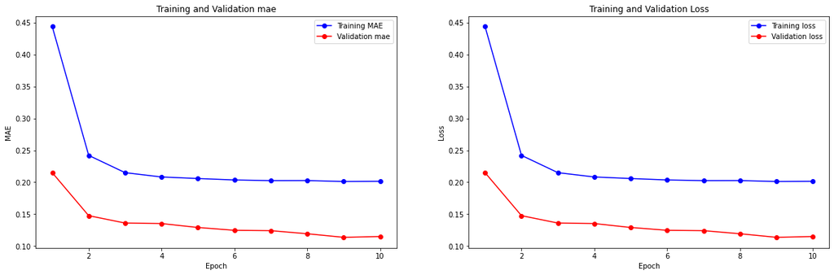

```
3852/3852 ━━━━━━━━━━━━━━━━━━━━ 1s 255us/step - loss: 0.2055 - mae: 0.2055
963/963 ━━━━━━━━━━━━━━━━━━━━ 1s 264us/step - loss: 0.1194 - mae: 0.1194
990/990 ━━━━━━━━━━━━━━━━━━━━ 1s 508us/step - loss: 0.1089 - mae: 0.1089
```

```
Training MAE: 113769.36243893729
```

```
Validation MAE: 65806.3718117608
```

```python
plot(history)
train_MAE = model.evaluate(trainData)[-1] * stdSales
val_MAE = model.evaluate(valData)[-1] * stdSales
test_MAE = model.evaluate(testData)[-1] * stdSales
print(f"Training MAE: {train_MAE}")
print(f"Validation MAE: {val_MAE}")

save_model_results(val_results_path, model_name, val_MAE)
save_model_results(test_results_path, model_name, test_MAE)
```

### **Results discussion**

Given the results, the model seems to be **too simple** for this problem. So we'll build more complex models trying to obtain better performance

## **Medium complex RNN**

Let's see if we can improve the results, increasing the complexity of the network

### Building the model

```python
model_name = "mid_complex_SimpleRNN_10_10"
```

```python
inputs = Input(shape=(seqLength, nFeatures))

x = SimpleRNN(units=10, activation='relu', return_sequences=True)(inputs)
x = SimpleRNN(units=10, activation='relu')(inputs)
outputs = Dense(1)(x)

model = Model(inputs=inputs, outputs=outputs)
model.compile(optimizer='adam', loss='mean_absolute_error', metrics=['mae'])
model.summary()
```

```
Model: "functional_3"
```

```
┏━━━━━━━━━━━━━━━━━━━━━━━━━━━━━━━━━┳━━━━━━━━━━━━━━━━━━━━━━━━━━━┳━━━━━━━━━━━━┓
┃ Layer (type)                    ┃ Output Shape              ┃    Param # ┃
┡━━━━━━━━━━━━━━━━━━━━━━━━━━━━━━━━━╇━━━━━━━━━━━━━━━━━━━━━━━━━━━╇━━━━━━━━━━━━┩
│ input_layer_1 (InputLayer)      │ (None, 3, 6)              │          0 │
├─────────────────────────────────┼───────────────────────────┼────────────┤
│ simple_rnn_2 (SimpleRNN)        │ (None, 10)                │        170 │
├─────────────────────────────────┼───────────────────────────┼────────────┤
│ dense_1 (Dense)                 │ (None, 1)                 │         11 │
└─────────────────────────────────┴───────────────────────────┴────────────┘
```

```
 Total params: 181 (724.00 B)
```

```
 Trainable params: 181 (724.00 B)
```

```
 Non-trainable params: 0 (0.00 B)
```

### Training

```python
# Initialize the EarlyStopping callback
early_stopping = EarlyStopping(
    monitor='val_loss',
    patience=40,
    restore_best_weights=True
)

# Train the model with the EarlyStopping callback
history = model.fit(
    trainData,
    epochs=200,
    batch_size=batchSize,
    validation_data=valData,
    callbacks=[early_stopping]  # Add the EarlyStopping callback to the callbacks list
)
```

```
3852/3852 ━━━━━━━━━━━━━━━━━━━━ 3s 598us/step - loss: 0.4077 - mae: 0.4077 - val_loss: 0.1794 - val_mae: 0.1794
3852/3852 ━━━━━━━━━━━━━━━━━━━━ 3s 584us/step - loss: 0.2332 - mae: 0.2332 - val_loss: 0.1554 - val_mae: 0.1554
3852/3852 ━━━━━━━━━━━━━━━━━━━━ 3s 579us/step - loss: 0.2126 - mae: 0.2126 - val_loss: 0.1414 - val_mae: 0.1414
3852/3852 ━━━━━━━━━━━━━━━━━━━━ 3s 575us/step - loss: 0.2063 - mae: 0.2063 - val_loss: 0.1335 - val_mae: 0.1335
3852/3852 ━━━━━━━━━━━━━━━━━━━━ 3s 595us/step - loss: 0.2162 - mae: 0.2162 - val_loss: 0.1389 - val_mae: 0.1389
3852/3852 ━━━━━━━━━━━━━━━━━━━━ 3s 566us/step - loss: 0.2031 - mae: 0.2031 - val_loss: 0.1251 - val_mae: 0.1251
3852/3852 ━━━━━━━━━━━━━━━━━━━━ 3s 564us/step - loss: 0.2030 - mae: 0.2030 - val_loss: 0.1270 - val_mae: 0.1270
3852/3852 ━━━━━━━━━━━━━━━━━━━━ 3s 573us/step - loss: 0.1963 - mae: 0.1963 - val_loss: 0.1289 - val_mae: 0.1289
3852/3852 ━━━━━━━━━━━━━━━━━━━━ 3s 587us/step - loss: 0.1907 - mae: 0.1907 - val_loss: 0.1293 - val_mae: 0.1293
3852/3852 ━━━━━━━━━━━━━━━━━━━━ 3s 569us/step - loss: 0.1891 - mae: 0.1891 - val_loss: 0.1224 - val_mae: 0.1224
3852/3852 ━━━━━━━━━━━━━━━━━━━━ 3s 570us/step - loss: 0.1933 - mae: 0.1933 - val_loss: 0.1346 - val_mae: 0.1346
3852/3852 ━━━━━━━━━━━━━━━━━━━━ 3s 572us/step - loss: 0.1873 - mae: 0.1873 - val_loss: 0.1205 - val_mae: 0.1205
3852/3852 ━━━━━━━━━━━━━━━━━━━━ 3s 578us/step - loss: 0.1889 - mae: 0.1889 - val_loss: 0.1187 - val_mae: 0.1187
3852/3852 ━━━━━━━━━━━━━━━━━━━━ 3s 580us/step - loss: 0.1838 - mae: 0.1838 - val_loss: 0.1285 - val_mae: 0.1285
3852/3852 ━━━━━━━━━━━━━━━━━━━━ 3s 614us/step - loss: 0.1776 - mae: 0.1776 - val_loss: 0.1187 - val_mae: 0.1187
3852/3852 ━━━━━━━━━━━━━━━━━━━━ 3s 627us/step - loss: 0.1792 - mae: 0.1792 - val_loss: 0.1171 - val_mae: 0.1171
3852/3852 ━━━━━━━━━━━━━━━━━━━━ 3s 600us/step - loss: 0.1818 - mae: 0.1818 - val_loss: 0.1151 - val_mae: 0.1151
3852/3852 ━━━━━━━━━━━━━━━━━━━━ 3s 618us/step - loss: 0.1712 - mae: 0.1712 - val_loss: 0.1142 - val_mae: 0.1142
3852/3852 ━━━━━━━━━━━━━━━━━━━━ 3s 612us/step - loss: 0.1701 - mae: 0.1701 - val_loss: 0.1067 - val_mae: 0.1067
3852/3852 ━━━━━━━━━━━━━━━━━━━━ 3s 606us/step - loss: 0.1659 - mae: 0.1659 - val_loss: 0.1033 - val_mae: 0.1033
3852/3852 ━━━━━━━━━━━━━━━━━━━━ 3s 611us/step - loss: 0.1639 - mae: 0.1639 - val_loss: 0.1113 - val_mae: 0.1113
3852/3852 ━━━━━━━━━━━━━━━━━━━━ 3s 615us/step - loss: 0.1607 - mae: 0.1607 - val_loss: 0.1148 - val_mae: 0.1148
3852/3852 ━━━━━━━━━━━━━━━━━━━━ 3s 610us/step - loss: 0.1654 - mae: 0.1654 - val_loss: 0.1030 - val_mae: 0.1030
3852/3852 ━━━━━━━━━━━━━━━━━━━━ 3s 594us/step - loss: 0.1570 - mae: 0.1570 - val_loss: 0.1118 - val_mae: 0.1118
3852/3852 ━━━━━━━━━━━━━━━━━━━━ 3s 628us/step - loss: 0.1591 - mae: 0.1591 - val_loss: 0.1058 - val_mae: 0.1058
3852/3852 ━━━━━━━━━━━━━━━━━━━━ 3s 611us/step - loss: 0.1608 - mae: 0.1608 - val_loss: 0.1092 - val_mae: 0.1092
3852/3852 ━━━━━━━━━━━━━━━━━━━━ 3s 604us/step - loss: 0.1626 - mae: 0.1626 - val_loss: 0.1093 - val_mae: 0.1093
3852/3852 ━━━━━━━━━━━━━━━━━━━━ 3s 631us/step - loss: 0.1650 - mae: 0.1650 - val_loss: 0.1113 - val_mae: 0.1113
3852/3852 ━━━━━━━━━━━━━━━━━━━━ 3s 611us/step - loss: 0.1575 - mae: 0.1575 - val_loss: 0.1098 - val_mae: 0.1098
3852/3852 ━━━━━━━━━━━━━━━━━━━━ 3s 627us/step - loss: 0.1607 - mae: 0.1607 - val_loss: 0.1106 - val_mae: 0.1106
3852/3852 ━━━━━━━━━━━━━━━━━━━━ 3s 623us/step - loss: 0.1610 - mae: 0.1610 - val_loss: 0.1047 - val_mae: 0.1047
3852/3852 ━━━━━━━━━━━━━━━━━━━━ 3s 607us/step - loss: 0.1529 - mae: 0.1529 - val_loss: 0.1086 - val_mae: 0.1086
3852/3852 ━━━━━━━━━━━━━━━━━━━━ 3s 625us/step - loss: 0.1527 - mae: 0.1527 - val_loss: 0.1026 - val_mae: 0.1026
3852/3852 ━━━━━━━━━━━━━━━━━━━━ 3s 614us/step - loss: 0.1570 - mae: 0.1570 - val_loss: 0.1021 - val_mae: 0.1021
3852/3852 ━━━━━━━━━━━━━━━━━━━━ 3s 604us/step - loss: 0.1598 - mae: 0.1598 - val_loss: 0.1024 - val_mae: 0.1024
3852/3852 ━━━━━━━━━━━━━━━━━━━━ 3s 572us/step - loss: 0.1531 - mae: 0.1531 - val_loss: 0.1045 - val_mae: 0.1045
3852/3852 ━━━━━━━━━━━━━━━━━━━━ 3s 595us/step - loss: 0.1562 - mae: 0.1562 - val_loss: 0.1039 - val_mae: 0.1039
3852/3852 ━━━━━━━━━━━━━━━━━━━━ 3s 621us/step - loss: 0.1528 - mae: 0.1528 - val_loss: 0.1057 - val_mae: 0.1057
3852/3852 ━━━━━━━━━━━━━━━━━━━━ 3s 608us/step - loss: 0.1516 - mae: 0.1516 - val_loss: 0.1039 - val_mae: 0.1039
3852/3852 ━━━━━━━━━━━━━━━━━━━━ 3s 637us/step - loss: 0.1504 - mae: 0.1504 - val_loss: 0.1039 - val_mae: 0.1039
```

[output cut: 35 more lines]

```
3852/3852 ━━━━━━━━━━━━━━━━━━━━ 3s 578us/step - loss: 0.1531 - mae: 0.1531 - val_loss: 0.1099 - val_mae: 0.1099
3852/3852 ━━━━━━━━━━━━━━━━━━━━ 3s 596us/step - loss: 0.1475 - mae: 0.1475 - val_loss: 0.1044 - val_mae: 0.1044
3852/3852 ━━━━━━━━━━━━━━━━━━━━ 3s 577us/step - loss: 0.1492 - mae: 0.1492 - val_loss: 0.1141 - val_mae: 0.1141
3852/3852 ━━━━━━━━━━━━━━━━━━━━ 3s 603us/step - loss: 0.1525 - mae: 0.1525 - val_loss: 0.1042 - val_mae: 0.1042
3852/3852 ━━━━━━━━━━━━━━━━━━━━ 3s 594us/step - loss: 0.1544 - mae: 0.1544 - val_loss: 0.1139 - val_mae: 0.1139
3852/3852 ━━━━━━━━━━━━━━━━━━━━ 3s 604us/step - loss: 0.1543 - mae: 0.1543 - val_loss: 0.1088 - val_mae: 0.1088
3852/3852 ━━━━━━━━━━━━━━━━━━━━ 3s 593us/step - loss: 0.1488 - mae: 0.1488 - val_loss: 0.1152 - val_mae: 0.1152
3852/3852 ━━━━━━━━━━━━━━━━━━━━ 3s 590us/step - loss: 0.1467 - mae: 0.1467 - val_loss: 0.1102 - val_mae: 0.1102
3852/3852 ━━━━━━━━━━━━━━━━━━━━ 3s 600us/step - loss: 0.1495 - mae: 0.1495 - val_loss: 0.1125 - val_mae: 0.1125
3852/3852 ━━━━━━━━━━━━━━━━━━━━ 3s 614us/step - loss: 0.1498 - mae: 0.1498 - val_loss: 0.1224 - val_mae: 0.1224
3852/3852 ━━━━━━━━━━━━━━━━━━━━ 3s 589us/step - loss: 0.1577 - mae: 0.1577 - val_loss: 0.1105 - val_mae: 0.1105
3852/3852 ━━━━━━━━━━━━━━━━━━━━ 3s 610us/step - loss: 0.1524 - mae: 0.1524 - val_loss: 0.1051 - val_mae: 0.1051
3852/3852 ━━━━━━━━━━━━━━━━━━━━ 3s 605us/step - loss: 0.1510 - mae: 0.1510 - val_loss: 0.1077 - val_mae: 0.1077
3852/3852 ━━━━━━━━━━━━━━━━━━━━ 3s 583us/step - loss: 0.1519 - mae: 0.1519 - val_loss: 0.1117 - val_mae: 0.1117
3852/3852 ━━━━━━━━━━━━━━━━━━━━ 3s 632us/step - loss: 0.1526 - mae: 0.1526 - val_loss: 0.1064 - val_mae: 0.1064
```

### Evaluation

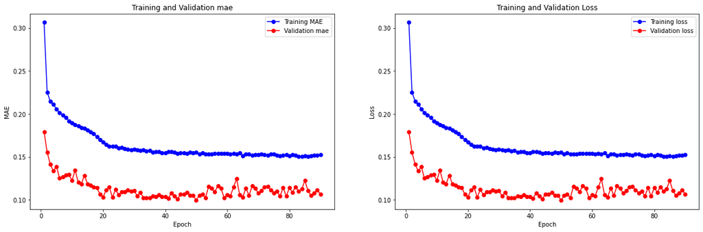

```
3852/3852 ━━━━━━━━━━━━━━━━━━━━ 1s 249us/step - loss: 0.1539 - mae: 0.1539
963/963 ━━━━━━━━━━━━━━━━━━━━ 1s 269us/step - loss: 0.0982 - mae: 0.0982
990/990 ━━━━━━━━━━━━━━━━━━━━ 1s 530us/step - loss: 0.1259 - mae: 0.1259
```

```
Training MAE: 88777.53916036464
```

```
Validation MAE: 56940.01854333832
```

```python
plot(history)
train_MAE = model.evaluate(trainData)[-1] * stdSales
val_MAE = model.evaluate(valData)[-1] * stdSales
test_MAE = model.evaluate(testData)[-1] * stdSales
print(f"Training MAE: {train_MAE}")
print(f"Validation MAE: {val_MAE}")

save_model_results(val_results_path, model_name, val_MAE)
save_model_results(test_results_path, model_name, test_MAE)
```

### **Results discussion**

Given the results, we can observe that this model yielded significantly **better** than the previous one, taking advantage of the added complexity. However, the training did not converge, remaining above the validation curve, and this, considering we are **not** applying regularization yet, may be a symptom that our model would probably **benefit more complexity**.

## **More complex and Longer training**

In this model, we are going to increase the complexity and the number of epoch, trying to find out if it's complex enough to overfit the data.

### Building Model

```python
model_name = "complex_SimpleRNN"
```

```python
inputs = Input(shape=(seqLength, nFeatures))

x = SimpleRNN(units=32, activation='relu', return_sequences=True)(inputs)
x = SimpleRNN(units=64, activation='relu', return_sequences=True)(inputs)
x = SimpleRNN(units=128, activation='relu', return_sequences=True)(inputs)
x = SimpleRNN(units=64, activation='relu')(inputs)
outputs = Dense(1)(x)

model = Model(inputs=inputs, outputs=outputs)
model.compile(optimizer='adam', loss='mean_absolute_error', metrics=['mae'])
model.summary()
```

```
Model: "functional_5"
```

```
┏━━━━━━━━━━━━━━━━━━━━━━━━━━━━━━━━━┳━━━━━━━━━━━━━━━━━━━━━━━━━━━┳━━━━━━━━━━━━┓
┃ Layer (type)                    ┃ Output Shape              ┃    Param # ┃
┡━━━━━━━━━━━━━━━━━━━━━━━━━━━━━━━━━╇━━━━━━━━━━━━━━━━━━━━━━━━━━━╇━━━━━━━━━━━━┩
│ input_layer_2 (InputLayer)      │ (None, 3, 6)              │          0 │
├─────────────────────────────────┼───────────────────────────┼────────────┤
│ simple_rnn_6 (SimpleRNN)        │ (None, 64)                │      4,544 │
├─────────────────────────────────┼───────────────────────────┼────────────┤
│ dense_2 (Dense)                 │ (None, 1)                 │         65 │
└─────────────────────────────────┴───────────────────────────┴────────────┘
```

```
 Total params: 4,609 (18.00 KB)
```

```
 Trainable params: 4,609 (18.00 KB)
```

```
 Non-trainable params: 0 (0.00 B)
```

### Training

```python
# Initialize the EarlyStopping callback
early_stopping = EarlyStopping(
    monitor='val_loss',
    patience=60,
    restore_best_weights=True
)

# Train the model with the EarlyStopping callback
history = model.fit(
    trainData,
    epochs=500,
    batch_size=batchSize,
    validation_data=valData,
    callbacks=[early_stopping]  # Add the EarlyStopping callback to the callbacks list
)
```

```
3852/3852 ━━━━━━━━━━━━━━━━━━━━ 3s 627us/step - loss: 0.2980 - mae: 0.2980 - val_loss: 0.1415 - val_mae: 0.1415
3852/3852 ━━━━━━━━━━━━━━━━━━━━ 3s 657us/step - loss: 0.2057 - mae: 0.2057 - val_loss: 0.1354 - val_mae: 0.1354
3852/3852 ━━━━━━━━━━━━━━━━━━━━ 3s 606us/step - loss: 0.1873 - mae: 0.1873 - val_loss: 0.1367 - val_mae: 0.1367
3852/3852 ━━━━━━━━━━━━━━━━━━━━ 3s 628us/step - loss: 0.1825 - mae: 0.1825 - val_loss: 0.1058 - val_mae: 0.1058
3852/3852 ━━━━━━━━━━━━━━━━━━━━ 3s 645us/step - loss: 0.1681 - mae: 0.1681 - val_loss: 0.1180 - val_mae: 0.1180
3852/3852 ━━━━━━━━━━━━━━━━━━━━ 3s 615us/step - loss: 0.1694 - mae: 0.1694 - val_loss: 0.1028 - val_mae: 0.1028
3852/3852 ━━━━━━━━━━━━━━━━━━━━ 3s 611us/step - loss: 0.1556 - mae: 0.1556 - val_loss: 0.1209 - val_mae: 0.1209
3852/3852 ━━━━━━━━━━━━━━━━━━━━ 3s 652us/step - loss: 0.1581 - mae: 0.1581 - val_loss: 0.1150 - val_mae: 0.1150
3852/3852 ━━━━━━━━━━━━━━━━━━━━ 3s 606us/step - loss: 0.1567 - mae: 0.1567 - val_loss: 0.1077 - val_mae: 0.1077
3852/3852 ━━━━━━━━━━━━━━━━━━━━ 3s 615us/step - loss: 0.1505 - mae: 0.1505 - val_loss: 0.1118 - val_mae: 0.1118
3852/3852 ━━━━━━━━━━━━━━━━━━━━ 3s 617us/step - loss: 0.1518 - mae: 0.1518 - val_loss: 0.1077 - val_mae: 0.1077
3852/3852 ━━━━━━━━━━━━━━━━━━━━ 3s 637us/step - loss: 0.1546 - mae: 0.1546 - val_loss: 0.1067 - val_mae: 0.1067
3852/3852 ━━━━━━━━━━━━━━━━━━━━ 3s 630us/step - loss: 0.1490 - mae: 0.1490 - val_loss: 0.1084 - val_mae: 0.1084
3852/3852 ━━━━━━━━━━━━━━━━━━━━ 3s 598us/step - loss: 0.1457 - mae: 0.1457 - val_loss: 0.1105 - val_mae: 0.1105
3852/3852 ━━━━━━━━━━━━━━━━━━━━ 3s 636us/step - loss: 0.1465 - mae: 0.1465 - val_loss: 0.1129 - val_mae: 0.1129
3852/3852 ━━━━━━━━━━━━━━━━━━━━ 3s 618us/step - loss: 0.1428 - mae: 0.1428 - val_loss: 0.1173 - val_mae: 0.1173
3852/3852 ━━━━━━━━━━━━━━━━━━━━ 3s 610us/step - loss: 0.1452 - mae: 0.1452 - val_loss: 0.1020 - val_mae: 0.1020
3852/3852 ━━━━━━━━━━━━━━━━━━━━ 3s 627us/step - loss: 0.1445 - mae: 0.1445 - val_loss: 0.1047 - val_mae: 0.1047
3852/3852 ━━━━━━━━━━━━━━━━━━━━ 3s 637us/step - loss: 0.1450 - mae: 0.1450 - val_loss: 0.1047 - val_mae: 0.1047
3852/3852 ━━━━━━━━━━━━━━━━━━━━ 3s 637us/step - loss: 0.1461 - mae: 0.1461 - val_loss: 0.0997 - val_mae: 0.0997
3852/3852 ━━━━━━━━━━━━━━━━━━━━ 3s 607us/step - loss: 0.1415 - mae: 0.1415 - val_loss: 0.1030 - val_mae: 0.1030
3852/3852 ━━━━━━━━━━━━━━━━━━━━ 3s 643us/step - loss: 0.1381 - mae: 0.1381 - val_loss: 0.1048 - val_mae: 0.1048
3852/3852 ━━━━━━━━━━━━━━━━━━━━ 3s 637us/step - loss: 0.1395 - mae: 0.1395 - val_loss: 0.0985 - val_mae: 0.0985
3852/3852 ━━━━━━━━━━━━━━━━━━━━ 3s 606us/step - loss: 0.1370 - mae: 0.1370 - val_loss: 0.0981 - val_mae: 0.0981
3852/3852 ━━━━━━━━━━━━━━━━━━━━ 3s 628us/step - loss: 0.1413 - mae: 0.1413 - val_loss: 0.1054 - val_mae: 0.1054
3852/3852 ━━━━━━━━━━━━━━━━━━━━ 3s 661us/step - loss: 0.1355 - mae: 0.1355 - val_loss: 0.0984 - val_mae: 0.0984
3852/3852 ━━━━━━━━━━━━━━━━━━━━ 3s 662us/step - loss: 0.1390 - mae: 0.1390 - val_loss: 0.1079 - val_mae: 0.1079
3852/3852 ━━━━━━━━━━━━━━━━━━━━ 3s 658us/step - loss: 0.1349 - mae: 0.1349 - val_loss: 0.1177 - val_mae: 0.1177
3852/3852 ━━━━━━━━━━━━━━━━━━━━ 3s 649us/step - loss: 0.1379 - mae: 0.1379 - val_loss: 0.1112 - val_mae: 0.1112
3852/3852 ━━━━━━━━━━━━━━━━━━━━ 3s 657us/step - loss: 0.1319 - mae: 0.1319 - val_loss: 0.1059 - val_mae: 0.1059
3852/3852 ━━━━━━━━━━━━━━━━━━━━ 3s 638us/step - loss: 0.1391 - mae: 0.1391 - val_loss: 0.0947 - val_mae: 0.0947
3852/3852 ━━━━━━━━━━━━━━━━━━━━ 3s 658us/step - loss: 0.1325 - mae: 0.1325 - val_loss: 0.1240 - val_mae: 0.1240
3852/3852 ━━━━━━━━━━━━━━━━━━━━ 3s 653us/step - loss: 0.1355 - mae: 0.1355 - val_loss: 0.0994 - val_mae: 0.0994
3852/3852 ━━━━━━━━━━━━━━━━━━━━ 3s 694us/step - loss: 0.1350 - mae: 0.1350 - val_loss: 0.1083 - val_mae: 0.1083
3852/3852 ━━━━━━━━━━━━━━━━━━━━ 3s 666us/step - loss: 0.1291 - mae: 0.1291 - val_loss: 0.1083 - val_mae: 0.1083
3852/3852 ━━━━━━━━━━━━━━━━━━━━ 3s 628us/step - loss: 0.1325 - mae: 0.1325 - val_loss: 0.1102 - val_mae: 0.1102
3852/3852 ━━━━━━━━━━━━━━━━━━━━ 3s 676us/step - loss: 0.1332 - mae: 0.1332 - val_loss: 0.1144 - val_mae: 0.1144
3852/3852 ━━━━━━━━━━━━━━━━━━━━ 3s 666us/step - loss: 0.1296 - mae: 0.1296 - val_loss: 0.1128 - val_mae: 0.1128
3852/3852 ━━━━━━━━━━━━━━━━━━━━ 3s 666us/step - loss: 0.1346 - mae: 0.1346 - val_loss: 0.1010 - val_mae: 0.1010
3852/3852 ━━━━━━━━━━━━━━━━━━━━ 3s 604us/step - loss: 0.1374 - mae: 0.1374 - val_loss: 0.0955 - val_mae: 0.0955
```

[output cut: 36 more lines]

```
3852/3852 ━━━━━━━━━━━━━━━━━━━━ 3s 648us/step - loss: 0.1234 - mae: 0.1234 - val_loss: 0.1042 - val_mae: 0.1042
3852/3852 ━━━━━━━━━━━━━━━━━━━━ 3s 641us/step - loss: 0.1246 - mae: 0.1246 - val_loss: 0.1093 - val_mae: 0.1093
3852/3852 ━━━━━━━━━━━━━━━━━━━━ 3s 658us/step - loss: 0.1238 - mae: 0.1238 - val_loss: 0.1070 - val_mae: 0.1070
3852/3852 ━━━━━━━━━━━━━━━━━━━━ 3s 638us/step - loss: 0.1172 - mae: 0.1172 - val_loss: 0.1005 - val_mae: 0.1005
3852/3852 ━━━━━━━━━━━━━━━━━━━━ 3s 658us/step - loss: 0.1200 - mae: 0.1200 - val_loss: 0.1037 - val_mae: 0.1037
3852/3852 ━━━━━━━━━━━━━━━━━━━━ 3s 659us/step - loss: 0.1216 - mae: 0.1216 - val_loss: 0.1093 - val_mae: 0.1093
3852/3852 ━━━━━━━━━━━━━━━━━━━━ 3s 626us/step - loss: 0.1189 - mae: 0.1189 - val_loss: 0.1045 - val_mae: 0.1045
3852/3852 ━━━━━━━━━━━━━━━━━━━━ 3s 659us/step - loss: 0.1204 - mae: 0.1204 - val_loss: 0.1060 - val_mae: 0.1060
3852/3852 ━━━━━━━━━━━━━━━━━━━━ 3s 659us/step - loss: 0.1127 - mae: 0.1127 - val_loss: 0.1296 - val_mae: 0.1296
3852/3852 ━━━━━━━━━━━━━━━━━━━━ 3s 650us/step - loss: 0.1167 - mae: 0.1167 - val_loss: 0.1217 - val_mae: 0.1217
3852/3852 ━━━━━━━━━━━━━━━━━━━━ 3s 652us/step - loss: 0.1184 - mae: 0.1184 - val_loss: 0.1100 - val_mae: 0.1100
3852/3852 ━━━━━━━━━━━━━━━━━━━━ 3s 635us/step - loss: 0.1210 - mae: 0.1210 - val_loss: 0.1054 - val_mae: 0.1054
3852/3852 ━━━━━━━━━━━━━━━━━━━━ 3s 630us/step - loss: 0.1235 - mae: 0.1235 - val_loss: 0.1078 - val_mae: 0.1078
3852/3852 ━━━━━━━━━━━━━━━━━━━━ 3s 627us/step - loss: 0.1182 - mae: 0.1182 - val_loss: 0.1077 - val_mae: 0.1077
3852/3852 ━━━━━━━━━━━━━━━━━━━━ 3s 682us/step - loss: 0.1187 - mae: 0.1187 - val_loss: 0.1325 - val_mae: 0.1325
```

### Evaluation

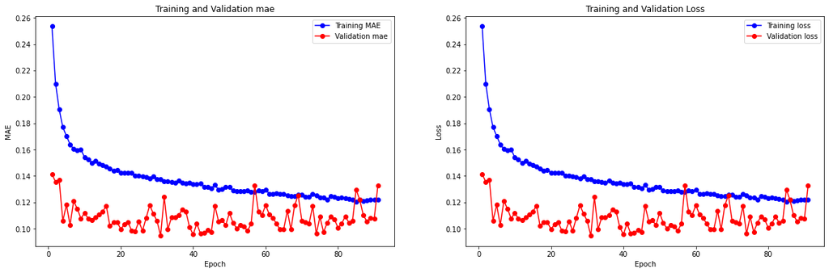

```
3852/3852 ━━━━━━━━━━━━━━━━━━━━ 1s 272us/step - loss: 0.1232 - mae: 0.1232
963/963 ━━━━━━━━━━━━━━━━━━━━ 1s 279us/step - loss: 0.0943 - mae: 0.0943
990/990 ━━━━━━━━━━━━━━━━━━━━ 0s 464us/step - loss: 0.1025 - mae: 0.1025
```

```
Training MAE: 70446.91854837896
```

```
Validation MAE: 54133.92880477081
```

```python
plot(history)
train_MAE = model.evaluate(trainData)[-1] * stdSales
val_MAE = model.evaluate(valData)[-1] * stdSales
test_MAE = model.evaluate(testData)[-1] * stdSales
print(f"Training MAE: {train_MAE}")
print(f"Validation MAE: {val_MAE}")

save_model_results(val_results_path, model_name, val_MAE)
save_model_results(test_results_path, model_name, test_MAE)
```

### **Results discussion**

As we can see here, now we have obtained a much better value for **training**, although the validation curve does not seem to improve a lot. From here, we're going to apply different **regularization** techniques, trying to avoid this **overfitting** and improve the validation results.

## **Regularization to avoid overfitting**

## Dropout

### Building model

```python
model_name = "complex_SimpleRNN_dropOut"
```

```python
inputs = Input(shape=(seqLength, nFeatures))

x = SimpleRNN(units=32, activation='relu', return_sequences=True,
              dropout=0.1, recurrent_dropout=0.1)(inputs)

x = SimpleRNN(units=64, activation='relu', return_sequences=True,
              dropout=0.1, recurrent_dropout=0.1)(x)

x = SimpleRNN(units=128, activation='relu', return_sequences=True,
             dropout=0.1, recurrent_dropout=0.1)(x)

x = SimpleRNN(units=64, activation='relu', dropout=0.1, recurrent_dropout=0.1)(x)

outputs = Dense(1)(x)

model = Model(inputs=inputs, outputs=outputs)
model.compile(optimizer='adam', loss='mean_absolute_error', metrics=['mae'])
model.summary()
```

```
Model: "functional_7"
```

```
┏━━━━━━━━━━━━━━━━━━━━━━━━━━━━━━━━━┳━━━━━━━━━━━━━━━━━━━━━━━━━━━┳━━━━━━━━━━━━┓
┃ Layer (type)                    ┃ Output Shape              ┃    Param # ┃
┡━━━━━━━━━━━━━━━━━━━━━━━━━━━━━━━━━╇━━━━━━━━━━━━━━━━━━━━━━━━━━━╇━━━━━━━━━━━━┩
│ input_layer_3 (InputLayer)      │ (None, 3, 6)              │          0 │
├─────────────────────────────────┼───────────────────────────┼────────────┤
│ simple_rnn_7 (SimpleRNN)        │ (None, 3, 32)             │      1,248 │
├─────────────────────────────────┼───────────────────────────┼────────────┤
│ simple_rnn_8 (SimpleRNN)        │ (None, 3, 64)             │      6,208 │
├─────────────────────────────────┼───────────────────────────┼────────────┤
│ simple_rnn_9 (SimpleRNN)        │ (None, 3, 128)            │     24,704 │
├─────────────────────────────────┼───────────────────────────┼────────────┤
│ simple_rnn_10 (SimpleRNN)       │ (None, 64)                │     12,352 │
├─────────────────────────────────┼───────────────────────────┼────────────┤
│ dense_3 (Dense)                 │ (None, 1)                 │         65 │
└─────────────────────────────────┴───────────────────────────┴────────────┘
```

```
 Total params: 44,577 (174.13 KB)
```

```
 Trainable params: 44,577 (174.13 KB)
```

```
 Non-trainable params: 0 (0.00 B)
```

### Training

```python
# Initialize the EarlyStopping callback
early_stopping = EarlyStopping(
    monitor='val_loss',
    patience=60,
    restore_best_weights=True
)

# Train the model with the EarlyStopping callback
history = model.fit(
    trainData,
    epochs=500,
    batch_size=batchSize,
    validation_data=valData,
    callbacks=[early_stopping]  # Add the EarlyStopping callback to the callbacks list
)
```

```
3852/3852 ━━━━━━━━━━━━━━━━━━━━ 11s 1ms/step - loss: 0.4807 - mae: 0.4807 - val_loss: 0.2806 - val_mae: 0.2806
3852/3852 ━━━━━━━━━━━━━━━━━━━━ 5s 1ms/step - loss: 0.3450 - mae: 0.3450 - val_loss: 0.1521 - val_mae: 0.1521
3852/3852 ━━━━━━━━━━━━━━━━━━━━ 5s 1ms/step - loss: 0.3359 - mae: 0.3359 - val_loss: 0.2848 - val_mae: 0.2848
3852/3852 ━━━━━━━━━━━━━━━━━━━━ 5s 1ms/step - loss: 0.3177 - mae: 0.3177 - val_loss: 0.1383 - val_mae: 0.1383
3852/3852 ━━━━━━━━━━━━━━━━━━━━ 5s 1ms/step - loss: 0.3042 - mae: 0.3042 - val_loss: 0.1916 - val_mae: 0.1916
3852/3852 ━━━━━━━━━━━━━━━━━━━━ 5s 1ms/step - loss: 0.3054 - mae: 0.3054 - val_loss: 0.1923 - val_mae: 0.1923
3852/3852 ━━━━━━━━━━━━━━━━━━━━ 5s 1ms/step - loss: 0.2953 - mae: 0.2953 - val_loss: 0.1570 - val_mae: 0.1570
3852/3852 ━━━━━━━━━━━━━━━━━━━━ 5s 1ms/step - loss: 0.3081 - mae: 0.3081 - val_loss: 0.2405 - val_mae: 0.2405
3852/3852 ━━━━━━━━━━━━━━━━━━━━ 5s 1ms/step - loss: 0.2933 - mae: 0.2933 - val_loss: 0.1245 - val_mae: 0.1245
3852/3852 ━━━━━━━━━━━━━━━━━━━━ 5s 1ms/step - loss: 0.2904 - mae: 0.2904 - val_loss: 0.1829 - val_mae: 0.1829
3852/3852 ━━━━━━━━━━━━━━━━━━━━ 5s 1ms/step - loss: 0.2864 - mae: 0.2864 - val_loss: 0.1953 - val_mae: 0.1953
3852/3852 ━━━━━━━━━━━━━━━━━━━━ 5s 1ms/step - loss: 0.2920 - mae: 0.2920 - val_loss: 0.2248 - val_mae: 0.2248
3852/3852 ━━━━━━━━━━━━━━━━━━━━ 5s 1ms/step - loss: 0.2777 - mae: 0.2777 - val_loss: 0.2293 - val_mae: 0.2293
3852/3852 ━━━━━━━━━━━━━━━━━━━━ 5s 1ms/step - loss: 0.2851 - mae: 0.2851 - val_loss: 0.1549 - val_mae: 0.1549
3852/3852 ━━━━━━━━━━━━━━━━━━━━ 5s 1ms/step - loss: 0.2858 - mae: 0.2858 - val_loss: 0.2486 - val_mae: 0.2486
3852/3852 ━━━━━━━━━━━━━━━━━━━━ 5s 1ms/step - loss: 0.2648 - mae: 0.2648 - val_loss: 0.1984 - val_mae: 0.1984
3852/3852 ━━━━━━━━━━━━━━━━━━━━ 5s 1ms/step - loss: 0.2729 - mae: 0.2729 - val_loss: 0.1825 - val_mae: 0.1825
3852/3852 ━━━━━━━━━━━━━━━━━━━━ 5s 1ms/step - loss: 0.2559 - mae: 0.2559 - val_loss: 0.2221 - val_mae: 0.2221
3852/3852 ━━━━━━━━━━━━━━━━━━━━ 5s 1ms/step - loss: 0.2720 - mae: 0.2720 - val_loss: 0.2119 - val_mae: 0.2119
3852/3852 ━━━━━━━━━━━━━━━━━━━━ 5s 1ms/step - loss: 0.2739 - mae: 0.2739 - val_loss: 0.2628 - val_mae: 0.2628
3852/3852 ━━━━━━━━━━━━━━━━━━━━ 5s 1ms/step - loss: 0.2756 - mae: 0.2756 - val_loss: 0.2319 - val_mae: 0.2319
3852/3852 ━━━━━━━━━━━━━━━━━━━━ 5s 1ms/step - loss: 0.2491 - mae: 0.2491 - val_loss: 0.2475 - val_mae: 0.2475
3852/3852 ━━━━━━━━━━━━━━━━━━━━ 5s 1ms/step - loss: 0.2591 - mae: 0.2591 - val_loss: 0.2754 - val_mae: 0.2754
3852/3852 ━━━━━━━━━━━━━━━━━━━━ 5s 1ms/step - loss: 0.2599 - mae: 0.2599 - val_loss: 0.2670 - val_mae: 0.2670
3852/3852 ━━━━━━━━━━━━━━━━━━━━ 5s 1ms/step - loss: 0.2622 - mae: 0.2622 - val_loss: 0.1975 - val_mae: 0.1975
3852/3852 ━━━━━━━━━━━━━━━━━━━━ 5s 1ms/step - loss: 0.2628 - mae: 0.2628 - val_loss: 0.2366 - val_mae: 0.2366
3852/3852 ━━━━━━━━━━━━━━━━━━━━ 5s 1ms/step - loss: 0.2495 - mae: 0.2495 - val_loss: 0.2119 - val_mae: 0.2119
3852/3852 ━━━━━━━━━━━━━━━━━━━━ 5s 1ms/step - loss: 0.2447 - mae: 0.2447 - val_loss: 0.2284 - val_mae: 0.2284
3852/3852 ━━━━━━━━━━━━━━━━━━━━ 5s 1ms/step - loss: 0.2638 - mae: 0.2638 - val_loss: 0.2373 - val_mae: 0.2373
3852/3852 ━━━━━━━━━━━━━━━━━━━━ 5s 1ms/step - loss: 0.2522 - mae: 0.2522 - val_loss: 0.2083 - val_mae: 0.2083
3852/3852 ━━━━━━━━━━━━━━━━━━━━ 5s 1ms/step - loss: 0.2539 - mae: 0.2539 - val_loss: 0.2613 - val_mae: 0.2613
3852/3852 ━━━━━━━━━━━━━━━━━━━━ 5s 1ms/step - loss: 0.2417 - mae: 0.2417 - val_loss: 0.2143 - val_mae: 0.2143
3852/3852 ━━━━━━━━━━━━━━━━━━━━ 5s 1ms/step - loss: 0.2657 - mae: 0.2657 - val_loss: 0.2270 - val_mae: 0.2270
3852/3852 ━━━━━━━━━━━━━━━━━━━━ 5s 1ms/step - loss: 0.2723 - mae: 0.2723 - val_loss: 0.2188 - val_mae: 0.2188
3852/3852 ━━━━━━━━━━━━━━━━━━━━ 5s 1ms/step - loss: 0.2689 - mae: 0.2689 - val_loss: 0.2955 - val_mae: 0.2955
3852/3852 ━━━━━━━━━━━━━━━━━━━━ 5s 1ms/step - loss: 0.2530 - mae: 0.2530 - val_loss: 0.1809 - val_mae: 0.1809
3852/3852 ━━━━━━━━━━━━━━━━━━━━ 5s 1ms/step - loss: 0.2571 - mae: 0.2571 - val_loss: 0.2128 - val_mae: 0.2128
3852/3852 ━━━━━━━━━━━━━━━━━━━━ 5s 1ms/step - loss: 0.2471 - mae: 0.2471 - val_loss: 0.2362 - val_mae: 0.2362
3852/3852 ━━━━━━━━━━━━━━━━━━━━ 5s 1ms/step - loss: 0.2503 - mae: 0.2503 - val_loss: 0.2539 - val_mae: 0.2539
3852/3852 ━━━━━━━━━━━━━━━━━━━━ 5s 1ms/step - loss: 0.2554 - mae: 0.2554 - val_loss: 0.2632 - val_mae: 0.2632
```

[output cut: 14 more lines]

```
3852/3852 ━━━━━━━━━━━━━━━━━━━━ 5s 1ms/step - loss: 0.2393 - mae: 0.2393 - val_loss: 0.2395 - val_mae: 0.2395
3852/3852 ━━━━━━━━━━━━━━━━━━━━ 5s 1ms/step - loss: 0.2417 - mae: 0.2417 - val_loss: 0.2484 - val_mae: 0.2484
3852/3852 ━━━━━━━━━━━━━━━━━━━━ 5s 1ms/step - loss: 0.2453 - mae: 0.2453 - val_loss: 0.2641 - val_mae: 0.2641
3852/3852 ━━━━━━━━━━━━━━━━━━━━ 5s 1ms/step - loss: 0.2550 - mae: 0.2550 - val_loss: 0.2169 - val_mae: 0.2169
3852/3852 ━━━━━━━━━━━━━━━━━━━━ 5s 1ms/step - loss: 0.2535 - mae: 0.2535 - val_loss: 0.2396 - val_mae: 0.2396
3852/3852 ━━━━━━━━━━━━━━━━━━━━ 5s 1ms/step - loss: 0.2509 - mae: 0.2509 - val_loss: 0.2842 - val_mae: 0.2842
3852/3852 ━━━━━━━━━━━━━━━━━━━━ 5s 1ms/step - loss: 0.2541 - mae: 0.2541 - val_loss: 0.2820 - val_mae: 0.2820
3852/3852 ━━━━━━━━━━━━━━━━━━━━ 5s 1ms/step - loss: 0.2438 - mae: 0.2438 - val_loss: 0.2962 - val_mae: 0.2962
3852/3852 ━━━━━━━━━━━━━━━━━━━━ 5s 1ms/step - loss: 0.2393 - mae: 0.2393 - val_loss: 0.2553 - val_mae: 0.2553
3852/3852 ━━━━━━━━━━━━━━━━━━━━ 5s 1ms/step - loss: 0.2451 - mae: 0.2451 - val_loss: 0.2845 - val_mae: 0.2845
3852/3852 ━━━━━━━━━━━━━━━━━━━━ 5s 1ms/step - loss: 0.2536 - mae: 0.2536 - val_loss: 0.2228 - val_mae: 0.2228
3852/3852 ━━━━━━━━━━━━━━━━━━━━ 5s 1ms/step - loss: 0.2558 - mae: 0.2558 - val_loss: 0.2452 - val_mae: 0.2452
3852/3852 ━━━━━━━━━━━━━━━━━━━━ 5s 1ms/step - loss: 0.2618 - mae: 0.2618 - val_loss: 0.2508 - val_mae: 0.2508
3852/3852 ━━━━━━━━━━━━━━━━━━━━ 5s 1ms/step - loss: 0.2528 - mae: 0.2528 - val_loss: 0.2375 - val_mae: 0.2375
3852/3852 ━━━━━━━━━━━━━━━━━━━━ 5s 1ms/step - loss: 0.2512 - mae: 0.2512 - val_loss: 0.2135 - val_mae: 0.2135
```

### Evaluation

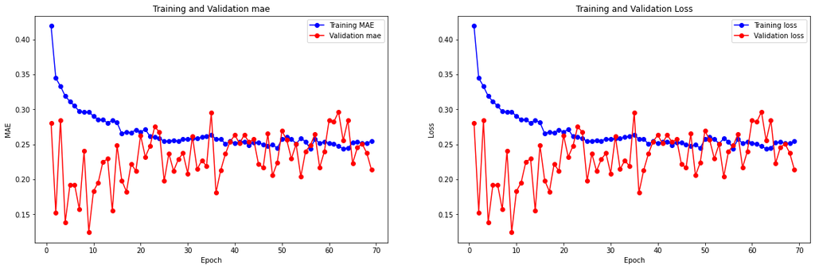

```
3852/3852 ━━━━━━━━━━━━━━━━━━━━ 2s 351us/step - loss: 0.2040 - mae: 0.2040
963/963 ━━━━━━━━━━━━━━━━━━━━ 1s 364us/step - loss: 0.1268 - mae: 0.1268
990/990 ━━━━━━━━━━━━━━━━━━━━ 0s 485us/step - loss: 0.1565 - mae: 0.1565
```

```
Training MAE: 117126.85699584222
```

```
Validation MAE: 71168.81328161054
```

```python
plot(history)
train_MAE = model.evaluate(trainData)[-1] * stdSales
val_MAE = model.evaluate(valData)[-1] * stdSales
test_MAE = model.evaluate(testData)[-1] * stdSales
print(f"Training MAE: {train_MAE}")
print(f"Validation MAE: {val_MAE}")

save_model_results(val_results_path, model_name, val_MAE)
save_model_results(test_results_path, model_name, test_MAE)
```

### **Results discussion**

After testing various **DropOut** regularization configurations, we have come to the conclusion that this method **does not appear to be effective**. The model is extremely sensitive to regularization, and even when using very low drop out probabilities, the model's performance in fitting not only the validation data but also the training data is significantly **limited**, **worsening the outcomes considerably**. Therefore, we are considering the use of other, less intensive regularization methods to see if they offer better performance; in this case, we will test with L2 regularization.

## L2 Regularization

### Building model

```python
model_name = "complex_SimpleRNN_L2"
```

```python
inputs = Input(shape=(seqLength, nFeatures))

x = SimpleRNN(units=32, activation='relu', return_sequences=True,
              kernel_regularizer=l2(0.0001), recurrent_regularizer=l2(0.0001))(inputs)

x = SimpleRNN(units=64, activation='relu', return_sequences=True,
              kernel_regularizer=l2(0.0001), recurrent_regularizer=l2(0.0001))(x)

x = SimpleRNN(units=128, activation='relu', return_sequences=True,
              kernel_regularizer=l2(0.0001), recurrent_regularizer=l2(0.0001))(x)

x = SimpleRNN(units=64, activation='relu', kernel_regularizer=l2(0.0001), recurrent_regularizer=l2(0.0001))(x)

outputs = Dense(1)(x)

model = Model(inputs=inputs, outputs=outputs)
model.compile(optimizer='adam', loss='mean_absolute_error', metrics=['mae'])
model.summary()
```

```
Model: "functional_9"
```

```
┏━━━━━━━━━━━━━━━━━━━━━━━━━━━━━━━━━┳━━━━━━━━━━━━━━━━━━━━━━━━━━━┳━━━━━━━━━━━━┓
┃ Layer (type)                    ┃ Output Shape              ┃    Param # ┃
┡━━━━━━━━━━━━━━━━━━━━━━━━━━━━━━━━━╇━━━━━━━━━━━━━━━━━━━━━━━━━━━╇━━━━━━━━━━━━┩
│ input_layer_4 (InputLayer)      │ (None, 3, 6)              │          0 │
├─────────────────────────────────┼───────────────────────────┼────────────┤
│ simple_rnn_11 (SimpleRNN)       │ (None, 3, 32)             │      1,248 │
├─────────────────────────────────┼───────────────────────────┼────────────┤
│ simple_rnn_12 (SimpleRNN)       │ (None, 3, 64)             │      6,208 │
├─────────────────────────────────┼───────────────────────────┼────────────┤
│ simple_rnn_13 (SimpleRNN)       │ (None, 3, 128)            │     24,704 │
├─────────────────────────────────┼───────────────────────────┼────────────┤
│ simple_rnn_14 (SimpleRNN)       │ (None, 64)                │     12,352 │
├─────────────────────────────────┼───────────────────────────┼────────────┤
│ dense_4 (Dense)                 │ (None, 1)                 │         65 │
└─────────────────────────────────┴───────────────────────────┴────────────┘
```

```
 Total params: 44,577 (174.13 KB)
```

```
 Trainable params: 44,577 (174.13 KB)
```

```
 Non-trainable params: 0 (0.00 B)
```

### Training

```python
# Initialize the EarlyStopping callback
early_stopping = EarlyStopping(
    monitor='val_loss',
    patience=60,
    restore_best_weights=True
)

# Train the model with the EarlyStopping callback
history = model.fit(
    trainData,
    epochs=500,
    batch_size=batchSize,
    validation_data=valData,
    callbacks=[early_stopping]  # Add the EarlyStopping callback to the callbacks list
)
```

```
3852/3852 ━━━━━━━━━━━━━━━━━━━━ 7s 1ms/step - loss: 0.3860 - mae: 0.3432 - val_loss: 0.1714 - val_mae: 0.1402
3852/3852 ━━━━━━━━━━━━━━━━━━━━ 5s 1ms/step - loss: 0.2599 - mae: 0.2324 - val_loss: 0.1579 - val_mae: 0.1397
3852/3852 ━━━━━━━━━━━━━━━━━━━━ 5s 1ms/step - loss: 0.2260 - mae: 0.2095 - val_loss: 0.1268 - val_mae: 0.1140
3852/3852 ━━━━━━━━━━━━━━━━━━━━ 5s 1ms/step - loss: 0.2078 - mae: 0.1954 - val_loss: 0.1361 - val_mae: 0.1250
3852/3852 ━━━━━━━━━━━━━━━━━━━━ 5s 1ms/step - loss: 0.1948 - mae: 0.1839 - val_loss: 0.1439 - val_mae: 0.1337
3852/3852 ━━━━━━━━━━━━━━━━━━━━ 5s 1ms/step - loss: 0.1886 - mae: 0.1786 - val_loss: 0.1309 - val_mae: 0.1214
3852/3852 ━━━━━━━━━━━━━━━━━━━━ 5s 1ms/step - loss: 0.1807 - mae: 0.1713 - val_loss: 0.1294 - val_mae: 0.1201
3852/3852 ━━━━━━━━━━━━━━━━━━━━ 5s 1ms/step - loss: 0.1754 - mae: 0.1663 - val_loss: 0.1228 - val_mae: 0.1140
3852/3852 ━━━━━━━━━━━━━━━━━━━━ 5s 1ms/step - loss: 0.1676 - mae: 0.1588 - val_loss: 0.1100 - val_mae: 0.1014
3852/3852 ━━━━━━━━━━━━━━━━━━━━ 5s 1ms/step - loss: 0.1763 - mae: 0.1678 - val_loss: 0.1196 - val_mae: 0.1109
3852/3852 ━━━━━━━━━━━━━━━━━━━━ 5s 1ms/step - loss: 0.1685 - mae: 0.1599 - val_loss: 0.1037 - val_mae: 0.0951
3852/3852 ━━━━━━━━━━━━━━━━━━━━ 5s 1ms/step - loss: 0.1668 - mae: 0.1582 - val_loss: 0.1162 - val_mae: 0.1075
3852/3852 ━━━━━━━━━━━━━━━━━━━━ 5s 1ms/step - loss: 0.1642 - mae: 0.1556 - val_loss: 0.1185 - val_mae: 0.1098
3852/3852 ━━━━━━━━━━━━━━━━━━━━ 5s 1ms/step - loss: 0.1628 - mae: 0.1541 - val_loss: 0.1137 - val_mae: 0.1051
3852/3852 ━━━━━━━━━━━━━━━━━━━━ 5s 1ms/step - loss: 0.1645 - mae: 0.1557 - val_loss: 0.1483 - val_mae: 0.1396
3852/3852 ━━━━━━━━━━━━━━━━━━━━ 5s 1ms/step - loss: 0.1575 - mae: 0.1488 - val_loss: 0.1117 - val_mae: 0.1029
3852/3852 ━━━━━━━━━━━━━━━━━━━━ 5s 1ms/step - loss: 0.1622 - mae: 0.1533 - val_loss: 0.1133 - val_mae: 0.1044
3852/3852 ━━━━━━━━━━━━━━━━━━━━ 5s 1ms/step - loss: 0.1558 - mae: 0.1469 - val_loss: 0.1153 - val_mae: 0.1064
3852/3852 ━━━━━━━━━━━━━━━━━━━━ 5s 1ms/step - loss: 0.1595 - mae: 0.1506 - val_loss: 0.1135 - val_mae: 0.1046
3852/3852 ━━━━━━━━━━━━━━━━━━━━ 5s 1ms/step - loss: 0.1598 - mae: 0.1508 - val_loss: 0.1080 - val_mae: 0.0991
3852/3852 ━━━━━━━━━━━━━━━━━━━━ 5s 1ms/step - loss: 0.1588 - mae: 0.1498 - val_loss: 0.1396 - val_mae: 0.1306
3852/3852 ━━━━━━━━━━━━━━━━━━━━ 5s 1ms/step - loss: 0.1565 - mae: 0.1476 - val_loss: 0.1191 - val_mae: 0.1101
3852/3852 ━━━━━━━━━━━━━━━━━━━━ 5s 1ms/step - loss: 0.1556 - mae: 0.1466 - val_loss: 0.1226 - val_mae: 0.1136
3852/3852 ━━━━━━━━━━━━━━━━━━━━ 5s 1ms/step - loss: 0.1541 - mae: 0.1451 - val_loss: 0.1154 - val_mae: 0.1063
3852/3852 ━━━━━━━━━━━━━━━━━━━━ 5s 1ms/step - loss: 0.1553 - mae: 0.1462 - val_loss: 0.1171 - val_mae: 0.1078
3852/3852 ━━━━━━━━━━━━━━━━━━━━ 5s 1ms/step - loss: 0.1538 - mae: 0.1446 - val_loss: 0.1225 - val_mae: 0.1131
3852/3852 ━━━━━━━━━━━━━━━━━━━━ 5s 1ms/step - loss: 0.1633 - mae: 0.1539 - val_loss: 0.1165 - val_mae: 0.1071
3852/3852 ━━━━━━━━━━━━━━━━━━━━ 5s 1ms/step - loss: 0.1474 - mae: 0.1380 - val_loss: 0.1108 - val_mae: 0.1014
3852/3852 ━━━━━━━━━━━━━━━━━━━━ 5s 1ms/step - loss: 0.1521 - mae: 0.1427 - val_loss: 0.1371 - val_mae: 0.1278
3852/3852 ━━━━━━━━━━━━━━━━━━━━ 5s 1ms/step - loss: 0.1549 - mae: 0.1455 - val_loss: 0.1098 - val_mae: 0.1003
3852/3852 ━━━━━━━━━━━━━━━━━━━━ 5s 1ms/step - loss: 0.1504 - mae: 0.1409 - val_loss: 0.1101 - val_mae: 0.1005
3852/3852 ━━━━━━━━━━━━━━━━━━━━ 5s 1ms/step - loss: 0.1462 - mae: 0.1366 - val_loss: 0.1246 - val_mae: 0.1150
3852/3852 ━━━━━━━━━━━━━━━━━━━━ 5s 1ms/step - loss: 0.1552 - mae: 0.1456 - val_loss: 0.1133 - val_mae: 0.1036
3852/3852 ━━━━━━━━━━━━━━━━━━━━ 5s 1ms/step - loss: 0.1484 - mae: 0.1386 - val_loss: 0.1077 - val_mae: 0.0980
3852/3852 ━━━━━━━━━━━━━━━━━━━━ 5s 1ms/step - loss: 0.1493 - mae: 0.1395 - val_loss: 0.1190 - val_mae: 0.1092
3852/3852 ━━━━━━━━━━━━━━━━━━━━ 5s 1ms/step - loss: 0.1505 - mae: 0.1406 - val_loss: 0.1173 - val_mae: 0.1074
3852/3852 ━━━━━━━━━━━━━━━━━━━━ 5s 1ms/step - loss: 0.1532 - mae: 0.1434 - val_loss: 0.1207 - val_mae: 0.1109
3852/3852 ━━━━━━━━━━━━━━━━━━━━ 5s 1ms/step - loss: 0.1531 - mae: 0.1432 - val_loss: 0.1127 - val_mae: 0.1027
3852/3852 ━━━━━━━━━━━━━━━━━━━━ 5s 1ms/step - loss: 0.1466 - mae: 0.1366 - val_loss: 0.1226 - val_mae: 0.1124
3852/3852 ━━━━━━━━━━━━━━━━━━━━ 5s 1ms/step - loss: 0.1447 - mae: 0.1346 - val_loss: 0.1136 - val_mae: 0.1035
```

[output cut: 16 more lines]

```
3852/3852 ━━━━━━━━━━━━━━━━━━━━ 5s 1ms/step - loss: 0.1464 - mae: 0.1358 - val_loss: 0.1295 - val_mae: 0.1188
3852/3852 ━━━━━━━━━━━━━━━━━━━━ 5s 1ms/step - loss: 0.1417 - mae: 0.1311 - val_loss: 0.1244 - val_mae: 0.1138
3852/3852 ━━━━━━━━━━━━━━━━━━━━ 5s 1ms/step - loss: 0.1391 - mae: 0.1284 - val_loss: 0.1385 - val_mae: 0.1278
3852/3852 ━━━━━━━━━━━━━━━━━━━━ 5s 1ms/step - loss: 0.1405 - mae: 0.1298 - val_loss: 0.1278 - val_mae: 0.1173
3852/3852 ━━━━━━━━━━━━━━━━━━━━ 5s 1ms/step - loss: 0.1408 - mae: 0.1303 - val_loss: 0.1158 - val_mae: 0.1053
3852/3852 ━━━━━━━━━━━━━━━━━━━━ 5s 1ms/step - loss: 0.1432 - mae: 0.1327 - val_loss: 0.1190 - val_mae: 0.1085
3852/3852 ━━━━━━━━━━━━━━━━━━━━ 5s 1ms/step - loss: 0.1406 - mae: 0.1300 - val_loss: 0.1293 - val_mae: 0.1187
3852/3852 ━━━━━━━━━━━━━━━━━━━━ 5s 1ms/step - loss: 0.1438 - mae: 0.1332 - val_loss: 0.1160 - val_mae: 0.1054
3852/3852 ━━━━━━━━━━━━━━━━━━━━ 5s 1ms/step - loss: 0.1420 - mae: 0.1313 - val_loss: 0.1220 - val_mae: 0.1114
3852/3852 ━━━━━━━━━━━━━━━━━━━━ 5s 1ms/step - loss: 0.1405 - mae: 0.1298 - val_loss: 0.1352 - val_mae: 0.1244
3852/3852 ━━━━━━━━━━━━━━━━━━━━ 5s 1ms/step - loss: 0.1454 - mae: 0.1347 - val_loss: 0.1212 - val_mae: 0.1105
3852/3852 ━━━━━━━━━━━━━━━━━━━━ 5s 1ms/step - loss: 0.1394 - mae: 0.1287 - val_loss: 0.1177 - val_mae: 0.1070
3852/3852 ━━━━━━━━━━━━━━━━━━━━ 5s 1ms/step - loss: 0.1375 - mae: 0.1268 - val_loss: 0.1209 - val_mae: 0.1102
3852/3852 ━━━━━━━━━━━━━━━━━━━━ 5s 1ms/step - loss: 0.1437 - mae: 0.1328 - val_loss: 0.1299 - val_mae: 0.1190
3852/3852 ━━━━━━━━━━━━━━━━━━━━ 5s 1ms/step - loss: 0.1403 - mae: 0.1295 - val_loss: 0.1178 - val_mae: 0.1069
```

### Evaluation

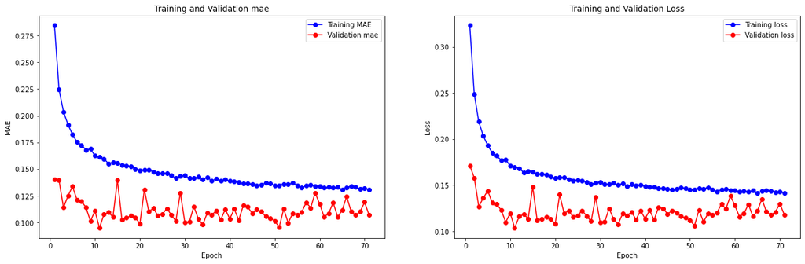

```
3852/3852 ━━━━━━━━━━━━━━━━━━━━ 2s 346us/step - loss: 0.1546 - mae: 0.1459
963/963 ━━━━━━━━━━━━━━━━━━━━ 1s 351us/step - loss: 0.1025 - mae: 0.0938
990/990 ━━━━━━━━━━━━━━━━━━━━ 0s 474us/step - loss: 0.1214 - mae: 0.1127
```

```
Training MAE: 81391.19940579828
```

```
Validation MAE: 54376.900899651955
```

```python
plot(history)
train_MAE = model.evaluate(trainData)[-1] * stdSales
val_MAE = model.evaluate(valData)[-1] * stdSales
test_MAE = model.evaluate(testData)[-1] * stdSales
print(f"Training MAE: {train_MAE}")
print(f"Validation MAE: {val_MAE}")

save_model_results(val_results_path, model_name, val_MAE)
save_model_results(test_results_path, model_name, test_MAE)
```

### **Results discussion**

Once again, we have encountered a model that is very **sensitive** to L2 regularization, resulting in a drastic **deterioration** of the outcomes of various experiments. However, in the case of L2 regularization, it appears that the model could **benefit** from regularization by using very **low L2 regularization** terms. In the next experiment, we will test the use of very light L2 regularization.

## L2 very slight regularization

### Building the Model

```python
model_name = "complex_SimpleRNN_low_L2"
```

```python
inputs = Input(shape=(seqLength, nFeatures))

x = SimpleRNN(units=32, activation='relu', return_sequences=True,
              kernel_regularizer=l2(0.00001), recurrent_regularizer=l2(0.00001))(inputs)

x = SimpleRNN(units=64, activation='relu', return_sequences=True,
              kernel_regularizer=l2(0.00001), recurrent_regularizer=l2(0.00001))(x)

x = SimpleRNN(units=128, activation='relu', return_sequences=True,
              kernel_regularizer=l2(0.00001), recurrent_regularizer=l2(0.00001))(x)

x = SimpleRNN(units=64, activation='relu', kernel_regularizer=l2(0.00001), recurrent_regularizer=l2(0.00001))(x)

outputs = Dense(1)(x)

model = Model(inputs=inputs, outputs=outputs)
model.compile(optimizer='adam', loss='mean_absolute_error', metrics=['mae'])
model.summary()
```

```
Model: "functional_11"
```

```
┏━━━━━━━━━━━━━━━━━━━━━━━━━━━━━━━━━┳━━━━━━━━━━━━━━━━━━━━━━━━━━━┳━━━━━━━━━━━━┓
┃ Layer (type)                    ┃ Output Shape              ┃    Param # ┃
┡━━━━━━━━━━━━━━━━━━━━━━━━━━━━━━━━━╇━━━━━━━━━━━━━━━━━━━━━━━━━━━╇━━━━━━━━━━━━┩
│ input_layer_5 (InputLayer)      │ (None, 3, 6)              │          0 │
├─────────────────────────────────┼───────────────────────────┼────────────┤
│ simple_rnn_15 (SimpleRNN)       │ (None, 3, 32)             │      1,248 │
├─────────────────────────────────┼───────────────────────────┼────────────┤
│ simple_rnn_16 (SimpleRNN)       │ (None, 3, 64)             │      6,208 │
├─────────────────────────────────┼───────────────────────────┼────────────┤
│ simple_rnn_17 (SimpleRNN)       │ (None, 3, 128)            │     24,704 │
├─────────────────────────────────┼───────────────────────────┼────────────┤
│ simple_rnn_18 (SimpleRNN)       │ (None, 64)                │     12,352 │
├─────────────────────────────────┼───────────────────────────┼────────────┤
│ dense_5 (Dense)                 │ (None, 1)                 │         65 │
└─────────────────────────────────┴───────────────────────────┴────────────┘
```

```
 Total params: 44,577 (174.13 KB)
```

```
 Trainable params: 44,577 (174.13 KB)
```

```
 Non-trainable params: 0 (0.00 B)
```

### Training

```python
# Initialize the EarlyStopping callback
early_stopping = EarlyStopping(
    monitor='val_loss',
    patience=60,
    restore_best_weights=True
)

# Train the model with the EarlyStopping callback
history = model.fit(
    trainData,
    epochs=500,
    batch_size=batchSize,
    validation_data=valData,
    callbacks=[early_stopping]  # Add the EarlyStopping callback to the callbacks list
)
```

```
3852/3852 ━━━━━━━━━━━━━━━━━━━━ 7s 1ms/step - loss: 0.3674 - mae: 0.3627 - val_loss: 0.1358 - val_mae: 0.1313
3852/3852 ━━━━━━━━━━━━━━━━━━━━ 5s 1ms/step - loss: 0.2449 - mae: 0.2405 - val_loss: 0.1435 - val_mae: 0.1396
3852/3852 ━━━━━━━━━━━━━━━━━━━━ 5s 1ms/step - loss: 0.2283 - mae: 0.2247 - val_loss: 0.1427 - val_mae: 0.1397
3852/3852 ━━━━━━━━━━━━━━━━━━━━ 5s 1ms/step - loss: 0.2003 - mae: 0.1974 - val_loss: 0.1660 - val_mae: 0.1635
3852/3852 ━━━━━━━━━━━━━━━━━━━━ 5s 1ms/step - loss: 0.1905 - mae: 0.1880 - val_loss: 0.1212 - val_mae: 0.1187
3852/3852 ━━━━━━━━━━━━━━━━━━━━ 5s 1ms/step - loss: 0.1850 - mae: 0.1826 - val_loss: 0.1119 - val_mae: 0.1096
3852/3852 ━━━━━━━━━━━━━━━━━━━━ 5s 1ms/step - loss: 0.1777 - mae: 0.1754 - val_loss: 0.1241 - val_mae: 0.1218
3852/3852 ━━━━━━━━━━━━━━━━━━━━ 5s 1ms/step - loss: 0.1699 - mae: 0.1676 - val_loss: 0.1422 - val_mae: 0.1400
3852/3852 ━━━━━━━━━━━━━━━━━━━━ 5s 1ms/step - loss: 0.1659 - mae: 0.1636 - val_loss: 0.1077 - val_mae: 0.1054
3852/3852 ━━━━━━━━━━━━━━━━━━━━ 5s 1ms/step - loss: 0.1675 - mae: 0.1652 - val_loss: 0.1045 - val_mae: 0.1022
3852/3852 ━━━━━━━━━━━━━━━━━━━━ 5s 1ms/step - loss: 0.1628 - mae: 0.1605 - val_loss: 0.1263 - val_mae: 0.1239
3852/3852 ━━━━━━━━━━━━━━━━━━━━ 5s 1ms/step - loss: 0.1608 - mae: 0.1584 - val_loss: 0.1031 - val_mae: 0.1007
3852/3852 ━━━━━━━━━━━━━━━━━━━━ 5s 1ms/step - loss: 0.1610 - mae: 0.1586 - val_loss: 0.1084 - val_mae: 0.1059
3852/3852 ━━━━━━━━━━━━━━━━━━━━ 5s 1ms/step - loss: 0.1565 - mae: 0.1540 - val_loss: 0.1058 - val_mae: 0.1033
3852/3852 ━━━━━━━━━━━━━━━━━━━━ 5s 1ms/step - loss: 0.1466 - mae: 0.1441 - val_loss: 0.1028 - val_mae: 0.1002
3852/3852 ━━━━━━━━━━━━━━━━━━━━ 5s 1ms/step - loss: 0.1498 - mae: 0.1472 - val_loss: 0.1225 - val_mae: 0.1199
3852/3852 ━━━━━━━━━━━━━━━━━━━━ 5s 1ms/step - loss: 0.1531 - mae: 0.1505 - val_loss: 0.1167 - val_mae: 0.1140
3852/3852 ━━━━━━━━━━━━━━━━━━━━ 5s 1ms/step - loss: 0.1508 - mae: 0.1481 - val_loss: 0.1501 - val_mae: 0.1474
3852/3852 ━━━━━━━━━━━━━━━━━━━━ 5s 1ms/step - loss: 0.1442 - mae: 0.1415 - val_loss: 0.1203 - val_mae: 0.1176
3852/3852 ━━━━━━━━━━━━━━━━━━━━ 5s 1ms/step - loss: 0.1473 - mae: 0.1445 - val_loss: 0.1368 - val_mae: 0.1340
3852/3852 ━━━━━━━━━━━━━━━━━━━━ 5s 1ms/step - loss: 0.1531 - mae: 0.1503 - val_loss: 0.1072 - val_mae: 0.1044
3852/3852 ━━━━━━━━━━━━━━━━━━━━ 5s 1ms/step - loss: 0.1419 - mae: 0.1390 - val_loss: 0.1048 - val_mae: 0.1019
3852/3852 ━━━━━━━━━━━━━━━━━━━━ 5s 1ms/step - loss: 0.1455 - mae: 0.1426 - val_loss: 0.0999 - val_mae: 0.0969
3852/3852 ━━━━━━━━━━━━━━━━━━━━ 5s 1ms/step - loss: 0.1485 - mae: 0.1456 - val_loss: 0.0941 - val_mae: 0.0911
3852/3852 ━━━━━━━━━━━━━━━━━━━━ 5s 1ms/step - loss: 0.1432 - mae: 0.1403 - val_loss: 0.1243 - val_mae: 0.1214
3852/3852 ━━━━━━━━━━━━━━━━━━━━ 5s 1ms/step - loss: 0.1370 - mae: 0.1340 - val_loss: 0.1017 - val_mae: 0.0987
3852/3852 ━━━━━━━━━━━━━━━━━━━━ 5s 1ms/step - loss: 0.1410 - mae: 0.1380 - val_loss: 0.1116 - val_mae: 0.1085
3852/3852 ━━━━━━━━━━━━━━━━━━━━ 5s 1ms/step - loss: 0.1351 - mae: 0.1320 - val_loss: 0.1051 - val_mae: 0.1020
3852/3852 ━━━━━━━━━━━━━━━━━━━━ 5s 1ms/step - loss: 0.1436 - mae: 0.1405 - val_loss: 0.1159 - val_mae: 0.1128
3852/3852 ━━━━━━━━━━━━━━━━━━━━ 5s 1ms/step - loss: 0.1377 - mae: 0.1345 - val_loss: 0.1106 - val_mae: 0.1074
3852/3852 ━━━━━━━━━━━━━━━━━━━━ 5s 1ms/step - loss: 0.1398 - mae: 0.1366 - val_loss: 0.1176 - val_mae: 0.1144
3852/3852 ━━━━━━━━━━━━━━━━━━━━ 5s 1ms/step - loss: 0.1363 - mae: 0.1330 - val_loss: 0.1066 - val_mae: 0.1033
3852/3852 ━━━━━━━━━━━━━━━━━━━━ 5s 1ms/step - loss: 0.1360 - mae: 0.1327 - val_loss: 0.1019 - val_mae: 0.0986
3852/3852 ━━━━━━━━━━━━━━━━━━━━ 5s 1ms/step - loss: 0.1369 - mae: 0.1335 - val_loss: 0.1029 - val_mae: 0.0995
3852/3852 ━━━━━━━━━━━━━━━━━━━━ 5s 1ms/step - loss: 0.1373 - mae: 0.1339 - val_loss: 0.1108 - val_mae: 0.1074
3852/3852 ━━━━━━━━━━━━━━━━━━━━ 5s 1ms/step - loss: 0.1365 - mae: 0.1330 - val_loss: 0.1051 - val_mae: 0.1016
3852/3852 ━━━━━━━━━━━━━━━━━━━━ 5s 1ms/step - loss: 0.1341 - mae: 0.1306 - val_loss: 0.1040 - val_mae: 0.1005
3852/3852 ━━━━━━━━━━━━━━━━━━━━ 5s 1ms/step - loss: 0.1336 - mae: 0.1301 - val_loss: 0.0991 - val_mae: 0.0955
3852/3852 ━━━━━━━━━━━━━━━━━━━━ 5s 1ms/step - loss: 0.1350 - mae: 0.1314 - val_loss: 0.1006 - val_mae: 0.0969
3852/3852 ━━━━━━━━━━━━━━━━━━━━ 5s 1ms/step - loss: 0.1315 - mae: 0.1278 - val_loss: 0.1037 - val_mae: 0.1000
```

[output cut: 29 more lines]

```
3852/3852 ━━━━━━━━━━━━━━━━━━━━ 5s 1ms/step - loss: 0.1221 - mae: 0.1174 - val_loss: 0.1021 - val_mae: 0.0974
3852/3852 ━━━━━━━━━━━━━━━━━━━━ 5s 1ms/step - loss: 0.1240 - mae: 0.1193 - val_loss: 0.1070 - val_mae: 0.1022
3852/3852 ━━━━━━━━━━━━━━━━━━━━ 5s 1ms/step - loss: 0.1205 - mae: 0.1157 - val_loss: 0.1097 - val_mae: 0.1050
3852/3852 ━━━━━━━━━━━━━━━━━━━━ 5s 1ms/step - loss: 0.1198 - mae: 0.1151 - val_loss: 0.1052 - val_mae: 0.1004
3852/3852 ━━━━━━━━━━━━━━━━━━━━ 5s 1ms/step - loss: 0.1190 - mae: 0.1142 - val_loss: 0.1036 - val_mae: 0.0988
3852/3852 ━━━━━━━━━━━━━━━━━━━━ 5s 1ms/step - loss: 0.1198 - mae: 0.1150 - val_loss: 0.1058 - val_mae: 0.1009
3852/3852 ━━━━━━━━━━━━━━━━━━━━ 5s 1ms/step - loss: 0.1200 - mae: 0.1152 - val_loss: 0.1013 - val_mae: 0.0964
3852/3852 ━━━━━━━━━━━━━━━━━━━━ 5s 1ms/step - loss: 0.1228 - mae: 0.1179 - val_loss: 0.1528 - val_mae: 0.1480
3852/3852 ━━━━━━━━━━━━━━━━━━━━ 5s 1ms/step - loss: 0.1212 - mae: 0.1163 - val_loss: 0.1065 - val_mae: 0.1015
3852/3852 ━━━━━━━━━━━━━━━━━━━━ 5s 1ms/step - loss: 0.1191 - mae: 0.1142 - val_loss: 0.1114 - val_mae: 0.1064
3852/3852 ━━━━━━━━━━━━━━━━━━━━ 5s 1ms/step - loss: 0.1163 - mae: 0.1113 - val_loss: 0.1299 - val_mae: 0.1249
3852/3852 ━━━━━━━━━━━━━━━━━━━━ 5s 1ms/step - loss: 0.1197 - mae: 0.1146 - val_loss: 0.1116 - val_mae: 0.1065
3852/3852 ━━━━━━━━━━━━━━━━━━━━ 5s 1ms/step - loss: 0.1153 - mae: 0.1103 - val_loss: 0.1145 - val_mae: 0.1095
3852/3852 ━━━━━━━━━━━━━━━━━━━━ 5s 1ms/step - loss: 0.1210 - mae: 0.1160 - val_loss: 0.1236 - val_mae: 0.1185
3852/3852 ━━━━━━━━━━━━━━━━━━━━ 5s 1ms/step - loss: 0.1216 - mae: 0.1166 - val_loss: 0.1232 - val_mae: 0.1181
```

### Evaluation

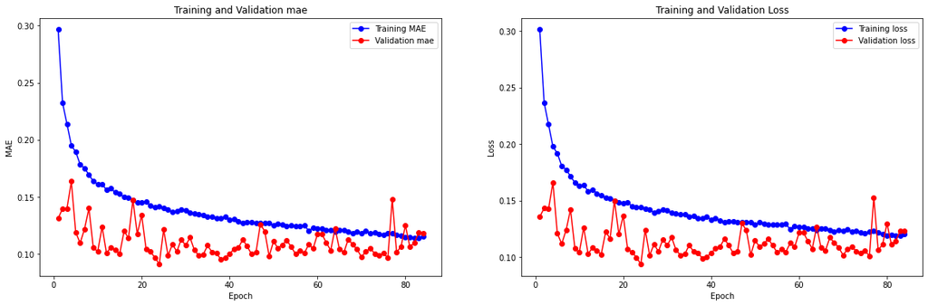

```
3852/3852 ━━━━━━━━━━━━━━━━━━━━ 2s 382us/step - loss: 0.1297 - mae: 0.1268
963/963 ━━━━━━━━━━━━━━━━━━━━ 1s 360us/step - loss: 0.0945 - mae: 0.0916
990/990 ━━━━━━━━━━━━━━━━━━━━ 0s 478us/step - loss: 0.1136 - mae: 0.1106
```

```
Training MAE: 71530.42743997143
```

```
Validation MAE: 52107.307964622036
```

```python
plot(history)
train_MAE = model.evaluate(trainData)[-1] * stdSales
val_MAE = model.evaluate(valData)[-1] * stdSales
test_MAE = model.evaluate(testData)[-1] * stdSales
print(f"Training MAE: {train_MAE}")
print(f"Validation MAE: {val_MAE}")

save_model_results(val_results_path, model_name, val_MAE)
save_model_results(test_results_path, model_name, test_MAE)
```

### **Results discussion**

In this case, the results obtained (**71530** in train) indicate that the model has regained its fitting capacity by using **lighter regularizations**, besides, the validation is **the best so far** (**52107**), which may indicate that a **slight L2 regularization** may benefit the model. In the next steps, we'll use **LSTMs** trying to improve the capabilities and performance of our models.

## **Complex LSTM**

### Building the model

```python
model_name = "complex_LSTM"
```

```python
inputs = Input(shape=(seqLength, nFeatures))

x = LSTM(units=32, activation='relu', return_sequences=True)(inputs)
x = LSTM(units=64, activation='relu', return_sequences=True)(inputs)
x = LSTM(units=128, activation='relu', return_sequences=True)(inputs)
x = LSTM(units=64, activation='relu')(inputs)
outputs = Dense(1)(x)

model = Model(inputs=inputs, outputs=outputs)
model.compile(optimizer='adam', loss='mean_absolute_error', metrics=['mae'])
model.summary()
```

```
Model: "functional_13"
```

```
┏━━━━━━━━━━━━━━━━━━━━━━━━━━━━━━━━━┳━━━━━━━━━━━━━━━━━━━━━━━━━━━┳━━━━━━━━━━━━┓
┃ Layer (type)                    ┃ Output Shape              ┃    Param # ┃
┡━━━━━━━━━━━━━━━━━━━━━━━━━━━━━━━━━╇━━━━━━━━━━━━━━━━━━━━━━━━━━━╇━━━━━━━━━━━━┩
│ input_layer_6 (InputLayer)      │ (None, 3, 6)              │          0 │
├─────────────────────────────────┼───────────────────────────┼────────────┤
│ lstm_3 (LSTM)                   │ (None, 64)                │     18,176 │
├─────────────────────────────────┼───────────────────────────┼────────────┤
│ dense_6 (Dense)                 │ (None, 1)                 │         65 │
└─────────────────────────────────┴───────────────────────────┴────────────┘
```

```
 Total params: 18,241 (71.25 KB)
```

```
 Trainable params: 18,241 (71.25 KB)
```

```
 Non-trainable params: 0 (0.00 B)
```

### Training

```python
# Initialize the EarlyStopping callback
early_stopping = EarlyStopping(
    monitor='val_loss',
    patience=60,
    restore_best_weights=True
)

# Train the model with the EarlyStopping callback
history = model.fit(
    trainData,
    epochs=500,
    batch_size=batchSize,
    validation_data=valData,
    callbacks=[early_stopping]  # Add the EarlyStopping callback to the callbacks list
)
```

```
3852/3852 ━━━━━━━━━━━━━━━━━━━━ 4s 702us/step - loss: 0.3030 - mae: 0.3030 - val_loss: 0.1252 - val_mae: 0.1252
3852/3852 ━━━━━━━━━━━━━━━━━━━━ 3s 639us/step - loss: 0.2071 - mae: 0.2071 - val_loss: 0.1358 - val_mae: 0.1358
3852/3852 ━━━━━━━━━━━━━━━━━━━━ 3s 674us/step - loss: 0.1949 - mae: 0.1949 - val_loss: 0.1192 - val_mae: 0.1192
3852/3852 ━━━━━━━━━━━━━━━━━━━━ 3s 661us/step - loss: 0.1873 - mae: 0.1873 - val_loss: 0.1174 - val_mae: 0.1174
3852/3852 ━━━━━━━━━━━━━━━━━━━━ 3s 660us/step - loss: 0.1820 - mae: 0.1820 - val_loss: 0.1155 - val_mae: 0.1155
3852/3852 ━━━━━━━━━━━━━━━━━━━━ 3s 645us/step - loss: 0.1729 - mae: 0.1729 - val_loss: 0.1047 - val_mae: 0.1047
3852/3852 ━━━━━━━━━━━━━━━━━━━━ 3s 664us/step - loss: 0.1645 - mae: 0.1645 - val_loss: 0.1177 - val_mae: 0.1177
3852/3852 ━━━━━━━━━━━━━━━━━━━━ 3s 674us/step - loss: 0.1601 - mae: 0.1601 - val_loss: 0.1037 - val_mae: 0.1037
3852/3852 ━━━━━━━━━━━━━━━━━━━━ 3s 634us/step - loss: 0.1576 - mae: 0.1576 - val_loss: 0.1126 - val_mae: 0.1126
3852/3852 ━━━━━━━━━━━━━━━━━━━━ 3s 655us/step - loss: 0.1632 - mae: 0.1632 - val_loss: 0.1232 - val_mae: 0.1232
3852/3852 ━━━━━━━━━━━━━━━━━━━━ 3s 668us/step - loss: 0.1575 - mae: 0.1575 - val_loss: 0.1110 - val_mae: 0.1110
3852/3852 ━━━━━━━━━━━━━━━━━━━━ 3s 653us/step - loss: 0.1510 - mae: 0.1510 - val_loss: 0.1107 - val_mae: 0.1107
3852/3852 ━━━━━━━━━━━━━━━━━━━━ 3s 681us/step - loss: 0.1482 - mae: 0.1482 - val_loss: 0.0985 - val_mae: 0.0985
3852/3852 ━━━━━━━━━━━━━━━━━━━━ 3s 678us/step - loss: 0.1449 - mae: 0.1449 - val_loss: 0.0960 - val_mae: 0.0960
3852/3852 ━━━━━━━━━━━━━━━━━━━━ 3s 725us/step - loss: 0.1413 - mae: 0.1413 - val_loss: 0.1023 - val_mae: 0.1023
3852/3852 ━━━━━━━━━━━━━━━━━━━━ 3s 676us/step - loss: 0.1413 - mae: 0.1413 - val_loss: 0.1027 - val_mae: 0.1027
3852/3852 ━━━━━━━━━━━━━━━━━━━━ 3s 667us/step - loss: 0.1415 - mae: 0.1415 - val_loss: 0.1005 - val_mae: 0.1005
3852/3852 ━━━━━━━━━━━━━━━━━━━━ 3s 651us/step - loss: 0.1407 - mae: 0.1407 - val_loss: 0.1007 - val_mae: 0.1007
3852/3852 ━━━━━━━━━━━━━━━━━━━━ 3s 660us/step - loss: 0.1368 - mae: 0.1368 - val_loss: 0.0988 - val_mae: 0.0988
3852/3852 ━━━━━━━━━━━━━━━━━━━━ 3s 670us/step - loss: 0.1404 - mae: 0.1404 - val_loss: 0.0974 - val_mae: 0.0974
3852/3852 ━━━━━━━━━━━━━━━━━━━━ 3s 671us/step - loss: 0.1409 - mae: 0.1409 - val_loss: 0.0954 - val_mae: 0.0954
3852/3852 ━━━━━━━━━━━━━━━━━━━━ 3s 697us/step - loss: 0.1317 - mae: 0.1317 - val_loss: 0.1013 - val_mae: 0.1013
3852/3852 ━━━━━━━━━━━━━━━━━━━━ 3s 678us/step - loss: 0.1368 - mae: 0.1368 - val_loss: 0.1032 - val_mae: 0.1032
3852/3852 ━━━━━━━━━━━━━━━━━━━━ 3s 648us/step - loss: 0.1308 - mae: 0.1308 - val_loss: 0.1011 - val_mae: 0.1011
3852/3852 ━━━━━━━━━━━━━━━━━━━━ 3s 683us/step - loss: 0.1330 - mae: 0.1330 - val_loss: 0.1064 - val_mae: 0.1064
3852/3852 ━━━━━━━━━━━━━━━━━━━━ 3s 656us/step - loss: 0.1294 - mae: 0.1294 - val_loss: 0.0975 - val_mae: 0.0975
3852/3852 ━━━━━━━━━━━━━━━━━━━━ 3s 675us/step - loss: 0.1277 - mae: 0.1277 - val_loss: 0.0963 - val_mae: 0.0963
3852/3852 ━━━━━━━━━━━━━━━━━━━━ 3s 670us/step - loss: 0.1295 - mae: 0.1295 - val_loss: 0.1039 - val_mae: 0.1039
3852/3852 ━━━━━━━━━━━━━━━━━━━━ 3s 653us/step - loss: 0.1279 - mae: 0.1279 - val_loss: 0.1039 - val_mae: 0.1039
3852/3852 ━━━━━━━━━━━━━━━━━━━━ 3s 653us/step - loss: 0.1264 - mae: 0.1264 - val_loss: 0.1084 - val_mae: 0.1084
3852/3852 ━━━━━━━━━━━━━━━━━━━━ 3s 676us/step - loss: 0.1245 - mae: 0.1245 - val_loss: 0.1009 - val_mae: 0.1009
3852/3852 ━━━━━━━━━━━━━━━━━━━━ 3s 684us/step - loss: 0.1212 - mae: 0.1212 - val_loss: 0.1048 - val_mae: 0.1048
3852/3852 ━━━━━━━━━━━━━━━━━━━━ 3s 678us/step - loss: 0.1215 - mae: 0.1215 - val_loss: 0.1013 - val_mae: 0.1013
3852/3852 ━━━━━━━━━━━━━━━━━━━━ 3s 654us/step - loss: 0.1235 - mae: 0.1235 - val_loss: 0.1001 - val_mae: 0.1001
3852/3852 ━━━━━━━━━━━━━━━━━━━━ 3s 647us/step - loss: 0.1190 - mae: 0.1190 - val_loss: 0.0976 - val_mae: 0.0976
3852/3852 ━━━━━━━━━━━━━━━━━━━━ 3s 672us/step - loss: 0.1272 - mae: 0.1272 - val_loss: 0.1086 - val_mae: 0.1086
3852/3852 ━━━━━━━━━━━━━━━━━━━━ 3s 653us/step - loss: 0.1202 - mae: 0.1202 - val_loss: 0.1079 - val_mae: 0.1079
3852/3852 ━━━━━━━━━━━━━━━━━━━━ 3s 677us/step - loss: 0.1161 - mae: 0.1161 - val_loss: 0.1072 - val_mae: 0.1072
3852/3852 ━━━━━━━━━━━━━━━━━━━━ 3s 652us/step - loss: 0.1187 - mae: 0.1187 - val_loss: 0.1123 - val_mae: 0.1123
3852/3852 ━━━━━━━━━━━━━━━━━━━━ 3s 669us/step - loss: 0.1158 - mae: 0.1158 - val_loss: 0.1029 - val_mae: 0.1029
```

[output cut: 26 more lines]

```
3852/3852 ━━━━━━━━━━━━━━━━━━━━ 3s 637us/step - loss: 0.1027 - mae: 0.1027 - val_loss: 0.1310 - val_mae: 0.1310
3852/3852 ━━━━━━━━━━━━━━━━━━━━ 3s 644us/step - loss: 0.1001 - mae: 0.1001 - val_loss: 0.1252 - val_mae: 0.1252
3852/3852 ━━━━━━━━━━━━━━━━━━━━ 3s 643us/step - loss: 0.0985 - mae: 0.0985 - val_loss: 0.1281 - val_mae: 0.1281
3852/3852 ━━━━━━━━━━━━━━━━━━━━ 3s 662us/step - loss: 0.1016 - mae: 0.1016 - val_loss: 0.1285 - val_mae: 0.1285
3852/3852 ━━━━━━━━━━━━━━━━━━━━ 3s 651us/step - loss: 0.0947 - mae: 0.0947 - val_loss: 0.1233 - val_mae: 0.1233
3852/3852 ━━━━━━━━━━━━━━━━━━━━ 3s 671us/step - loss: 0.0991 - mae: 0.0991 - val_loss: 0.1296 - val_mae: 0.1296
3852/3852 ━━━━━━━━━━━━━━━━━━━━ 3s 648us/step - loss: 0.0961 - mae: 0.0961 - val_loss: 0.1170 - val_mae: 0.1170
3852/3852 ━━━━━━━━━━━━━━━━━━━━ 3s 645us/step - loss: 0.0966 - mae: 0.0966 - val_loss: 0.1133 - val_mae: 0.1133
3852/3852 ━━━━━━━━━━━━━━━━━━━━ 3s 662us/step - loss: 0.0971 - mae: 0.0971 - val_loss: 0.1255 - val_mae: 0.1255
3852/3852 ━━━━━━━━━━━━━━━━━━━━ 3s 676us/step - loss: 0.0982 - mae: 0.0982 - val_loss: 0.1296 - val_mae: 0.1296
3852/3852 ━━━━━━━━━━━━━━━━━━━━ 3s 660us/step - loss: 0.0976 - mae: 0.0976 - val_loss: 0.1214 - val_mae: 0.1214
3852/3852 ━━━━━━━━━━━━━━━━━━━━ 3s 649us/step - loss: 0.0962 - mae: 0.0962 - val_loss: 0.1219 - val_mae: 0.1219
3852/3852 ━━━━━━━━━━━━━━━━━━━━ 3s 644us/step - loss: 0.0980 - mae: 0.0980 - val_loss: 0.1175 - val_mae: 0.1175
3852/3852 ━━━━━━━━━━━━━━━━━━━━ 3s 638us/step - loss: 0.0948 - mae: 0.0948 - val_loss: 0.1201 - val_mae: 0.1201
3852/3852 ━━━━━━━━━━━━━━━━━━━━ 3s 657us/step - loss: 0.0927 - mae: 0.0927 - val_loss: 0.1302 - val_mae: 0.1302
```

### Evaluation

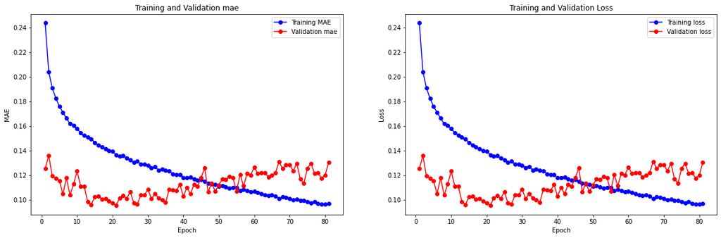

```
3852/3852 ━━━━━━━━━━━━━━━━━━━━ 1s 268us/step - loss: 0.1334 - mae: 0.1334
963/963 ━━━━━━━━━━━━━━━━━━━━ 1s 279us/step - loss: 0.0936 - mae: 0.0936
990/990 ━━━━━━━━━━━━━━━━━━━━ 0s 469us/step - loss: 0.0989 - mae: 0.0989
```

```
Training MAE: 73761.03116567494
```

```
Validation MAE: 54545.78028879751
```

```python
plot(history)
train_MAE = model.evaluate(trainData)[-1] * stdSales
val_MAE = model.evaluate(valData)[-1] * stdSales
test_MAE = model.evaluate(testData)[-1] * stdSales
print(f"Training MAE: {train_MAE}")
print(f"Validation MAE: {val_MAE}")

save_model_results(val_results_path, model_name, val_MAE)
save_model_results(test_results_path, model_name, test_MAE)
```

### **Results discussion**

Upon reviewing the results, several aspects can be observed: The MAE on the training set is similar than that obtained in previous experiments using SimpleRNN, and it can be noted that while overfitting is present, it is also being **mitigated** by using **Early Stopping**. On the other hand, the validation MAE doesn't seem to be improving, consequently, we will employ some regularization methods in an attempt to reduce overfitting and further decrease the MAE in validation.

## **LSTM with L2 Regularization**

### Building the model

```python
model_name = "complex_LSTM_L2"
```

```python
inputs = Input(shape=(seqLength, nFeatures))

x = LSTM(units=32, activation='relu', return_sequences=True,
              kernel_regularizer=l2(0.00001), recurrent_regularizer=l2(0.00001))(inputs)

x = LSTM(units=64, activation='relu', return_sequences=True,
              kernel_regularizer=l2(0.00001), recurrent_regularizer=l2(0.00001))(x)

x = LSTM(units=128, activation='relu', return_sequences=True,
              kernel_regularizer=l2(0.00001), recurrent_regularizer=l2(0.00001))(x)

x = LSTM(units=64, activation='relu', kernel_regularizer=l2(0.00001), recurrent_regularizer=l2(0.00001))(x)

outputs = Dense(1)(x)

model = Model(inputs=inputs, outputs=outputs)
model.compile(optimizer='adam', loss='mean_absolute_error', metrics=['mae'])
model.summary()
```

```
Model: "functional_15"
```

```
┏━━━━━━━━━━━━━━━━━━━━━━━━━━━━━━━━━┳━━━━━━━━━━━━━━━━━━━━━━━━━━━┳━━━━━━━━━━━━┓
┃ Layer (type)                    ┃ Output Shape              ┃    Param # ┃
┡━━━━━━━━━━━━━━━━━━━━━━━━━━━━━━━━━╇━━━━━━━━━━━━━━━━━━━━━━━━━━━╇━━━━━━━━━━━━┩
│ input_layer_7 (InputLayer)      │ (None, 3, 6)              │          0 │
├─────────────────────────────────┼───────────────────────────┼────────────┤
│ lstm_4 (LSTM)                   │ (None, 3, 32)             │      4,992 │
├─────────────────────────────────┼───────────────────────────┼────────────┤
│ lstm_5 (LSTM)                   │ (None, 3, 64)             │     24,832 │
├─────────────────────────────────┼───────────────────────────┼────────────┤
│ lstm_6 (LSTM)                   │ (None, 3, 128)            │     98,816 │
├─────────────────────────────────┼───────────────────────────┼────────────┤
│ lstm_7 (LSTM)                   │ (None, 64)                │     49,408 │
├─────────────────────────────────┼───────────────────────────┼────────────┤
│ dense_7 (Dense)                 │ (None, 1)                 │         65 │
└─────────────────────────────────┴───────────────────────────┴────────────┘
```

```
 Total params: 178,113 (695.75 KB)
```

```
 Trainable params: 178,113 (695.75 KB)
```

```
 Non-trainable params: 0 (0.00 B)
```

### Training

```python
# Initialize the EarlyStopping callback
early_stopping = EarlyStopping(
    monitor='val_loss',
    patience=60,
    restore_best_weights=True
)

# Train the model with the EarlyStopping callback
history = model.fit(
    trainData,
    epochs=500,
    batch_size=batchSize,
    validation_data=valData,
    callbacks=[early_stopping]  # Add the EarlyStopping callback to the callbacks list
)
```

```
3852/3852 ━━━━━━━━━━━━━━━━━━━━ 9s 1ms/step - loss: 0.4068 - mae: 0.4047 - val_loss: 0.1426 - val_mae: 0.1397
3852/3852 ━━━━━━━━━━━━━━━━━━━━ 5s 1ms/step - loss: 0.2424 - mae: 0.2392 - val_loss: 0.1468 - val_mae: 0.1430
3852/3852 ━━━━━━━━━━━━━━━━━━━━ 5s 1ms/step - loss: 0.2246 - mae: 0.2207 - val_loss: 0.1395 - val_mae: 0.1354
3852/3852 ━━━━━━━━━━━━━━━━━━━━ 5s 1ms/step - loss: 0.2139 - mae: 0.2097 - val_loss: 0.1497 - val_mae: 0.1456
3852/3852 ━━━━━━━━━━━━━━━━━━━━ 5s 1ms/step - loss: 0.2146 - mae: 0.2104 - val_loss: 0.1349 - val_mae: 0.1307
3852/3852 ━━━━━━━━━━━━━━━━━━━━ 5s 1ms/step - loss: 0.1976 - mae: 0.1933 - val_loss: 0.1250 - val_mae: 0.1207
3852/3852 ━━━━━━━━━━━━━━━━━━━━ 5s 1ms/step - loss: 0.1983 - mae: 0.1941 - val_loss: 0.1151 - val_mae: 0.1107
3852/3852 ━━━━━━━━━━━━━━━━━━━━ 5s 1ms/step - loss: 0.1982 - mae: 0.1937 - val_loss: 0.1422 - val_mae: 0.1376
3852/3852 ━━━━━━━━━━━━━━━━━━━━ 5s 1ms/step - loss: 0.1830 - mae: 0.1784 - val_loss: 0.1074 - val_mae: 0.1027
3852/3852 ━━━━━━━━━━━━━━━━━━━━ 5s 1ms/step - loss: 0.1823 - mae: 0.1776 - val_loss: 0.1173 - val_mae: 0.1126
3852/3852 ━━━━━━━━━━━━━━━━━━━━ 5s 1ms/step - loss: 0.1771 - mae: 0.1724 - val_loss: 0.1278 - val_mae: 0.1231
3852/3852 ━━━━━━━━━━━━━━━━━━━━ 5s 1ms/step - loss: 0.1773 - mae: 0.1725 - val_loss: 0.1184 - val_mae: 0.1137
3852/3852 ━━━━━━━━━━━━━━━━━━━━ 5s 1ms/step - loss: 0.1676 - mae: 0.1628 - val_loss: 0.1119 - val_mae: 0.1070
3852/3852 ━━━━━━━━━━━━━━━━━━━━ 5s 1ms/step - loss: 0.1751 - mae: 0.1702 - val_loss: 0.1215 - val_mae: 0.1166
3852/3852 ━━━━━━━━━━━━━━━━━━━━ 5s 1ms/step - loss: 0.1724 - mae: 0.1676 - val_loss: 0.1250 - val_mae: 0.1202
3852/3852 ━━━━━━━━━━━━━━━━━━━━ 5s 1ms/step - loss: 0.1729 - mae: 0.1680 - val_loss: 0.1213 - val_mae: 0.1163
3852/3852 ━━━━━━━━━━━━━━━━━━━━ 5s 1ms/step - loss: 0.1656 - mae: 0.1606 - val_loss: 0.1103 - val_mae: 0.1053
3852/3852 ━━━━━━━━━━━━━━━━━━━━ 5s 1ms/step - loss: 0.1599 - mae: 0.1550 - val_loss: 0.1037 - val_mae: 0.0987
3852/3852 ━━━━━━━━━━━━━━━━━━━━ 5s 1ms/step - loss: 0.1608 - mae: 0.1557 - val_loss: 0.1195 - val_mae: 0.1145
3852/3852 ━━━━━━━━━━━━━━━━━━━━ 5s 1ms/step - loss: 0.1535 - mae: 0.1485 - val_loss: 0.1375 - val_mae: 0.1325
3852/3852 ━━━━━━━━━━━━━━━━━━━━ 5s 1ms/step - loss: 0.1580 - mae: 0.1530 - val_loss: 0.1131 - val_mae: 0.1081
3852/3852 ━━━━━━━━━━━━━━━━━━━━ 5s 1ms/step - loss: 0.1588 - mae: 0.1537 - val_loss: 0.1099 - val_mae: 0.1048
3852/3852 ━━━━━━━━━━━━━━━━━━━━ 5s 1ms/step - loss: 0.1534 - mae: 0.1483 - val_loss: 0.1194 - val_mae: 0.1142
3852/3852 ━━━━━━━━━━━━━━━━━━━━ 5s 1ms/step - loss: 0.1569 - mae: 0.1517 - val_loss: 0.1096 - val_mae: 0.1044
3852/3852 ━━━━━━━━━━━━━━━━━━━━ 5s 1ms/step - loss: 0.1537 - mae: 0.1485 - val_loss: 0.1316 - val_mae: 0.1263
3852/3852 ━━━━━━━━━━━━━━━━━━━━ 5s 1ms/step - loss: 0.1480 - mae: 0.1428 - val_loss: 0.1163 - val_mae: 0.1111
3852/3852 ━━━━━━━━━━━━━━━━━━━━ 5s 1ms/step - loss: 0.1490 - mae: 0.1437 - val_loss: 0.1201 - val_mae: 0.1147
3852/3852 ━━━━━━━━━━━━━━━━━━━━ 5s 1ms/step - loss: 0.1494 - mae: 0.1441 - val_loss: 0.1170 - val_mae: 0.1116
3852/3852 ━━━━━━━━━━━━━━━━━━━━ 6s 1ms/step - loss: 0.1458 - mae: 0.1404 - val_loss: 0.1128 - val_mae: 0.1073
3852/3852 ━━━━━━━━━━━━━━━━━━━━ 6s 1ms/step - loss: 0.1483 - mae: 0.1428 - val_loss: 0.1094 - val_mae: 0.1039
3852/3852 ━━━━━━━━━━━━━━━━━━━━ 5s 1ms/step - loss: 0.1499 - mae: 0.1444 - val_loss: 0.1196 - val_mae: 0.1140
3852/3852 ━━━━━━━━━━━━━━━━━━━━ 5s 1ms/step - loss: 0.1456 - mae: 0.1400 - val_loss: 0.1238 - val_mae: 0.1181
3852/3852 ━━━━━━━━━━━━━━━━━━━━ 5s 1ms/step - loss: 0.1463 - mae: 0.1406 - val_loss: 0.1064 - val_mae: 0.1008
3852/3852 ━━━━━━━━━━━━━━━━━━━━ 5s 1ms/step - loss: 0.1433 - mae: 0.1376 - val_loss: 0.1303 - val_mae: 0.1246
3852/3852 ━━━━━━━━━━━━━━━━━━━━ 5s 1ms/step - loss: 0.1380 - mae: 0.1323 - val_loss: 0.1099 - val_mae: 0.1042
3852/3852 ━━━━━━━━━━━━━━━━━━━━ 5s 1ms/step - loss: 0.1445 - mae: 0.1387 - val_loss: 0.1220 - val_mae: 0.1162
3852/3852 ━━━━━━━━━━━━━━━━━━━━ 5s 1ms/step - loss: 0.1410 - mae: 0.1353 - val_loss: 0.1065 - val_mae: 0.1006
3852/3852 ━━━━━━━━━━━━━━━━━━━━ 5s 1ms/step - loss: 0.1408 - mae: 0.1350 - val_loss: 0.1173 - val_mae: 0.1114
3852/3852 ━━━━━━━━━━━━━━━━━━━━ 5s 1ms/step - loss: 0.1436 - mae: 0.1377 - val_loss: 0.1071 - val_mae: 0.1011
3852/3852 ━━━━━━━━━━━━━━━━━━━━ 5s 1ms/step - loss: 0.1395 - mae: 0.1335 - val_loss: 0.1038 - val_mae: 0.0978
```

[output cut: 23 more lines]

```
3852/3852 ━━━━━━━━━━━━━━━━━━━━ 5s 1ms/step - loss: 0.1310 - mae: 0.1242 - val_loss: 0.1197 - val_mae: 0.1128
3852/3852 ━━━━━━━━━━━━━━━━━━━━ 5s 1ms/step - loss: 0.1212 - mae: 0.1144 - val_loss: 0.1160 - val_mae: 0.1091
3852/3852 ━━━━━━━━━━━━━━━━━━━━ 5s 1ms/step - loss: 0.1256 - mae: 0.1187 - val_loss: 0.1102 - val_mae: 0.1032
3852/3852 ━━━━━━━━━━━━━━━━━━━━ 5s 1ms/step - loss: 0.1257 - mae: 0.1188 - val_loss: 0.1168 - val_mae: 0.1098
3852/3852 ━━━━━━━━━━━━━━━━━━━━ 5s 1ms/step - loss: 0.1283 - mae: 0.1214 - val_loss: 0.1157 - val_mae: 0.1088
3852/3852 ━━━━━━━━━━━━━━━━━━━━ 5s 1ms/step - loss: 0.1261 - mae: 0.1191 - val_loss: 0.1169 - val_mae: 0.1099
3852/3852 ━━━━━━━━━━━━━━━━━━━━ 5s 1ms/step - loss: 0.1293 - mae: 0.1224 - val_loss: 0.1096 - val_mae: 0.1026
3852/3852 ━━━━━━━━━━━━━━━━━━━━ 5s 1ms/step - loss: 0.1243 - mae: 0.1173 - val_loss: 0.1203 - val_mae: 0.1133
3852/3852 ━━━━━━━━━━━━━━━━━━━━ 5s 1ms/step - loss: 0.1248 - mae: 0.1178 - val_loss: 0.1147 - val_mae: 0.1076
3852/3852 ━━━━━━━━━━━━━━━━━━━━ 5s 1ms/step - loss: 0.1234 - mae: 0.1163 - val_loss: 0.1176 - val_mae: 0.1105
3852/3852 ━━━━━━━━━━━━━━━━━━━━ 5s 1ms/step - loss: 0.1254 - mae: 0.1184 - val_loss: 0.1189 - val_mae: 0.1117
3852/3852 ━━━━━━━━━━━━━━━━━━━━ 5s 1ms/step - loss: 0.1235 - mae: 0.1163 - val_loss: 0.1098 - val_mae: 0.1026
3852/3852 ━━━━━━━━━━━━━━━━━━━━ 5s 1ms/step - loss: 0.1183 - mae: 0.1111 - val_loss: 0.1416 - val_mae: 0.1343
3852/3852 ━━━━━━━━━━━━━━━━━━━━ 5s 1ms/step - loss: 0.1216 - mae: 0.1143 - val_loss: 0.1216 - val_mae: 0.1143
3852/3852 ━━━━━━━━━━━━━━━━━━━━ 5s 1ms/step - loss: 0.1228 - mae: 0.1155 - val_loss: 0.1129 - val_mae: 0.1055
```

### Evaluation

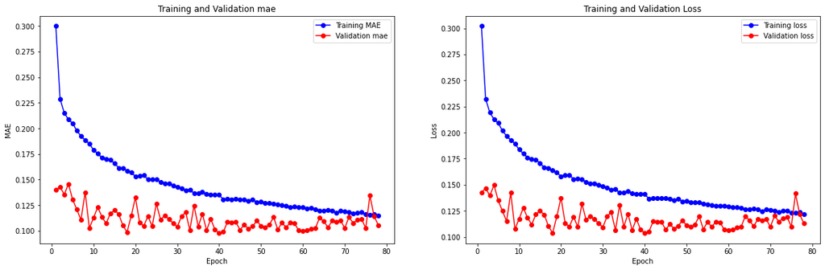

```
3852/3852 ━━━━━━━━━━━━━━━━━━━━ 2s 364us/step - loss: 0.1456 - mae: 0.1406
963/963 ━━━━━━━━━━━━━━━━━━━━ 1s 368us/step - loss: 0.1041 - mae: 0.0991
990/990 ━━━━━━━━━━━━━━━━━━━━ 0s 476us/step - loss: 0.1211 - mae: 0.1161
```

```
Training MAE: 81866.3897146361
```

```
Validation MAE: 56450.2184652097
```

```python
plot(history)
train_MAE = model.evaluate(trainData)[-1] * stdSales
val_MAE = model.evaluate(valData)[-1] * stdSales
test_MAE = model.evaluate(testData)[-1] * stdSales
print(f"Training MAE: {train_MAE}")
print(f"Validation MAE: {val_MAE}")

save_model_results(val_results_path, model_name, val_MAE)
save_model_results(test_results_path, model_name, test_MAE)
```

### **Results discussion**

As we expected and similar to previous occurrences, the model has proven to be **extremely sensitive to regularization**. Again, the use of **DropOut,** **L1 Regularization**, or average **L2 regularization** values has resulted in a **significant deterioration** of the results obtained both in training and validation. Finally, we present here the results obtained with **very slight L2 regularization**, which, while offering **acceptable** values, are still slightly worse than those obtained without applying any regularization during training, beyond Early Stopping. However, even though the final results are slightly worse, it is noteworthy that the use of L2 regularization has produced a **notably more stable training**, which could be beneficial. Next, we are training a more complex LSTMs model with the same regularization, trying to find if this added complexity can help on improving the results by increasing its learning capabilities.

## **More complex LSTM with L2 Regularization**

### Building the Model

```python
model_name = "very_complex_LSTM_L2"
```

```python
inputs = Input(shape=(seqLength, nFeatures))

x = LSTM(units=32, activation='relu', return_sequences=True,
              kernel_regularizer=l2(0.00001), recurrent_regularizer=l2(0.00001))(inputs)

x = LSTM(units=64, activation='relu', return_sequences=True,
              kernel_regularizer=l2(0.00001), recurrent_regularizer=l2(0.00001))(x)

x = LSTM(units=128, activation='relu', return_sequences=True,
              kernel_regularizer=l2(0.00001), recurrent_regularizer=l2(0.00001))(x)

x = LSTM(units=256, activation='relu', return_sequences=True,
              kernel_regularizer=l2(0.00001), recurrent_regularizer=l2(0.00001))(x)

x = LSTM(units=64, activation='relu', kernel_regularizer=l2(0.00001), recurrent_regularizer=l2(0.00001))(x)

outputs = Dense(1)(x)

model = Model(inputs=inputs, outputs=outputs)
model.compile(optimizer='adam', loss='mean_absolute_error', metrics=['mae'])
model.summary()
```

```
Model: "functional_17"
```

```
┏━━━━━━━━━━━━━━━━━━━━━━━━━━━━━━━━━┳━━━━━━━━━━━━━━━━━━━━━━━━━━━┳━━━━━━━━━━━━┓
┃ Layer (type)                    ┃ Output Shape              ┃    Param # ┃
┡━━━━━━━━━━━━━━━━━━━━━━━━━━━━━━━━━╇━━━━━━━━━━━━━━━━━━━━━━━━━━━╇━━━━━━━━━━━━┩
│ input_layer_8 (InputLayer)      │ (None, 3, 6)              │          0 │
├─────────────────────────────────┼───────────────────────────┼────────────┤
│ lstm_8 (LSTM)                   │ (None, 3, 32)             │      4,992 │
├─────────────────────────────────┼───────────────────────────┼────────────┤
│ lstm_9 (LSTM)                   │ (None, 3, 64)             │     24,832 │
├─────────────────────────────────┼───────────────────────────┼────────────┤
│ lstm_10 (LSTM)                  │ (None, 3, 128)            │     98,816 │
├─────────────────────────────────┼───────────────────────────┼────────────┤
│ lstm_11 (LSTM)                  │ (None, 3, 256)            │    394,240 │
├─────────────────────────────────┼───────────────────────────┼────────────┤
│ lstm_12 (LSTM)                  │ (None, 64)                │     82,176 │
├─────────────────────────────────┼───────────────────────────┼────────────┤
│ dense_8 (Dense)                 │ (None, 1)                 │         65 │
└─────────────────────────────────┴───────────────────────────┴────────────┘
```

```
 Total params: 605,121 (2.31 MB)
```

```
 Trainable params: 605,121 (2.31 MB)
```

```
 Non-trainable params: 0 (0.00 B)
```

### Training

```python
# Initialize the EarlyStopping callback
early_stopping = EarlyStopping(
    monitor='val_loss',
    patience=60,
    restore_best_weights=True
)

# Train the model with the EarlyStopping callback
history = model.fit(
    trainData,
    epochs=500,
    batch_size=batchSize,
    validation_data=valData,
    callbacks=[early_stopping]  # Add the EarlyStopping callback to the callbacks list
)
```

```
3852/3852 ━━━━━━━━━━━━━━━━━━━━ 10s 2ms/step - loss: 0.4211 - mae: 0.4185 - val_loss: 0.2024 - val_mae: 0.1991
3852/3852 ━━━━━━━━━━━━━━━━━━━━ 6s 2ms/step - loss: 0.2431 - mae: 0.2395 - val_loss: 0.1617 - val_mae: 0.1576
3852/3852 ━━━━━━━━━━━━━━━━━━━━ 6s 1ms/step - loss: 0.2307 - mae: 0.2265 - val_loss: 0.1454 - val_mae: 0.1409
3852/3852 ━━━━━━━━━━━━━━━━━━━━ 6s 1ms/step - loss: 0.2249 - mae: 0.2204 - val_loss: 0.1280 - val_mae: 0.1234
3852/3852 ━━━━━━━━━━━━━━━━━━━━ 7s 2ms/step - loss: 0.2149 - mae: 0.2103 - val_loss: 0.1607 - val_mae: 0.1559
3852/3852 ━━━━━━━━━━━━━━━━━━━━ 6s 1ms/step - loss: 0.2140 - mae: 0.2093 - val_loss: 0.1515 - val_mae: 0.1466
3852/3852 ━━━━━━━━━━━━━━━━━━━━ 6s 1ms/step - loss: 0.2097 - mae: 0.2049 - val_loss: 0.1185 - val_mae: 0.1138
3852/3852 ━━━━━━━━━━━━━━━━━━━━ 6s 2ms/step - loss: 0.2025 - mae: 0.1975 - val_loss: 0.1254 - val_mae: 0.1205
3852/3852 ━━━━━━━━━━━━━━━━━━━━ 6s 1ms/step - loss: 0.1933 - mae: 0.1882 - val_loss: 0.1301 - val_mae: 0.1251
3852/3852 ━━━━━━━━━━━━━━━━━━━━ 6s 1ms/step - loss: 0.1935 - mae: 0.1884 - val_loss: 0.1120 - val_mae: 0.1069
3852/3852 ━━━━━━━━━━━━━━━━━━━━ 6s 1ms/step - loss: 0.1879 - mae: 0.1828 - val_loss: 0.1365 - val_mae: 0.1314
3852/3852 ━━━━━━━━━━━━━━━━━━━━ 6s 1ms/step - loss: 0.1870 - mae: 0.1819 - val_loss: 0.1143 - val_mae: 0.1093
3852/3852 ━━━━━━━━━━━━━━━━━━━━ 6s 2ms/step - loss: 0.1900 - mae: 0.1849 - val_loss: 0.1363 - val_mae: 0.1313
3852/3852 ━━━━━━━━━━━━━━━━━━━━ 6s 1ms/step - loss: 0.1850 - mae: 0.1800 - val_loss: 0.1182 - val_mae: 0.1132
3852/3852 ━━━━━━━━━━━━━━━━━━━━ 7s 2ms/step - loss: 0.1830 - mae: 0.1780 - val_loss: 0.1368 - val_mae: 0.1319
3852/3852 ━━━━━━━━━━━━━━━━━━━━ 6s 1ms/step - loss: 0.1855 - mae: 0.1806 - val_loss: 0.1069 - val_mae: 0.1020
3852/3852 ━━━━━━━━━━━━━━━━━━━━ 6s 1ms/step - loss: 0.1752 - mae: 0.1702 - val_loss: 0.1277 - val_mae: 0.1228
3852/3852 ━━━━━━━━━━━━━━━━━━━━ 6s 1ms/step - loss: 0.1807 - mae: 0.1757 - val_loss: 0.1120 - val_mae: 0.1069
3852/3852 ━━━━━━━━━━━━━━━━━━━━ 6s 1ms/step - loss: 0.1741 - mae: 0.1690 - val_loss: 0.1095 - val_mae: 0.1044
3852/3852 ━━━━━━━━━━━━━━━━━━━━ 6s 1ms/step - loss: 0.1698 - mae: 0.1647 - val_loss: 0.1237 - val_mae: 0.1186
3852/3852 ━━━━━━━━━━━━━━━━━━━━ 6s 1ms/step - loss: 0.1702 - mae: 0.1651 - val_loss: 0.1098 - val_mae: 0.1046
3852/3852 ━━━━━━━━━━━━━━━━━━━━ 6s 1ms/step - loss: 0.1637 - mae: 0.1585 - val_loss: 0.1081 - val_mae: 0.1029
3852/3852 ━━━━━━━━━━━━━━━━━━━━ 6s 1ms/step - loss: 0.1665 - mae: 0.1612 - val_loss: 0.1272 - val_mae: 0.1219
3852/3852 ━━━━━━━━━━━━━━━━━━━━ 6s 1ms/step - loss: 0.1655 - mae: 0.1602 - val_loss: 0.1077 - val_mae: 0.1024
3852/3852 ━━━━━━━━━━━━━━━━━━━━ 6s 1ms/step - loss: 0.1568 - mae: 0.1514 - val_loss: 0.1039 - val_mae: 0.0986
3852/3852 ━━━━━━━━━━━━━━━━━━━━ 6s 2ms/step - loss: 0.1571 - mae: 0.1517 - val_loss: 0.1053 - val_mae: 0.0999
3852/3852 ━━━━━━━━━━━━━━━━━━━━ 6s 1ms/step - loss: 0.1571 - mae: 0.1517 - val_loss: 0.1228 - val_mae: 0.1175
3852/3852 ━━━━━━━━━━━━━━━━━━━━ 6s 1ms/step - loss: 0.1534 - mae: 0.1481 - val_loss: 0.1233 - val_mae: 0.1179
3852/3852 ━━━━━━━━━━━━━━━━━━━━ 6s 1ms/step - loss: 0.1558 - mae: 0.1504 - val_loss: 0.1119 - val_mae: 0.1065
3852/3852 ━━━━━━━━━━━━━━━━━━━━ 6s 1ms/step - loss: 0.1518 - mae: 0.1464 - val_loss: 0.1190 - val_mae: 0.1135
3852/3852 ━━━━━━━━━━━━━━━━━━━━ 7s 2ms/step - loss: 0.1457 - mae: 0.1401 - val_loss: 0.1145 - val_mae: 0.1089
3852/3852 ━━━━━━━━━━━━━━━━━━━━ 6s 1ms/step - loss: 0.1553 - mae: 0.1497 - val_loss: 0.1187 - val_mae: 0.1131
3852/3852 ━━━━━━━━━━━━━━━━━━━━ 6s 1ms/step - loss: 0.1525 - mae: 0.1468 - val_loss: 0.1091 - val_mae: 0.1035
3852/3852 ━━━━━━━━━━━━━━━━━━━━ 6s 1ms/step - loss: 0.1462 - mae: 0.1405 - val_loss: 0.1088 - val_mae: 0.1030
3852/3852 ━━━━━━━━━━━━━━━━━━━━ 6s 1ms/step - loss: 0.1467 - mae: 0.1410 - val_loss: 0.1032 - val_mae: 0.0974
3852/3852 ━━━━━━━━━━━━━━━━━━━━ 6s 1ms/step - loss: 0.1478 - mae: 0.1420 - val_loss: 0.1047 - val_mae: 0.0988
3852/3852 ━━━━━━━━━━━━━━━━━━━━ 6s 1ms/step - loss: 0.1451 - mae: 0.1392 - val_loss: 0.1167 - val_mae: 0.1107
3852/3852 ━━━━━━━━━━━━━━━━━━━━ 6s 1ms/step - loss: 0.1488 - mae: 0.1429 - val_loss: 0.1122 - val_mae: 0.1063
3852/3852 ━━━━━━━━━━━━━━━━━━━━ 6s 1ms/step - loss: 0.1475 - mae: 0.1415 - val_loss: 0.1070 - val_mae: 0.1009
3852/3852 ━━━━━━━━━━━━━━━━━━━━ 7s 2ms/step - loss: 0.1431 - mae: 0.1370 - val_loss: 0.1560 - val_mae: 0.1499
```

[output cut: 40 more lines]

```
3852/3852 ━━━━━━━━━━━━━━━━━━━━ 6s 1ms/step - loss: 0.1215 - mae: 0.1135 - val_loss: 0.1125 - val_mae: 0.1045
3852/3852 ━━━━━━━━━━━━━━━━━━━━ 6s 1ms/step - loss: 0.1239 - mae: 0.1159 - val_loss: 0.1165 - val_mae: 0.1085
3852/3852 ━━━━━━━━━━━━━━━━━━━━ 6s 1ms/step - loss: 0.1226 - mae: 0.1146 - val_loss: 0.1115 - val_mae: 0.1035
3852/3852 ━━━━━━━━━━━━━━━━━━━━ 6s 1ms/step - loss: 0.1285 - mae: 0.1204 - val_loss: 0.1173 - val_mae: 0.1092
3852/3852 ━━━━━━━━━━━━━━━━━━━━ 7s 2ms/step - loss: 0.1226 - mae: 0.1145 - val_loss: 0.1107 - val_mae: 0.1026
3852/3852 ━━━━━━━━━━━━━━━━━━━━ 7s 2ms/step - loss: 0.1239 - mae: 0.1157 - val_loss: 0.1242 - val_mae: 0.1160
3852/3852 ━━━━━━━━━━━━━━━━━━━━ 6s 1ms/step - loss: 0.1259 - mae: 0.1177 - val_loss: 0.1226 - val_mae: 0.1144
3852/3852 ━━━━━━━━━━━━━━━━━━━━ 6s 1ms/step - loss: 0.1249 - mae: 0.1166 - val_loss: 0.1360 - val_mae: 0.1278
3852/3852 ━━━━━━━━━━━━━━━━━━━━ 6s 1ms/step - loss: 0.1266 - mae: 0.1183 - val_loss: 0.1121 - val_mae: 0.1038
3852/3852 ━━━━━━━━━━━━━━━━━━━━ 6s 1ms/step - loss: 0.1217 - mae: 0.1134 - val_loss: 0.1226 - val_mae: 0.1141
3852/3852 ━━━━━━━━━━━━━━━━━━━━ 6s 1ms/step - loss: 0.1187 - mae: 0.1103 - val_loss: 0.1290 - val_mae: 0.1207
3852/3852 ━━━━━━━━━━━━━━━━━━━━ 6s 1ms/step - loss: 0.1246 - mae: 0.1162 - val_loss: 0.1221 - val_mae: 0.1136
3852/3852 ━━━━━━━━━━━━━━━━━━━━ 6s 2ms/step - loss: 0.1195 - mae: 0.1110 - val_loss: 0.1204 - val_mae: 0.1120
3852/3852 ━━━━━━━━━━━━━━━━━━━━ 6s 1ms/step - loss: 0.1247 - mae: 0.1162 - val_loss: 0.1341 - val_mae: 0.1256
3852/3852 ━━━━━━━━━━━━━━━━━━━━ 6s 1ms/step - loss: 0.1220 - mae: 0.1135 - val_loss: 0.1280 - val_mae: 0.1194
```

### Evaluation

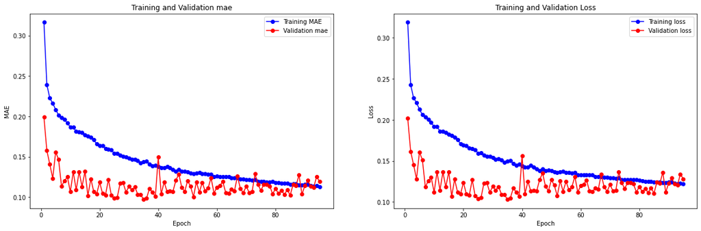

```
3852/3852 ━━━━━━━━━━━━━━━━━━━━ 2s 402us/step - loss: 0.1406 - mae: 0.1348
963/963 ━━━━━━━━━━━━━━━━━━━━ 1s 451us/step - loss: 0.0983 - mae: 0.0925
990/990 ━━━━━━━━━━━━━━━━━━━━ 1s 513us/step - loss: 0.1286 - mae: 0.1228
```

```
Training MAE: 78310.64710724948
```

```
Validation MAE: 55714.31471435544
```

```python
plot(history)
train_MAE = model.evaluate(trainData)[-1] * stdSales
val_MAE = model.evaluate(valData)[-1] * stdSales
test_MAE = model.evaluate(testData)[-1] * stdSales
print(f"Training MAE: {train_MAE}")
print(f"Validation MAE: {val_MAE}")

save_model_results(val_results_path, model_name, val_MAE)
save_model_results(test_results_path, model_name, test_MAE)
```

### **Results discussion**

Given the results of this slightly more complex model, it can be seen that there is **no significant improvement**, and, in fact, the results are still slightly **worse** than those obtained with the LSTM **without** regularization. Therefore, we conclude that the **complexities used so far seem to be sufficient**, and increasing them offers no benefit. Next, we're going to explore the usage and benefits of GRU models.

## **Simple GRU**

### Building Model

```python
model_name = "simple_GRU"
```

```python
inputs = keras.Input(shape=(seqLength, nFeatures))
x = layers.GRU(10, activation='relu',return_sequences=True)(inputs)
x = layers.GRU(10, activation='relu')(x)
outputs = layers.Dense(1)(x)
model = keras.Model(inputs, outputs)

model.compile(optimizer="adam", loss="mean_absolute_error", metrics=["mae"])
model.summary()
```

```
Model: "functional_19"
```

```
┏━━━━━━━━━━━━━━━━━━━━━━━━━━━━━━━━━┳━━━━━━━━━━━━━━━━━━━━━━━━━━━┳━━━━━━━━━━━━┓
┃ Layer (type)                    ┃ Output Shape              ┃    Param # ┃
┡━━━━━━━━━━━━━━━━━━━━━━━━━━━━━━━━━╇━━━━━━━━━━━━━━━━━━━━━━━━━━━╇━━━━━━━━━━━━┩
│ input_layer_9 (InputLayer)      │ (None, 3, 6)              │          0 │
├─────────────────────────────────┼───────────────────────────┼────────────┤
│ gru (GRU)                       │ (None, 3, 10)             │        540 │
├─────────────────────────────────┼───────────────────────────┼────────────┤
│ gru_1 (GRU)                     │ (None, 10)                │        660 │
├─────────────────────────────────┼───────────────────────────┼────────────┤
│ dense_9 (Dense)                 │ (None, 1)                 │         11 │
└─────────────────────────────────┴───────────────────────────┴────────────┘
```

```
 Total params: 1,211 (4.73 KB)
```

```
 Trainable params: 1,211 (4.73 KB)
```

```
 Non-trainable params: 0 (0.00 B)
```

### Training

```python
# Initialize the EarlyStopping callback
early_stopping = EarlyStopping(
    monitor='val_loss',
    patience=60,
    restore_best_weights=True
)

# Train the model with the EarlyStopping callback
history = model.fit(
    trainData,
    epochs=500,
    batch_size=batchSize,
    validation_data=valData,
    callbacks=[early_stopping]  # Add the EarlyStopping callback to the callbacks list
)
```

```
3852/3852 ━━━━━━━━━━━━━━━━━━━━ 5s 870us/step - loss: 0.4079 - mae: 0.4079 - val_loss: 0.1515 - val_mae: 0.1515
3852/3852 ━━━━━━━━━━━━━━━━━━━━ 3s 792us/step - loss: 0.2012 - mae: 0.2012 - val_loss: 0.1261 - val_mae: 0.1261
3852/3852 ━━━━━━━━━━━━━━━━━━━━ 3s 806us/step - loss: 0.1952 - mae: 0.1952 - val_loss: 0.1184 - val_mae: 0.1184
3852/3852 ━━━━━━━━━━━━━━━━━━━━ 3s 798us/step - loss: 0.1881 - mae: 0.1881 - val_loss: 0.1177 - val_mae: 0.1177
3852/3852 ━━━━━━━━━━━━━━━━━━━━ 3s 791us/step - loss: 0.1870 - mae: 0.1870 - val_loss: 0.1198 - val_mae: 0.1198
3852/3852 ━━━━━━━━━━━━━━━━━━━━ 3s 799us/step - loss: 0.1776 - mae: 0.1776 - val_loss: 0.1251 - val_mae: 0.1251
3852/3852 ━━━━━━━━━━━━━━━━━━━━ 3s 785us/step - loss: 0.1770 - mae: 0.1770 - val_loss: 0.1158 - val_mae: 0.1158
3852/3852 ━━━━━━━━━━━━━━━━━━━━ 3s 797us/step - loss: 0.1711 - mae: 0.1711 - val_loss: 0.1064 - val_mae: 0.1064
3852/3852 ━━━━━━━━━━━━━━━━━━━━ 3s 793us/step - loss: 0.1756 - mae: 0.1756 - val_loss: 0.1319 - val_mae: 0.1319
3852/3852 ━━━━━━━━━━━━━━━━━━━━ 3s 805us/step - loss: 0.1659 - mae: 0.1659 - val_loss: 0.1215 - val_mae: 0.1215
3852/3852 ━━━━━━━━━━━━━━━━━━━━ 3s 791us/step - loss: 0.1672 - mae: 0.1672 - val_loss: 0.1043 - val_mae: 0.1043
3852/3852 ━━━━━━━━━━━━━━━━━━━━ 3s 803us/step - loss: 0.1593 - mae: 0.1593 - val_loss: 0.1127 - val_mae: 0.1127
3852/3852 ━━━━━━━━━━━━━━━━━━━━ 4s 820us/step - loss: 0.1611 - mae: 0.1611 - val_loss: 0.1314 - val_mae: 0.1314
3852/3852 ━━━━━━━━━━━━━━━━━━━━ 4s 831us/step - loss: 0.1605 - mae: 0.1605 - val_loss: 0.1067 - val_mae: 0.1067
3852/3852 ━━━━━━━━━━━━━━━━━━━━ 3s 788us/step - loss: 0.1620 - mae: 0.1620 - val_loss: 0.1138 - val_mae: 0.1138
3852/3852 ━━━━━━━━━━━━━━━━━━━━ 4s 801us/step - loss: 0.1595 - mae: 0.1595 - val_loss: 0.0984 - val_mae: 0.0984
3852/3852 ━━━━━━━━━━━━━━━━━━━━ 3s 795us/step - loss: 0.1617 - mae: 0.1617 - val_loss: 0.1044 - val_mae: 0.1044
3852/3852 ━━━━━━━━━━━━━━━━━━━━ 3s 789us/step - loss: 0.1551 - mae: 0.1551 - val_loss: 0.1018 - val_mae: 0.1018
3852/3852 ━━━━━━━━━━━━━━━━━━━━ 4s 983us/step - loss: 0.1551 - mae: 0.1551 - val_loss: 0.1149 - val_mae: 0.1149
3852/3852 ━━━━━━━━━━━━━━━━━━━━ 3s 785us/step - loss: 0.1542 - mae: 0.1542 - val_loss: 0.0973 - val_mae: 0.0973
3852/3852 ━━━━━━━━━━━━━━━━━━━━ 4s 836us/step - loss: 0.1489 - mae: 0.1489 - val_loss: 0.1012 - val_mae: 0.1012
3852/3852 ━━━━━━━━━━━━━━━━━━━━ 3s 783us/step - loss: 0.1495 - mae: 0.1495 - val_loss: 0.1086 - val_mae: 0.1086
3852/3852 ━━━━━━━━━━━━━━━━━━━━ 3s 790us/step - loss: 0.1513 - mae: 0.1513 - val_loss: 0.0982 - val_mae: 0.0982
3852/3852 ━━━━━━━━━━━━━━━━━━━━ 4s 812us/step - loss: 0.1470 - mae: 0.1470 - val_loss: 0.1061 - val_mae: 0.1061
3852/3852 ━━━━━━━━━━━━━━━━━━━━ 4s 819us/step - loss: 0.1422 - mae: 0.1422 - val_loss: 0.0903 - val_mae: 0.0903
3852/3852 ━━━━━━━━━━━━━━━━━━━━ 3s 804us/step - loss: 0.1483 - mae: 0.1483 - val_loss: 0.0940 - val_mae: 0.0940
3852/3852 ━━━━━━━━━━━━━━━━━━━━ 3s 798us/step - loss: 0.1426 - mae: 0.1426 - val_loss: 0.0977 - val_mae: 0.0977
3852/3852 ━━━━━━━━━━━━━━━━━━━━ 4s 812us/step - loss: 0.1501 - mae: 0.1501 - val_loss: 0.0999 - val_mae: 0.0999
3852/3852 ━━━━━━━━━━━━━━━━━━━━ 3s 793us/step - loss: 0.1473 - mae: 0.1473 - val_loss: 0.1006 - val_mae: 0.1006
3852/3852 ━━━━━━━━━━━━━━━━━━━━ 3s 795us/step - loss: 0.1511 - mae: 0.1511 - val_loss: 0.0958 - val_mae: 0.0958
3852/3852 ━━━━━━━━━━━━━━━━━━━━ 3s 794us/step - loss: 0.1412 - mae: 0.1412 - val_loss: 0.1032 - val_mae: 0.1032
3852/3852 ━━━━━━━━━━━━━━━━━━━━ 3s 801us/step - loss: 0.1411 - mae: 0.1411 - val_loss: 0.1000 - val_mae: 0.1000
3852/3852 ━━━━━━━━━━━━━━━━━━━━ 3s 801us/step - loss: 0.1403 - mae: 0.1403 - val_loss: 0.0922 - val_mae: 0.0922
3852/3852 ━━━━━━━━━━━━━━━━━━━━ 3s 793us/step - loss: 0.1450 - mae: 0.1450 - val_loss: 0.1030 - val_mae: 0.1030
3852/3852 ━━━━━━━━━━━━━━━━━━━━ 3s 792us/step - loss: 0.1414 - mae: 0.1414 - val_loss: 0.1076 - val_mae: 0.1076
3852/3852 ━━━━━━━━━━━━━━━━━━━━ 3s 809us/step - loss: 0.1432 - mae: 0.1432 - val_loss: 0.0941 - val_mae: 0.0941
3852/3852 ━━━━━━━━━━━━━━━━━━━━ 3s 792us/step - loss: 0.1367 - mae: 0.1367 - val_loss: 0.1009 - val_mae: 0.1009
3852/3852 ━━━━━━━━━━━━━━━━━━━━ 4s 811us/step - loss: 0.1345 - mae: 0.1345 - val_loss: 0.1047 - val_mae: 0.1047
3852/3852 ━━━━━━━━━━━━━━━━━━━━ 4s 825us/step - loss: 0.1466 - mae: 0.1466 - val_loss: 0.0959 - val_mae: 0.0959
3852/3852 ━━━━━━━━━━━━━━━━━━━━ 4s 846us/step - loss: 0.1426 - mae: 0.1426 - val_loss: 0.1033 - val_mae: 0.1033
```

[output cut: 30 more lines]

```
3852/3852 ━━━━━━━━━━━━━━━━━━━━ 3s 784us/step - loss: 0.1297 - mae: 0.1297 - val_loss: 0.0970 - val_mae: 0.0970
3852/3852 ━━━━━━━━━━━━━━━━━━━━ 3s 778us/step - loss: 0.1294 - mae: 0.1294 - val_loss: 0.0954 - val_mae: 0.0954
3852/3852 ━━━━━━━━━━━━━━━━━━━━ 4s 823us/step - loss: 0.1272 - mae: 0.1272 - val_loss: 0.0907 - val_mae: 0.0907
3852/3852 ━━━━━━━━━━━━━━━━━━━━ 3s 789us/step - loss: 0.1319 - mae: 0.1319 - val_loss: 0.1014 - val_mae: 0.1014
3852/3852 ━━━━━━━━━━━━━━━━━━━━ 3s 787us/step - loss: 0.1284 - mae: 0.1284 - val_loss: 0.0961 - val_mae: 0.0961
3852/3852 ━━━━━━━━━━━━━━━━━━━━ 4s 833us/step - loss: 0.1302 - mae: 0.1302 - val_loss: 0.0997 - val_mae: 0.0997
3852/3852 ━━━━━━━━━━━━━━━━━━━━ 3s 801us/step - loss: 0.1291 - mae: 0.1291 - val_loss: 0.0989 - val_mae: 0.0989
3852/3852 ━━━━━━━━━━━━━━━━━━━━ 3s 792us/step - loss: 0.1247 - mae: 0.1247 - val_loss: 0.1119 - val_mae: 0.1119
3852/3852 ━━━━━━━━━━━━━━━━━━━━ 4s 823us/step - loss: 0.1314 - mae: 0.1314 - val_loss: 0.0927 - val_mae: 0.0927
3852/3852 ━━━━━━━━━━━━━━━━━━━━ 3s 807us/step - loss: 0.1280 - mae: 0.1280 - val_loss: 0.0905 - val_mae: 0.0905
3852/3852 ━━━━━━━━━━━━━━━━━━━━ 3s 806us/step - loss: 0.1295 - mae: 0.1295 - val_loss: 0.1024 - val_mae: 0.1024
3852/3852 ━━━━━━━━━━━━━━━━━━━━ 4s 820us/step - loss: 0.1292 - mae: 0.1292 - val_loss: 0.0912 - val_mae: 0.0912
3852/3852 ━━━━━━━━━━━━━━━━━━━━ 4s 820us/step - loss: 0.1267 - mae: 0.1267 - val_loss: 0.1014 - val_mae: 0.1014
3852/3852 ━━━━━━━━━━━━━━━━━━━━ 3s 805us/step - loss: 0.1248 - mae: 0.1248 - val_loss: 0.0924 - val_mae: 0.0924
3852/3852 ━━━━━━━━━━━━━━━━━━━━ 4s 800us/step - loss: 0.1253 - mae: 0.1253 - val_loss: 0.1042 - val_mae: 0.1042
```

### Evaluation

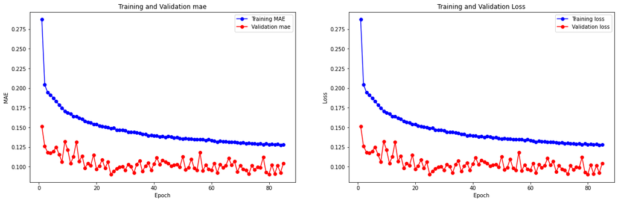

```
3852/3852 ━━━━━━━━━━━━━━━━━━━━ 2s 290us/step - loss: 0.1411 - mae: 0.1411
963/963 ━━━━━━━━━━━━━━━━━━━━ 1s 302us/step - loss: 0.0875 - mae: 0.0875
990/990 ━━━━━━━━━━━━━━━━━━━━ 0s 477us/step - loss: 0.1005 - mae: 0.1005
```

```
Training MAE: 79973.59589502525
```

```
Validation MAE: 51655.37228418588
```

```python
plot(history)
train_MAE = model.evaluate(trainData)[-1] * stdSales
val_MAE = model.evaluate(valData)[-1] * stdSales
test_MAE = model.evaluate(testData)[-1] * stdSales
print(f"Training MAE: {train_MAE}")
print(f"Validation MAE: {val_MAE}")

save_model_results(val_results_path, model_name, val_MAE)
save_model_results(test_results_path, model_name, test_MAE)
```

### **Results discussion**

Despite it's simplicity, in this first GRU model it can be observed **the best validation MAE so far**, which makes GRUs quite promising. Now, we are going to increase the complexity of the GRU models, trying to obtain better results.

## **Medium Complex GRU**

### Building Model

```python
model_name = "mid_complex_GRU"
```

```python
inputs = keras.Input(shape=(seqLength, nFeatures))
x = layers.GRU(10, activation='relu',return_sequences=True)(inputs)
x = layers.GRU(10, activation='relu')(x)
x = layers.Dense(32, activation='relu')(x)
outputs = layers.Dense(1)(x)
model = keras.Model(inputs, outputs)

model.compile(optimizer="adam", loss="mean_absolute_error", metrics=["mae"])
model.summary()
```

```
Model: "functional_21"
```

```
┏━━━━━━━━━━━━━━━━━━━━━━━━━━━━━━━━━┳━━━━━━━━━━━━━━━━━━━━━━━━━━━┳━━━━━━━━━━━━┓
┃ Layer (type)                    ┃ Output Shape              ┃    Param # ┃
┡━━━━━━━━━━━━━━━━━━━━━━━━━━━━━━━━━╇━━━━━━━━━━━━━━━━━━━━━━━━━━━╇━━━━━━━━━━━━┩
│ input_layer_10 (InputLayer)     │ (None, 3, 6)              │          0 │
├─────────────────────────────────┼───────────────────────────┼────────────┤
│ gru_2 (GRU)                     │ (None, 3, 10)             │        540 │
├─────────────────────────────────┼───────────────────────────┼────────────┤
│ gru_3 (GRU)                     │ (None, 10)                │        660 │
├─────────────────────────────────┼───────────────────────────┼────────────┤
│ dense_10 (Dense)                │ (None, 32)                │        352 │
├─────────────────────────────────┼───────────────────────────┼────────────┤
│ dense_11 (Dense)                │ (None, 1)                 │         33 │
└─────────────────────────────────┴───────────────────────────┴────────────┘
```

```
 Total params: 1,585 (6.19 KB)
```

```
 Trainable params: 1,585 (6.19 KB)
```

```
 Non-trainable params: 0 (0.00 B)
```

### Training

```python
# Initialize the EarlyStopping callback
early_stopping = EarlyStopping(
    monitor='val_loss',
    patience=60,
    restore_best_weights=True
)

# Train the model with the EarlyStopping callback
history = model.fit(
    trainData,
    epochs=500,
    batch_size=batchSize,
    validation_data=valData,
    callbacks=[early_stopping]  # Add the EarlyStopping callback to the callbacks list
)
```

```
3852/3852 ━━━━━━━━━━━━━━━━━━━━ 6s 964us/step - loss: 0.4023 - mae: 0.4023 - val_loss: 0.1627 - val_mae: 0.1627
3852/3852 ━━━━━━━━━━━━━━━━━━━━ 4s 891us/step - loss: 0.2079 - mae: 0.2079 - val_loss: 0.1367 - val_mae: 0.1367
3852/3852 ━━━━━━━━━━━━━━━━━━━━ 4s 901us/step - loss: 0.1981 - mae: 0.1981 - val_loss: 0.1900 - val_mae: 0.1900
3852/3852 ━━━━━━━━━━━━━━━━━━━━ 4s 914us/step - loss: 0.1997 - mae: 0.1997 - val_loss: 0.1373 - val_mae: 0.1373
3852/3852 ━━━━━━━━━━━━━━━━━━━━ 4s 888us/step - loss: 0.1848 - mae: 0.1848 - val_loss: 0.1107 - val_mae: 0.1107
3852/3852 ━━━━━━━━━━━━━━━━━━━━ 4s 891us/step - loss: 0.1803 - mae: 0.1803 - val_loss: 0.1141 - val_mae: 0.1141
3852/3852 ━━━━━━━━━━━━━━━━━━━━ 4s 900us/step - loss: 0.1815 - mae: 0.1815 - val_loss: 0.1190 - val_mae: 0.1190
3852/3852 ━━━━━━━━━━━━━━━━━━━━ 4s 924us/step - loss: 0.1674 - mae: 0.1674 - val_loss: 0.1307 - val_mae: 0.1307
3852/3852 ━━━━━━━━━━━━━━━━━━━━ 4s 934us/step - loss: 0.1746 - mae: 0.1746 - val_loss: 0.1079 - val_mae: 0.1079
3852/3852 ━━━━━━━━━━━━━━━━━━━━ 4s 897us/step - loss: 0.1698 - mae: 0.1698 - val_loss: 0.1354 - val_mae: 0.1354
3852/3852 ━━━━━━━━━━━━━━━━━━━━ 4s 892us/step - loss: 0.1701 - mae: 0.1701 - val_loss: 0.1222 - val_mae: 0.1222
3852/3852 ━━━━━━━━━━━━━━━━━━━━ 4s 911us/step - loss: 0.1620 - mae: 0.1620 - val_loss: 0.1088 - val_mae: 0.1088
3852/3852 ━━━━━━━━━━━━━━━━━━━━ 4s 897us/step - loss: 0.1641 - mae: 0.1641 - val_loss: 0.1076 - val_mae: 0.1076
3852/3852 ━━━━━━━━━━━━━━━━━━━━ 4s 908us/step - loss: 0.1584 - mae: 0.1584 - val_loss: 0.1077 - val_mae: 0.1077
3852/3852 ━━━━━━━━━━━━━━━━━━━━ 4s 923us/step - loss: 0.1564 - mae: 0.1564 - val_loss: 0.1115 - val_mae: 0.1115
3852/3852 ━━━━━━━━━━━━━━━━━━━━ 4s 892us/step - loss: 0.1580 - mae: 0.1580 - val_loss: 0.1008 - val_mae: 0.1008
3852/3852 ━━━━━━━━━━━━━━━━━━━━ 4s 941us/step - loss: 0.1626 - mae: 0.1626 - val_loss: 0.0978 - val_mae: 0.0978
3852/3852 ━━━━━━━━━━━━━━━━━━━━ 4s 925us/step - loss: 0.1602 - mae: 0.1602 - val_loss: 0.1055 - val_mae: 0.1055
3852/3852 ━━━━━━━━━━━━━━━━━━━━ 4s 931us/step - loss: 0.1477 - mae: 0.1477 - val_loss: 0.1077 - val_mae: 0.1077
3852/3852 ━━━━━━━━━━━━━━━━━━━━ 4s 926us/step - loss: 0.1544 - mae: 0.1544 - val_loss: 0.1067 - val_mae: 0.1067
3852/3852 ━━━━━━━━━━━━━━━━━━━━ 4s 893us/step - loss: 0.1507 - mae: 0.1507 - val_loss: 0.1093 - val_mae: 0.1093
3852/3852 ━━━━━━━━━━━━━━━━━━━━ 4s 889us/step - loss: 0.1477 - mae: 0.1477 - val_loss: 0.1114 - val_mae: 0.1114
3852/3852 ━━━━━━━━━━━━━━━━━━━━ 4s 877us/step - loss: 0.1461 - mae: 0.1461 - val_loss: 0.1007 - val_mae: 0.1007
3852/3852 ━━━━━━━━━━━━━━━━━━━━ 4s 877us/step - loss: 0.1467 - mae: 0.1467 - val_loss: 0.1014 - val_mae: 0.1014
3852/3852 ━━━━━━━━━━━━━━━━━━━━ 4s 899us/step - loss: 0.1493 - mae: 0.1493 - val_loss: 0.1030 - val_mae: 0.1030
3852/3852 ━━━━━━━━━━━━━━━━━━━━ 4s 865us/step - loss: 0.1434 - mae: 0.1434 - val_loss: 0.1114 - val_mae: 0.1114
3852/3852 ━━━━━━━━━━━━━━━━━━━━ 4s 878us/step - loss: 0.1445 - mae: 0.1445 - val_loss: 0.1048 - val_mae: 0.1048
3852/3852 ━━━━━━━━━━━━━━━━━━━━ 4s 896us/step - loss: 0.1418 - mae: 0.1418 - val_loss: 0.1009 - val_mae: 0.1009
3852/3852 ━━━━━━━━━━━━━━━━━━━━ 4s 880us/step - loss: 0.1443 - mae: 0.1443 - val_loss: 0.0992 - val_mae: 0.0992
3852/3852 ━━━━━━━━━━━━━━━━━━━━ 4s 881us/step - loss: 0.1411 - mae: 0.1411 - val_loss: 0.1106 - val_mae: 0.1106
3852/3852 ━━━━━━━━━━━━━━━━━━━━ 4s 892us/step - loss: 0.1362 - mae: 0.1362 - val_loss: 0.0952 - val_mae: 0.0952
3852/3852 ━━━━━━━━━━━━━━━━━━━━ 4s 882us/step - loss: 0.1382 - mae: 0.1382 - val_loss: 0.1325 - val_mae: 0.1325
3852/3852 ━━━━━━━━━━━━━━━━━━━━ 4s 890us/step - loss: 0.1475 - mae: 0.1475 - val_loss: 0.1188 - val_mae: 0.1188
3852/3852 ━━━━━━━━━━━━━━━━━━━━ 4s 897us/step - loss: 0.1409 - mae: 0.1409 - val_loss: 0.0978 - val_mae: 0.0978
3852/3852 ━━━━━━━━━━━━━━━━━━━━ 4s 864us/step - loss: 0.1382 - mae: 0.1382 - val_loss: 0.1259 - val_mae: 0.1259
3852/3852 ━━━━━━━━━━━━━━━━━━━━ 4s 886us/step - loss: 0.1394 - mae: 0.1394 - val_loss: 0.1110 - val_mae: 0.1110
3852/3852 ━━━━━━━━━━━━━━━━━━━━ 4s 891us/step - loss: 0.1357 - mae: 0.1357 - val_loss: 0.0985 - val_mae: 0.0985
3852/3852 ━━━━━━━━━━━━━━━━━━━━ 4s 884us/step - loss: 0.1344 - mae: 0.1344 - val_loss: 0.0973 - val_mae: 0.0973
3852/3852 ━━━━━━━━━━━━━━━━━━━━ 4s 919us/step - loss: 0.1365 - mae: 0.1365 - val_loss: 0.1175 - val_mae: 0.1175
3852/3852 ━━━━━━━━━━━━━━━━━━━━ 4s 926us/step - loss: 0.1352 - mae: 0.1352 - val_loss: 0.0987 - val_mae: 0.0987
```

[output cut: 50 more lines]

```
3852/3852 ━━━━━━━━━━━━━━━━━━━━ 4s 914us/step - loss: 0.1262 - mae: 0.1262 - val_loss: 0.0999 - val_mae: 0.0999
3852/3852 ━━━━━━━━━━━━━━━━━━━━ 4s 888us/step - loss: 0.1254 - mae: 0.1254 - val_loss: 0.0990 - val_mae: 0.0990
3852/3852 ━━━━━━━━━━━━━━━━━━━━ 4s 908us/step - loss: 0.1274 - mae: 0.1274 - val_loss: 0.1125 - val_mae: 0.1125
3852/3852 ━━━━━━━━━━━━━━━━━━━━ 4s 904us/step - loss: 0.1242 - mae: 0.1242 - val_loss: 0.1108 - val_mae: 0.1108
3852/3852 ━━━━━━━━━━━━━━━━━━━━ 4s 921us/step - loss: 0.1238 - mae: 0.1238 - val_loss: 0.1005 - val_mae: 0.1005
3852/3852 ━━━━━━━━━━━━━━━━━━━━ 4s 885us/step - loss: 0.1210 - mae: 0.1210 - val_loss: 0.1074 - val_mae: 0.1074
3852/3852 ━━━━━━━━━━━━━━━━━━━━ 4s 908us/step - loss: 0.1206 - mae: 0.1206 - val_loss: 0.1012 - val_mae: 0.1012
3852/3852 ━━━━━━━━━━━━━━━━━━━━ 4s 901us/step - loss: 0.1279 - mae: 0.1279 - val_loss: 0.1016 - val_mae: 0.1016
3852/3852 ━━━━━━━━━━━━━━━━━━━━ 4s 919us/step - loss: 0.1239 - mae: 0.1239 - val_loss: 0.1085 - val_mae: 0.1085
3852/3852 ━━━━━━━━━━━━━━━━━━━━ 4s 915us/step - loss: 0.1223 - mae: 0.1223 - val_loss: 0.1068 - val_mae: 0.1068
3852/3852 ━━━━━━━━━━━━━━━━━━━━ 4s 939us/step - loss: 0.1250 - mae: 0.1250 - val_loss: 0.1099 - val_mae: 0.1099
3852/3852 ━━━━━━━━━━━━━━━━━━━━ 4s 880us/step - loss: 0.1226 - mae: 0.1226 - val_loss: 0.1004 - val_mae: 0.1004
3852/3852 ━━━━━━━━━━━━━━━━━━━━ 4s 894us/step - loss: 0.1205 - mae: 0.1205 - val_loss: 0.1044 - val_mae: 0.1044
3852/3852 ━━━━━━━━━━━━━━━━━━━━ 4s 878us/step - loss: 0.1256 - mae: 0.1256 - val_loss: 0.1027 - val_mae: 0.1027
3852/3852 ━━━━━━━━━━━━━━━━━━━━ 4s 919us/step - loss: 0.1258 - mae: 0.1258 - val_loss: 0.1103 - val_mae: 0.1103
```

### Evaluation

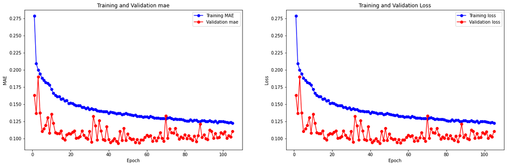

```
3852/3852 ━━━━━━━━━━━━━━━━━━━━ 2s 316us/step - loss: 0.1319 - mae: 0.1319
963/963 ━━━━━━━━━━━━━━━━━━━━ 1s 307us/step - loss: 0.0998 - mae: 0.0998
990/990 ━━━━━━━━━━━━━━━━━━━━ 0s 475us/step - loss: 0.1083 - mae: 0.1083
```

```
Training MAE: 75635.02699691859
```

```
Validation MAE: 53227.30080326533
```

```python
plot(history)
train_MAE = model.evaluate(trainData)[-1] * stdSales
val_MAE = model.evaluate(valData)[-1] * stdSales
test_MAE = model.evaluate(testData)[-1] * stdSales
print(f"Training MAE: {train_MAE}")
print(f"Validation MAE: {val_MAE}")

save_model_results(val_results_path, model_name, val_MAE)
save_model_results(test_results_path, model_name, test_MAE)
```

### **Results discussion**

In this second model, while training MAE has improved, validation results are **slightly worse** than in the previous model, so adding a dense layer does not seem to have helped to improve the results.

## **Complex GRU - Low L2 Regularization**

### Building Model

```python
model_name = "complex_GRU_L2"
```

```python
inputs = Input(shape=(seqLength, nFeatures))

x = layers.GRU(units=32, activation='relu', return_sequences=True,
              kernel_regularizer=l2(0.00001), recurrent_regularizer=l2(0.00001))(inputs)

x = layers.GRU(units=64, activation='relu', return_sequences=True,
              kernel_regularizer=l2(0.00001), recurrent_regularizer=l2(0.00001))(x)

x = layers.GRU(units=128, activation='relu', return_sequences=True,
              kernel_regularizer=l2(0.00001), recurrent_regularizer=l2(0.00001))(x)

x = layers.GRU(units=256, activation='relu', return_sequences=True,
              kernel_regularizer=l2(0.00001), recurrent_regularizer=l2(0.00001))(x)

x = layers.GRU(units=64, activation='relu', kernel_regularizer=l2(0.00001), recurrent_regularizer=l2(0.00001))(x)

outputs = Dense(1)(x)

model = Model(inputs=inputs, outputs=outputs)
model.compile(optimizer='adam', loss='mean_absolute_error', metrics=['mae'])
model.summary()
```

```
Model: "functional_23"
```

```
┏━━━━━━━━━━━━━━━━━━━━━━━━━━━━━━━━━┳━━━━━━━━━━━━━━━━━━━━━━━━━━━┳━━━━━━━━━━━━┓
┃ Layer (type)                    ┃ Output Shape              ┃    Param # ┃
┡━━━━━━━━━━━━━━━━━━━━━━━━━━━━━━━━━╇━━━━━━━━━━━━━━━━━━━━━━━━━━━╇━━━━━━━━━━━━┩
│ input_layer_11 (InputLayer)     │ (None, 3, 6)              │          0 │
├─────────────────────────────────┼───────────────────────────┼────────────┤
│ gru_4 (GRU)                     │ (None, 3, 32)             │      3,840 │
├─────────────────────────────────┼───────────────────────────┼────────────┤
│ gru_5 (GRU)                     │ (None, 3, 64)             │     18,816 │
├─────────────────────────────────┼───────────────────────────┼────────────┤
│ gru_6 (GRU)                     │ (None, 3, 128)            │     74,496 │
├─────────────────────────────────┼───────────────────────────┼────────────┤
│ gru_7 (GRU)                     │ (None, 3, 256)            │    296,448 │
├─────────────────────────────────┼───────────────────────────┼────────────┤
│ gru_8 (GRU)                     │ (None, 64)                │     61,824 │
├─────────────────────────────────┼───────────────────────────┼────────────┤
│ dense_12 (Dense)                │ (None, 1)                 │         65 │
└─────────────────────────────────┴───────────────────────────┴────────────┘
```

```
 Total params: 455,489 (1.74 MB)
```

```
 Trainable params: 455,489 (1.74 MB)
```

```
 Non-trainable params: 0 (0.00 B)
```

### Training

```python
# Initialize the EarlyStopping callback
early_stopping = EarlyStopping(
    monitor='val_loss',
    patience=60,
    restore_best_weights=True
)

# Train the model with the EarlyStopping callback
history = model.fit(
    trainData,
    epochs=500,
    batch_size=batchSize,
    validation_data=valData,
    callbacks=[early_stopping]  # Add the EarlyStopping callback to the callbacks list
)
```

```
3852/3852 ━━━━━━━━━━━━━━━━━━━━ 10s 2ms/step - loss: 0.3762 - mae: 0.3722 - val_loss: 0.1422 - val_mae: 0.1386
3852/3852 ━━━━━━━━━━━━━━━━━━━━ 6s 1ms/step - loss: 0.2336 - mae: 0.2300 - val_loss: 0.1497 - val_mae: 0.1461
3852/3852 ━━━━━━━━━━━━━━━━━━━━ 6s 1ms/step - loss: 0.2228 - mae: 0.2192 - val_loss: 0.1382 - val_mae: 0.1348
3852/3852 ━━━━━━━━━━━━━━━━━━━━ 6s 1ms/step - loss: 0.2076 - mae: 0.2041 - val_loss: 0.1305 - val_mae: 0.1272
3852/3852 ━━━━━━━━━━━━━━━━━━━━ 6s 1ms/step - loss: 0.2055 - mae: 0.2023 - val_loss: 0.1705 - val_mae: 0.1674
3852/3852 ━━━━━━━━━━━━━━━━━━━━ 6s 1ms/step - loss: 0.2056 - mae: 0.2025 - val_loss: 0.1181 - val_mae: 0.1151
3852/3852 ━━━━━━━━━━━━━━━━━━━━ 6s 1ms/step - loss: 0.1952 - mae: 0.1922 - val_loss: 0.1216 - val_mae: 0.1187
3852/3852 ━━━━━━━━━━━━━━━━━━━━ 6s 1ms/step - loss: 0.1997 - mae: 0.1968 - val_loss: 0.1222 - val_mae: 0.1192
3852/3852 ━━━━━━━━━━━━━━━━━━━━ 6s 1ms/step - loss: 0.1821 - mae: 0.1792 - val_loss: 0.1178 - val_mae: 0.1148
3852/3852 ━━━━━━━━━━━━━━━━━━━━ 6s 1ms/step - loss: 0.1822 - mae: 0.1792 - val_loss: 0.1201 - val_mae: 0.1170
3852/3852 ━━━━━━━━━━━━━━━━━━━━ 6s 1ms/step - loss: 0.1821 - mae: 0.1789 - val_loss: 0.1108 - val_mae: 0.1076
3852/3852 ━━━━━━━━━━━━━━━━━━━━ 6s 1ms/step - loss: 0.1897 - mae: 0.1864 - val_loss: 0.1152 - val_mae: 0.1118
3852/3852 ━━━━━━━━━━━━━━━━━━━━ 6s 1ms/step - loss: 0.1786 - mae: 0.1752 - val_loss: 0.1248 - val_mae: 0.1213
3852/3852 ━━━━━━━━━━━━━━━━━━━━ 6s 1ms/step - loss: 0.1770 - mae: 0.1735 - val_loss: 0.1310 - val_mae: 0.1274
3852/3852 ━━━━━━━━━━━━━━━━━━━━ 6s 1ms/step - loss: 0.1696 - mae: 0.1659 - val_loss: 0.1154 - val_mae: 0.1116
3852/3852 ━━━━━━━━━━━━━━━━━━━━ 7s 2ms/step - loss: 0.1671 - mae: 0.1633 - val_loss: 0.1162 - val_mae: 0.1124
3852/3852 ━━━━━━━━━━━━━━━━━━━━ 6s 1ms/step - loss: 0.1673 - mae: 0.1635 - val_loss: 0.1385 - val_mae: 0.1347
3852/3852 ━━━━━━━━━━━━━━━━━━━━ 6s 1ms/step - loss: 0.1638 - mae: 0.1600 - val_loss: 0.1319 - val_mae: 0.1280
3852/3852 ━━━━━━━━━━━━━━━━━━━━ 6s 1ms/step - loss: 0.1613 - mae: 0.1574 - val_loss: 0.1116 - val_mae: 0.1077
3852/3852 ━━━━━━━━━━━━━━━━━━━━ 6s 1ms/step - loss: 0.1648 - mae: 0.1609 - val_loss: 0.1219 - val_mae: 0.1180
3852/3852 ━━━━━━━━━━━━━━━━━━━━ 6s 1ms/step - loss: 0.1612 - mae: 0.1573 - val_loss: 0.1145 - val_mae: 0.1106
3852/3852 ━━━━━━━━━━━━━━━━━━━━ 6s 1ms/step - loss: 0.1634 - mae: 0.1595 - val_loss: 0.1183 - val_mae: 0.1143
3852/3852 ━━━━━━━━━━━━━━━━━━━━ 6s 1ms/step - loss: 0.1593 - mae: 0.1554 - val_loss: 0.1144 - val_mae: 0.1105
3852/3852 ━━━━━━━━━━━━━━━━━━━━ 6s 1ms/step - loss: 0.1576 - mae: 0.1537 - val_loss: 0.1293 - val_mae: 0.1254
3852/3852 ━━━━━━━━━━━━━━━━━━━━ 6s 1ms/step - loss: 0.1561 - mae: 0.1522 - val_loss: 0.1191 - val_mae: 0.1151
3852/3852 ━━━━━━━━━━━━━━━━━━━━ 6s 1ms/step - loss: 0.1578 - mae: 0.1537 - val_loss: 0.1153 - val_mae: 0.1113
3852/3852 ━━━━━━━━━━━━━━━━━━━━ 6s 1ms/step - loss: 0.1527 - mae: 0.1486 - val_loss: 0.1085 - val_mae: 0.1044
3852/3852 ━━━━━━━━━━━━━━━━━━━━ 6s 1ms/step - loss: 0.1517 - mae: 0.1476 - val_loss: 0.1186 - val_mae: 0.1145
3852/3852 ━━━━━━━━━━━━━━━━━━━━ 6s 1ms/step - loss: 0.1571 - mae: 0.1529 - val_loss: 0.1305 - val_mae: 0.1263
3852/3852 ━━━━━━━━━━━━━━━━━━━━ 6s 1ms/step - loss: 0.1470 - mae: 0.1428 - val_loss: 0.1226 - val_mae: 0.1183
3852/3852 ━━━━━━━━━━━━━━━━━━━━ 6s 1ms/step - loss: 0.1534 - mae: 0.1491 - val_loss: 0.1236 - val_mae: 0.1193
3852/3852 ━━━━━━━━━━━━━━━━━━━━ 6s 2ms/step - loss: 0.1551 - mae: 0.1507 - val_loss: 0.1152 - val_mae: 0.1108
3852/3852 ━━━━━━━━━━━━━━━━━━━━ 6s 1ms/step - loss: 0.1492 - mae: 0.1448 - val_loss: 0.1251 - val_mae: 0.1206
3852/3852 ━━━━━━━━━━━━━━━━━━━━ 6s 1ms/step - loss: 0.1524 - mae: 0.1480 - val_loss: 0.1453 - val_mae: 0.1408
3852/3852 ━━━━━━━━━━━━━━━━━━━━ 6s 1ms/step - loss: 0.1519 - mae: 0.1474 - val_loss: 0.1216 - val_mae: 0.1171
3852/3852 ━━━━━━━━━━━━━━━━━━━━ 6s 1ms/step - loss: 0.1542 - mae: 0.1497 - val_loss: 0.1351 - val_mae: 0.1305
3852/3852 ━━━━━━━━━━━━━━━━━━━━ 6s 1ms/step - loss: 0.1538 - mae: 0.1493 - val_loss: 0.1092 - val_mae: 0.1046
3852/3852 ━━━━━━━━━━━━━━━━━━━━ 6s 1ms/step - loss: 0.1418 - mae: 0.1372 - val_loss: 0.1392 - val_mae: 0.1346
3852/3852 ━━━━━━━━━━━━━━━━━━━━ 6s 1ms/step - loss: 0.1559 - mae: 0.1513 - val_loss: 0.1166 - val_mae: 0.1119
3852/3852 ━━━━━━━━━━━━━━━━━━━━ 6s 1ms/step - loss: 0.1486 - mae: 0.1439 - val_loss: 0.1201 - val_mae: 0.1153
```

[output cut: 32 more lines]

```
3852/3852 ━━━━━━━━━━━━━━━━━━━━ 6s 1ms/step - loss: 0.1309 - mae: 0.1246 - val_loss: 0.1196 - val_mae: 0.1133
3852/3852 ━━━━━━━━━━━━━━━━━━━━ 6s 1ms/step - loss: 0.1299 - mae: 0.1235 - val_loss: 0.1498 - val_mae: 0.1434
3852/3852 ━━━━━━━━━━━━━━━━━━━━ 6s 1ms/step - loss: 0.1306 - mae: 0.1242 - val_loss: 0.1234 - val_mae: 0.1169
3852/3852 ━━━━━━━━━━━━━━━━━━━━ 6s 1ms/step - loss: 0.1317 - mae: 0.1253 - val_loss: 0.1321 - val_mae: 0.1256
3852/3852 ━━━━━━━━━━━━━━━━━━━━ 6s 1ms/step - loss: 0.1317 - mae: 0.1251 - val_loss: 0.1249 - val_mae: 0.1183
3852/3852 ━━━━━━━━━━━━━━━━━━━━ 6s 1ms/step - loss: 0.1290 - mae: 0.1224 - val_loss: 0.1253 - val_mae: 0.1187
3852/3852 ━━━━━━━━━━━━━━━━━━━━ 6s 1ms/step - loss: 0.1300 - mae: 0.1234 - val_loss: 0.1256 - val_mae: 0.1189
3852/3852 ━━━━━━━━━━━━━━━━━━━━ 6s 1ms/step - loss: 0.1288 - mae: 0.1221 - val_loss: 0.1444 - val_mae: 0.1377
3852/3852 ━━━━━━━━━━━━━━━━━━━━ 6s 1ms/step - loss: 0.1289 - mae: 0.1222 - val_loss: 0.1194 - val_mae: 0.1126
3852/3852 ━━━━━━━━━━━━━━━━━━━━ 6s 1ms/step - loss: 0.1242 - mae: 0.1174 - val_loss: 0.1285 - val_mae: 0.1217
3852/3852 ━━━━━━━━━━━━━━━━━━━━ 6s 1ms/step - loss: 0.1287 - mae: 0.1219 - val_loss: 0.1187 - val_mae: 0.1119
3852/3852 ━━━━━━━━━━━━━━━━━━━━ 6s 1ms/step - loss: 0.1250 - mae: 0.1182 - val_loss: 0.1171 - val_mae: 0.1102
3852/3852 ━━━━━━━━━━━━━━━━━━━━ 6s 1ms/step - loss: 0.1248 - mae: 0.1180 - val_loss: 0.1271 - val_mae: 0.1203
3852/3852 ━━━━━━━━━━━━━━━━━━━━ 6s 1ms/step - loss: 0.1207 - mae: 0.1138 - val_loss: 0.1141 - val_mae: 0.1072
3852/3852 ━━━━━━━━━━━━━━━━━━━━ 6s 1ms/step - loss: 0.1252 - mae: 0.1183 - val_loss: 0.1286 - val_mae: 0.1216
```

### Evaluation

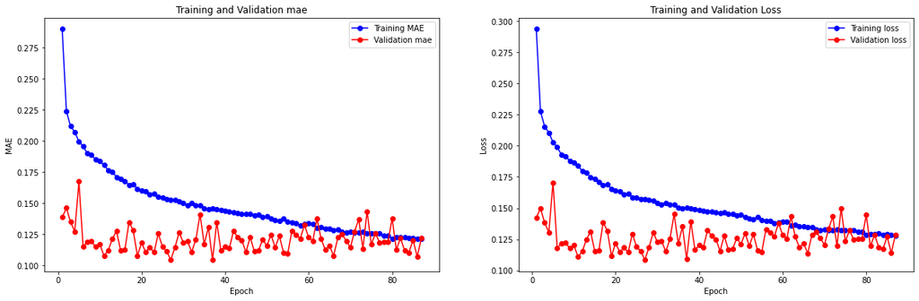

```
3852/3852 ━━━━━━━━━━━━━━━━━━━━ 2s 394us/step - loss: 0.1528 - mae: 0.1487
963/963 ━━━━━━━━━━━━━━━━━━━━ 1s 424us/step - loss: 0.1044 - mae: 0.1003
990/990 ━━━━━━━━━━━━━━━━━━━━ 1s 531us/step - loss: 0.1175 - mae: 0.1134
```

```
Training MAE: 83706.85422936801
```

```
Validation MAE: 59718.66543442781
```

```python
plot(history)
train_MAE = model.evaluate(trainData)[-1] * stdSales
val_MAE = model.evaluate(valData)[-1] * stdSales
test_MAE = model.evaluate(testData)[-1] * stdSales
print(f"Training MAE: {train_MAE}")
print(f"Validation MAE: {val_MAE}")

save_model_results(val_results_path, model_name, val_MAE)
save_model_results(test_results_path, model_name, test_MAE)
```

### **Results discussion**

In this model we have decided to try a model with some more layer, but adding a rather **low L2 regularization**, which in other previous models has obtained acceptable results, in comparison with **Dropout**, which obtains much worse results. The result obtained is within what we expected, and comparing with the two previous models, this is the one that seems to work **worse**. Once more, the model seems **too sensitive to regularization**, slightly worsening the results.

## GRU

### Building the Model

```python
model_name = "bidirectional_SimpleGRU"
```

```python
inputs = keras.Input(shape=(seqLength, nFeatures))
x = layers.Bidirectional(layers.GRU(10, activation='relu',return_sequences=True))(inputs)
x = layers.Bidirectional(layers.GRU(10, activation='relu'))(x)
outputs = layers.Dense(1)(x)
model = keras.Model(inputs, outputs)

model.compile(optimizer="adam", loss="mean_absolute_error", metrics=["mae"])
model.summary()
```

```
Model: "functional_25"
```

```
┏━━━━━━━━━━━━━━━━━━━━━━━━━━━━━━━━━┳━━━━━━━━━━━━━━━━━━━━━━━━━━━┳━━━━━━━━━━━━┓
┃ Layer (type)                    ┃ Output Shape              ┃    Param # ┃
┡━━━━━━━━━━━━━━━━━━━━━━━━━━━━━━━━━╇━━━━━━━━━━━━━━━━━━━━━━━━━━━╇━━━━━━━━━━━━┩
│ input_layer_12 (InputLayer)     │ (None, 3, 6)              │          0 │
├─────────────────────────────────┼───────────────────────────┼────────────┤
│ bidirectional (Bidirectional)   │ (None, 3, 20)             │      1,080 │
├─────────────────────────────────┼───────────────────────────┼────────────┤
│ bidirectional_1 (Bidirectional) │ (None, 20)                │      1,920 │
├─────────────────────────────────┼───────────────────────────┼────────────┤
│ dense_13 (Dense)                │ (None, 1)                 │         21 │
└─────────────────────────────────┴───────────────────────────┴────────────┘
```

```
 Total params: 3,021 (11.80 KB)
```

```
 Trainable params: 3,021 (11.80 KB)
```

```
 Non-trainable params: 0 (0.00 B)
```

### Training

```python
# Initialize the EarlyStopping callback
early_stopping = EarlyStopping(
    monitor='val_loss',
    patience=60,
    restore_best_weights=True
)

# Train the model with the EarlyStopping callback
history = model.fit(
    trainData,
    epochs=500,
    batch_size=batchSize,
    validation_data=valData,
    callbacks=[early_stopping]  # Add the EarlyStopping callback to the callbacks list
)
```

```
3852/3852 ━━━━━━━━━━━━━━━━━━━━ 8s 1ms/step - loss: 0.3324 - mae: 0.3324 - val_loss: 0.1413 - val_mae: 0.1413
3852/3852 ━━━━━━━━━━━━━━━━━━━━ 5s 1ms/step - loss: 0.2035 - mae: 0.2035 - val_loss: 0.1330 - val_mae: 0.1330
3852/3852 ━━━━━━━━━━━━━━━━━━━━ 5s 1ms/step - loss: 0.1962 - mae: 0.1962 - val_loss: 0.1277 - val_mae: 0.1277
3852/3852 ━━━━━━━━━━━━━━━━━━━━ 5s 1ms/step - loss: 0.1986 - mae: 0.1986 - val_loss: 0.1184 - val_mae: 0.1184
3852/3852 ━━━━━━━━━━━━━━━━━━━━ 5s 1ms/step - loss: 0.1880 - mae: 0.1880 - val_loss: 0.1485 - val_mae: 0.1485
3852/3852 ━━━━━━━━━━━━━━━━━━━━ 5s 1ms/step - loss: 0.1770 - mae: 0.1770 - val_loss: 0.1211 - val_mae: 0.1211
3852/3852 ━━━━━━━━━━━━━━━━━━━━ 5s 1ms/step - loss: 0.1734 - mae: 0.1734 - val_loss: 0.1022 - val_mae: 0.1022
3852/3852 ━━━━━━━━━━━━━━━━━━━━ 5s 1ms/step - loss: 0.1687 - mae: 0.1687 - val_loss: 0.0990 - val_mae: 0.0990
3852/3852 ━━━━━━━━━━━━━━━━━━━━ 5s 1ms/step - loss: 0.1650 - mae: 0.1650 - val_loss: 0.0995 - val_mae: 0.0995
3852/3852 ━━━━━━━━━━━━━━━━━━━━ 5s 1ms/step - loss: 0.1615 - mae: 0.1615 - val_loss: 0.1037 - val_mae: 0.1037
3852/3852 ━━━━━━━━━━━━━━━━━━━━ 5s 1ms/step - loss: 0.1620 - mae: 0.1620 - val_loss: 0.1006 - val_mae: 0.1006
3852/3852 ━━━━━━━━━━━━━━━━━━━━ 5s 1ms/step - loss: 0.1576 - mae: 0.1576 - val_loss: 0.1004 - val_mae: 0.1004
3852/3852 ━━━━━━━━━━━━━━━━━━━━ 5s 1ms/step - loss: 0.1595 - mae: 0.1595 - val_loss: 0.0976 - val_mae: 0.0976
3852/3852 ━━━━━━━━━━━━━━━━━━━━ 5s 1ms/step - loss: 0.1548 - mae: 0.1548 - val_loss: 0.1082 - val_mae: 0.1082
3852/3852 ━━━━━━━━━━━━━━━━━━━━ 5s 1ms/step - loss: 0.1558 - mae: 0.1558 - val_loss: 0.0916 - val_mae: 0.0916
3852/3852 ━━━━━━━━━━━━━━━━━━━━ 5s 1ms/step - loss: 0.1497 - mae: 0.1497 - val_loss: 0.1059 - val_mae: 0.1059
3852/3852 ━━━━━━━━━━━━━━━━━━━━ 5s 1ms/step - loss: 0.1527 - mae: 0.1527 - val_loss: 0.1009 - val_mae: 0.1009
3852/3852 ━━━━━━━━━━━━━━━━━━━━ 5s 1ms/step - loss: 0.1491 - mae: 0.1491 - val_loss: 0.0934 - val_mae: 0.0934
3852/3852 ━━━━━━━━━━━━━━━━━━━━ 5s 1ms/step - loss: 0.1487 - mae: 0.1487 - val_loss: 0.0961 - val_mae: 0.0961
3852/3852 ━━━━━━━━━━━━━━━━━━━━ 5s 1ms/step - loss: 0.1422 - mae: 0.1422 - val_loss: 0.1068 - val_mae: 0.1068
3852/3852 ━━━━━━━━━━━━━━━━━━━━ 5s 1ms/step - loss: 0.1480 - mae: 0.1480 - val_loss: 0.1036 - val_mae: 0.1036
3852/3852 ━━━━━━━━━━━━━━━━━━━━ 5s 1ms/step - loss: 0.1415 - mae: 0.1415 - val_loss: 0.1100 - val_mae: 0.1100
3852/3852 ━━━━━━━━━━━━━━━━━━━━ 5s 1ms/step - loss: 0.1416 - mae: 0.1416 - val_loss: 0.0936 - val_mae: 0.0936
3852/3852 ━━━━━━━━━━━━━━━━━━━━ 5s 1ms/step - loss: 0.1400 - mae: 0.1400 - val_loss: 0.1043 - val_mae: 0.1043
3852/3852 ━━━━━━━━━━━━━━━━━━━━ 5s 1ms/step - loss: 0.1404 - mae: 0.1404 - val_loss: 0.1037 - val_mae: 0.1037
3852/3852 ━━━━━━━━━━━━━━━━━━━━ 5s 1ms/step - loss: 0.1369 - mae: 0.1369 - val_loss: 0.0939 - val_mae: 0.0939
3852/3852 ━━━━━━━━━━━━━━━━━━━━ 5s 1ms/step - loss: 0.1365 - mae: 0.1365 - val_loss: 0.0947 - val_mae: 0.0947
3852/3852 ━━━━━━━━━━━━━━━━━━━━ 5s 1ms/step - loss: 0.1328 - mae: 0.1328 - val_loss: 0.1014 - val_mae: 0.1014
3852/3852 ━━━━━━━━━━━━━━━━━━━━ 5s 1ms/step - loss: 0.1330 - mae: 0.1330 - val_loss: 0.0925 - val_mae: 0.0925
3852/3852 ━━━━━━━━━━━━━━━━━━━━ 5s 1ms/step - loss: 0.1302 - mae: 0.1302 - val_loss: 0.0968 - val_mae: 0.0968
3852/3852 ━━━━━━━━━━━━━━━━━━━━ 5s 1ms/step - loss: 0.1357 - mae: 0.1357 - val_loss: 0.1034 - val_mae: 0.1034
3852/3852 ━━━━━━━━━━━━━━━━━━━━ 5s 1ms/step - loss: 0.1270 - mae: 0.1270 - val_loss: 0.0992 - val_mae: 0.0992
3852/3852 ━━━━━━━━━━━━━━━━━━━━ 5s 1ms/step - loss: 0.1318 - mae: 0.1318 - val_loss: 0.1040 - val_mae: 0.1040
3852/3852 ━━━━━━━━━━━━━━━━━━━━ 5s 1ms/step - loss: 0.1324 - mae: 0.1324 - val_loss: 0.0947 - val_mae: 0.0947
3852/3852 ━━━━━━━━━━━━━━━━━━━━ 5s 1ms/step - loss: 0.1239 - mae: 0.1239 - val_loss: 0.1024 - val_mae: 0.1024
3852/3852 ━━━━━━━━━━━━━━━━━━━━ 5s 1ms/step - loss: 0.1314 - mae: 0.1314 - val_loss: 0.1114 - val_mae: 0.1114
3852/3852 ━━━━━━━━━━━━━━━━━━━━ 5s 1ms/step - loss: 0.1276 - mae: 0.1276 - val_loss: 0.0973 - val_mae: 0.0973
3852/3852 ━━━━━━━━━━━━━━━━━━━━ 5s 1ms/step - loss: 0.1247 - mae: 0.1247 - val_loss: 0.0999 - val_mae: 0.0999
3852/3852 ━━━━━━━━━━━━━━━━━━━━ 5s 1ms/step - loss: 0.1301 - mae: 0.1301 - val_loss: 0.0977 - val_mae: 0.0977
3852/3852 ━━━━━━━━━━━━━━━━━━━━ 5s 1ms/step - loss: 0.1321 - mae: 0.1321 - val_loss: 0.1005 - val_mae: 0.1005
```

[output cut: 20 more lines]

```
3852/3852 ━━━━━━━━━━━━━━━━━━━━ 5s 1ms/step - loss: 0.1243 - mae: 0.1243 - val_loss: 0.0944 - val_mae: 0.0944
3852/3852 ━━━━━━━━━━━━━━━━━━━━ 5s 1ms/step - loss: 0.1207 - mae: 0.1207 - val_loss: 0.1075 - val_mae: 0.1075
3852/3852 ━━━━━━━━━━━━━━━━━━━━ 5s 1ms/step - loss: 0.1196 - mae: 0.1196 - val_loss: 0.1042 - val_mae: 0.1042
3852/3852 ━━━━━━━━━━━━━━━━━━━━ 5s 1ms/step - loss: 0.1133 - mae: 0.1133 - val_loss: 0.0965 - val_mae: 0.0965
3852/3852 ━━━━━━━━━━━━━━━━━━━━ 5s 1ms/step - loss: 0.1145 - mae: 0.1145 - val_loss: 0.1002 - val_mae: 0.1002
3852/3852 ━━━━━━━━━━━━━━━━━━━━ 5s 1ms/step - loss: 0.1212 - mae: 0.1212 - val_loss: 0.0966 - val_mae: 0.0966
3852/3852 ━━━━━━━━━━━━━━━━━━━━ 5s 1ms/step - loss: 0.1183 - mae: 0.1183 - val_loss: 0.1010 - val_mae: 0.1010
3852/3852 ━━━━━━━━━━━━━━━━━━━━ 5s 1ms/step - loss: 0.1151 - mae: 0.1151 - val_loss: 0.1047 - val_mae: 0.1047
3852/3852 ━━━━━━━━━━━━━━━━━━━━ 5s 1ms/step - loss: 0.1190 - mae: 0.1190 - val_loss: 0.1006 - val_mae: 0.1006
3852/3852 ━━━━━━━━━━━━━━━━━━━━ 5s 1ms/step - loss: 0.1167 - mae: 0.1167 - val_loss: 0.1017 - val_mae: 0.1017
3852/3852 ━━━━━━━━━━━━━━━━━━━━ 5s 1ms/step - loss: 0.1112 - mae: 0.1112 - val_loss: 0.1003 - val_mae: 0.1003
3852/3852 ━━━━━━━━━━━━━━━━━━━━ 5s 1ms/step - loss: 0.1133 - mae: 0.1133 - val_loss: 0.1023 - val_mae: 0.1023
3852/3852 ━━━━━━━━━━━━━━━━━━━━ 5s 1ms/step - loss: 0.1117 - mae: 0.1117 - val_loss: 0.1006 - val_mae: 0.1006
3852/3852 ━━━━━━━━━━━━━━━━━━━━ 5s 1ms/step - loss: 0.1169 - mae: 0.1169 - val_loss: 0.1036 - val_mae: 0.1036
3852/3852 ━━━━━━━━━━━━━━━━━━━━ 5s 1ms/step - loss: 0.1126 - mae: 0.1126 - val_loss: 0.1067 - val_mae: 0.1067
```

### Evaluation

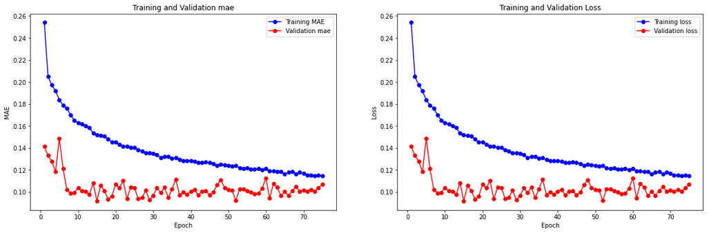

```
3852/3852 ━━━━━━━━━━━━━━━━━━━━ 2s 351us/step - loss: 0.1449 - mae: 0.1449
963/963 ━━━━━━━━━━━━━━━━━━━━ 1s 371us/step - loss: 0.0911 - mae: 0.0911
990/990 ━━━━━━━━━━━━━━━━━━━━ 1s 538us/step - loss: 0.1048 - mae: 0.1048
```

```
Training MAE: 82380.65870645302
```

```
Validation MAE: 52395.36199851343
```

```python
plot(history)
train_MAE = model.evaluate(trainData)[-1] * stdSales
val_MAE = model.evaluate(valData)[-1] * stdSales
test_MAE = model.evaluate(testData)[-1] * stdSales
print(f"Training MAE: {train_MAE}")
print(f"Validation MAE: {val_MAE}")

save_model_results(val_results_path, model_name, val_MAE)
save_model_results(test_results_path, model_name, test_MAE)
```

### **Results discussion**

In this model, we have tried to add bidirectional layers with the simple GRU model, the result obtained in both training and validation is within **acceptable** parameters. However, if we compare these results with the simple GRU model, it seems that the bidirectional one performs **worse** in the training and validation set.

## LSTM

### Building the model

```python
model_name = "bidirectional_complex_LSTM_L2"
```

```python
inputs = Input(shape=(seqLength, nFeatures))

x = layers.Bidirectional(LSTM(units=32, activation='relu', return_sequences=True,
              kernel_regularizer=l2(0.00001), recurrent_regularizer=l2(0.00001)))(inputs)

x = layers.Bidirectional(LSTM(units=64, activation='relu', return_sequences=True,
              kernel_regularizer=l2(0.00001), recurrent_regularizer=l2(0.00001)))(x)

x = layers.Bidirectional(LSTM(units=128, activation='relu', return_sequences=True,
              kernel_regularizer=l2(0.00001), recurrent_regularizer=l2(0.00001)))(x)

x = layers.Bidirectional(LSTM(units=64, activation='relu', kernel_regularizer=l2(0.00001), recurrent_regularizer=l2(0.00001)))(x)

outputs = Dense(1)(x)

model = Model(inputs=inputs, outputs=outputs)
model.compile(optimizer='adam', loss='mean_absolute_error', metrics=['mae'])
model.summary()
```

```
Model: "functional_27"
```

```
┏━━━━━━━━━━━━━━━━━━━━━━━━━━━━━━━━━┳━━━━━━━━━━━━━━━━━━━━━━━━━━━┳━━━━━━━━━━━━┓
┃ Layer (type)                    ┃ Output Shape              ┃    Param # ┃
┡━━━━━━━━━━━━━━━━━━━━━━━━━━━━━━━━━╇━━━━━━━━━━━━━━━━━━━━━━━━━━━╇━━━━━━━━━━━━┩
│ input_layer_13 (InputLayer)     │ (None, 3, 6)              │          0 │
├─────────────────────────────────┼───────────────────────────┼────────────┤
│ bidirectional_2 (Bidirectional) │ (None, 3, 64)             │      9,984 │
├─────────────────────────────────┼───────────────────────────┼────────────┤
│ bidirectional_3 (Bidirectional) │ (None, 3, 128)            │     66,048 │
├─────────────────────────────────┼───────────────────────────┼────────────┤
│ bidirectional_4 (Bidirectional) │ (None, 3, 256)            │    263,168 │
├─────────────────────────────────┼───────────────────────────┼────────────┤
│ bidirectional_5 (Bidirectional) │ (None, 128)               │    164,352 │
├─────────────────────────────────┼───────────────────────────┼────────────┤
│ dense_14 (Dense)                │ (None, 1)                 │        129 │
└─────────────────────────────────┴───────────────────────────┴────────────┘
```

```
 Total params: 503,681 (1.92 MB)
```

```
 Trainable params: 503,681 (1.92 MB)
```

```
 Non-trainable params: 0 (0.00 B)
```

### Training

```python
# Initialize the EarlyStopping callback
early_stopping = EarlyStopping(
    monitor='val_loss',
    patience=60,
    restore_best_weights=True
)

# Train the model with the EarlyStopping callback
history = model.fit(
    trainData,
    epochs=500,
    batch_size=batchSize,
    validation_data=valData,
    callbacks=[early_stopping]  # Add the EarlyStopping callback to the callbacks list
)
```

```
3852/3852 ━━━━━━━━━━━━━━━━━━━━ 15s 2ms/step - loss: 0.3789 - mae: 0.3718 - val_loss: 0.1575 - val_mae: 0.1516
3852/3852 ━━━━━━━━━━━━━━━━━━━━ 8s 2ms/step - loss: 0.2328 - mae: 0.2270 - val_loss: 0.1749 - val_mae: 0.1694
3852/3852 ━━━━━━━━━━━━━━━━━━━━ 9s 2ms/step - loss: 0.2129 - mae: 0.2073 - val_loss: 0.1850 - val_mae: 0.1796
3852/3852 ━━━━━━━━━━━━━━━━━━━━ 9s 2ms/step - loss: 0.2087 - mae: 0.2032 - val_loss: 0.1384 - val_mae: 0.1330
3852/3852 ━━━━━━━━━━━━━━━━━━━━ 9s 2ms/step - loss: 0.2030 - mae: 0.1976 - val_loss: 0.1593 - val_mae: 0.1539
3852/3852 ━━━━━━━━━━━━━━━━━━━━ 11s 3ms/step - loss: 0.1988 - mae: 0.1932 - val_loss: 0.1307 - val_mae: 0.1250
3852/3852 ━━━━━━━━━━━━━━━━━━━━ 9s 2ms/step - loss: 0.1918 - mae: 0.1862 - val_loss: 0.1251 - val_mae: 0.1193
3852/3852 ━━━━━━━━━━━━━━━━━━━━ 9s 2ms/step - loss: 0.1757 - mae: 0.1700 - val_loss: 0.1477 - val_mae: 0.1422
3852/3852 ━━━━━━━━━━━━━━━━━━━━ 8s 2ms/step - loss: 0.1772 - mae: 0.1716 - val_loss: 0.1179 - val_mae: 0.1122
3852/3852 ━━━━━━━━━━━━━━━━━━━━ 8s 2ms/step - loss: 0.1760 - mae: 0.1705 - val_loss: 0.1189 - val_mae: 0.1131
3852/3852 ━━━━━━━━━━━━━━━━━━━━ 8s 2ms/step - loss: 0.1768 - mae: 0.1711 - val_loss: 0.1194 - val_mae: 0.1138
3852/3852 ━━━━━━━━━━━━━━━━━━━━ 9s 2ms/step - loss: 0.1635 - mae: 0.1579 - val_loss: 0.1107 - val_mae: 0.1050
3852/3852 ━━━━━━━━━━━━━━━━━━━━ 8s 2ms/step - loss: 0.1738 - mae: 0.1682 - val_loss: 0.1217 - val_mae: 0.1161
3852/3852 ━━━━━━━━━━━━━━━━━━━━ 9s 2ms/step - loss: 0.1635 - mae: 0.1579 - val_loss: 0.1344 - val_mae: 0.1287
3852/3852 ━━━━━━━━━━━━━━━━━━━━ 9s 2ms/step - loss: 0.1613 - mae: 0.1557 - val_loss: 0.1225 - val_mae: 0.1168
3852/3852 ━━━━━━━━━━━━━━━━━━━━ 8s 2ms/step - loss: 0.1591 - mae: 0.1534 - val_loss: 0.1120 - val_mae: 0.1062
3852/3852 ━━━━━━━━━━━━━━━━━━━━ 10s 2ms/step - loss: 0.1541 - mae: 0.1484 - val_loss: 0.1204 - val_mae: 0.1147
3852/3852 ━━━━━━━━━━━━━━━━━━━━ 9s 2ms/step - loss: 0.1577 - mae: 0.1519 - val_loss: 0.1141 - val_mae: 0.1084
3852/3852 ━━━━━━━━━━━━━━━━━━━━ 9s 2ms/step - loss: 0.1527 - mae: 0.1470 - val_loss: 0.1149 - val_mae: 0.1091
3852/3852 ━━━━━━━━━━━━━━━━━━━━ 8s 2ms/step - loss: 0.1546 - mae: 0.1488 - val_loss: 0.1440 - val_mae: 0.1382
3852/3852 ━━━━━━━━━━━━━━━━━━━━ 9s 2ms/step - loss: 0.1531 - mae: 0.1473 - val_loss: 0.1274 - val_mae: 0.1216
3852/3852 ━━━━━━━━━━━━━━━━━━━━ 9s 2ms/step - loss: 0.1559 - mae: 0.1500 - val_loss: 0.1137 - val_mae: 0.1078
3852/3852 ━━━━━━━━━━━━━━━━━━━━ 8s 2ms/step - loss: 0.1483 - mae: 0.1425 - val_loss: 0.1135 - val_mae: 0.1076
3852/3852 ━━━━━━━━━━━━━━━━━━━━ 8s 2ms/step - loss: 0.1515 - mae: 0.1456 - val_loss: 0.1236 - val_mae: 0.1177
3852/3852 ━━━━━━━━━━━━━━━━━━━━ 9s 2ms/step - loss: 0.1470 - mae: 0.1411 - val_loss: 0.1210 - val_mae: 0.1151
3852/3852 ━━━━━━━━━━━━━━━━━━━━ 9s 2ms/step - loss: 0.1477 - mae: 0.1417 - val_loss: 0.1094 - val_mae: 0.1035
3852/3852 ━━━━━━━━━━━━━━━━━━━━ 8s 2ms/step - loss: 0.1466 - mae: 0.1406 - val_loss: 0.1129 - val_mae: 0.1068
3852/3852 ━━━━━━━━━━━━━━━━━━━━ 8s 2ms/step - loss: 0.1503 - mae: 0.1442 - val_loss: 0.1415 - val_mae: 0.1354
3852/3852 ━━━━━━━━━━━━━━━━━━━━ 9s 2ms/step - loss: 0.1469 - mae: 0.1408 - val_loss: 0.1198 - val_mae: 0.1137
3852/3852 ━━━━━━━━━━━━━━━━━━━━ 9s 2ms/step - loss: 0.1419 - mae: 0.1358 - val_loss: 0.1267 - val_mae: 0.1205
3852/3852 ━━━━━━━━━━━━━━━━━━━━ 9s 2ms/step - loss: 0.1402 - mae: 0.1340 - val_loss: 0.1216 - val_mae: 0.1154
3852/3852 ━━━━━━━━━━━━━━━━━━━━ 10s 2ms/step - loss: 0.1460 - mae: 0.1397 - val_loss: 0.1216 - val_mae: 0.1153
3852/3852 ━━━━━━━━━━━━━━━━━━━━ 8s 2ms/step - loss: 0.1440 - mae: 0.1377 - val_loss: 0.1189 - val_mae: 0.1126
3852/3852 ━━━━━━━━━━━━━━━━━━━━ 8s 2ms/step - loss: 0.1385 - mae: 0.1321 - val_loss: 0.1256 - val_mae: 0.1191
3852/3852 ━━━━━━━━━━━━━━━━━━━━ 8s 2ms/step - loss: 0.1462 - mae: 0.1398 - val_loss: 0.1174 - val_mae: 0.1110
3852/3852 ━━━━━━━━━━━━━━━━━━━━ 8s 2ms/step - loss: 0.1450 - mae: 0.1385 - val_loss: 0.1162 - val_mae: 0.1096
3852/3852 ━━━━━━━━━━━━━━━━━━━━ 11s 3ms/step - loss: 0.1447 - mae: 0.1381 - val_loss: 0.1276 - val_mae: 0.1211
3852/3852 ━━━━━━━━━━━━━━━━━━━━ 9s 2ms/step - loss: 0.1434 - mae: 0.1368 - val_loss: 0.1362 - val_mae: 0.1296
3852/3852 ━━━━━━━━━━━━━━━━━━━━ 9s 2ms/step - loss: 0.1378 - mae: 0.1311 - val_loss: 0.1191 - val_mae: 0.1125
3852/3852 ━━━━━━━━━━━━━━━━━━━━ 8s 2ms/step - loss: 0.1413 - mae: 0.1346 - val_loss: 0.1195 - val_mae: 0.1128
```

[output cut: 49 more lines]

```
3852/3852 ━━━━━━━━━━━━━━━━━━━━ 9s 2ms/step - loss: 0.1137 - mae: 0.1051 - val_loss: 0.1285 - val_mae: 0.1198
3852/3852 ━━━━━━━━━━━━━━━━━━━━ 8s 2ms/step - loss: 0.1191 - mae: 0.1104 - val_loss: 0.1368 - val_mae: 0.1281
3852/3852 ━━━━━━━━━━━━━━━━━━━━ 9s 2ms/step - loss: 0.1179 - mae: 0.1092 - val_loss: 0.1387 - val_mae: 0.1299
3852/3852 ━━━━━━━━━━━━━━━━━━━━ 8s 2ms/step - loss: 0.1162 - mae: 0.1074 - val_loss: 0.1347 - val_mae: 0.1259
3852/3852 ━━━━━━━━━━━━━━━━━━━━ 8s 2ms/step - loss: 0.1176 - mae: 0.1088 - val_loss: 0.1345 - val_mae: 0.1257
3852/3852 ━━━━━━━━━━━━━━━━━━━━ 8s 2ms/step - loss: 0.1178 - mae: 0.1090 - val_loss: 0.1153 - val_mae: 0.1064
3852/3852 ━━━━━━━━━━━━━━━━━━━━ 9s 2ms/step - loss: 0.1190 - mae: 0.1101 - val_loss: 0.1288 - val_mae: 0.1199
3852/3852 ━━━━━━━━━━━━━━━━━━━━ 9s 2ms/step - loss: 0.1233 - mae: 0.1144 - val_loss: 0.1272 - val_mae: 0.1183
3852/3852 ━━━━━━━━━━━━━━━━━━━━ 8s 2ms/step - loss: 0.1180 - mae: 0.1090 - val_loss: 0.1225 - val_mae: 0.1135
3852/3852 ━━━━━━━━━━━━━━━━━━━━ 8s 2ms/step - loss: 0.1193 - mae: 0.1103 - val_loss: 0.1300 - val_mae: 0.1210
3852/3852 ━━━━━━━━━━━━━━━━━━━━ 8s 2ms/step - loss: 0.1177 - mae: 0.1087 - val_loss: 0.1220 - val_mae: 0.1129
3852/3852 ━━━━━━━━━━━━━━━━━━━━ 9s 2ms/step - loss: 0.1128 - mae: 0.1038 - val_loss: 0.1249 - val_mae: 0.1158
3852/3852 ━━━━━━━━━━━━━━━━━━━━ 9s 2ms/step - loss: 0.1153 - mae: 0.1061 - val_loss: 0.1310 - val_mae: 0.1218
3852/3852 ━━━━━━━━━━━━━━━━━━━━ 9s 2ms/step - loss: 0.1113 - mae: 0.1021 - val_loss: 0.1303 - val_mae: 0.1212
3852/3852 ━━━━━━━━━━━━━━━━━━━━ 8s 2ms/step - loss: 0.1120 - mae: 0.1028 - val_loss: 0.1381 - val_mae: 0.1289
```

### Evaluation

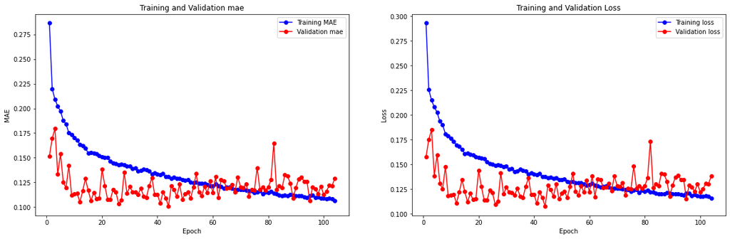

```
3852/3852 ━━━━━━━━━━━━━━━━━━━━ 2s 493us/step - loss: 0.1329 - mae: 0.1260
963/963 ━━━━━━━━━━━━━━━━━━━━ 1s 516us/step - loss: 0.1114 - mae: 0.1046
990/990 ━━━━━━━━━━━━━━━━━━━━ 1s 587us/step - loss: 0.1159 - mae: 0.1091
```

```
Training MAE: 69969.76407983189
```

```
Validation MAE: 57597.43685817446
```

```python
plot(history)
train_MAE = model.evaluate(trainData)[-1] * stdSales
val_MAE = model.evaluate(valData)[-1] * stdSales
test_MAE = model.evaluate(testData)[-1] * stdSales
print(f"Training MAE: {train_MAE}")
print(f"Validation MAE: {val_MAE}")

save_model_results(val_results_path, model_name, val_MAE)
save_model_results(test_results_path, model_name, test_MAE)
```

### **Results discussion**

In this model we have done the same as before, applying bidirectional layers but in this case to the **LSTM model with L2 regularization**. The results obtained are also within acceptable parameters, and if we compare these results with their homogeneous ones without the bidirectional layer, it seems that the results are somewhat **worse** than those of the model without bidirectional layers.

Next, we will try to increase the size of the time series sequences, trying to determine if increasing the contextual information we can obtain better results.

## **Increasing sequence Length to four**

```python
seqLength = 4
trainData, valData, testData, stdSales, nFeatures = generateTrainTestData("./data/walmart-sales-dataset-of-45stores.csv",
    valPercent, testPercent, seqLength, batchSize)
```

## GRU

### Building Model

```python
model_name = "seq4_SimpleGRU"
```

```python
inputs = keras.Input(shape=(seqLength, nFeatures))
x = layers.GRU(10, activation='relu',return_sequences=True)(inputs)
x = layers.GRU(10, activation='relu')(x)
outputs = layers.Dense(1)(x)
model = keras.Model(inputs, outputs)

model.compile(optimizer="adam", loss="mean_absolute_error", metrics=["mae"])
model.summary()
```

```
Model: "functional_29"
```

```
┏━━━━━━━━━━━━━━━━━━━━━━━━━━━━━━━━━┳━━━━━━━━━━━━━━━━━━━━━━━━━━━┳━━━━━━━━━━━━┓
┃ Layer (type)                    ┃ Output Shape              ┃    Param # ┃
┡━━━━━━━━━━━━━━━━━━━━━━━━━━━━━━━━━╇━━━━━━━━━━━━━━━━━━━━━━━━━━━╇━━━━━━━━━━━━┩
│ input_layer_14 (InputLayer)     │ (None, 4, 6)              │          0 │
├─────────────────────────────────┼───────────────────────────┼────────────┤
│ gru_11 (GRU)                    │ (None, 4, 10)             │        540 │
├─────────────────────────────────┼───────────────────────────┼────────────┤
│ gru_12 (GRU)                    │ (None, 10)                │        660 │
├─────────────────────────────────┼───────────────────────────┼────────────┤
│ dense_15 (Dense)                │ (None, 1)                 │         11 │
└─────────────────────────────────┴───────────────────────────┴────────────┘
```

```
 Total params: 1,211 (4.73 KB)
```

```
 Trainable params: 1,211 (4.73 KB)
```

```
 Non-trainable params: 0 (0.00 B)
```

### Training

```python
# Initialize the EarlyStopping callback
early_stopping = EarlyStopping(
    monitor='val_loss',
    patience=60,
    restore_best_weights=True
)

# Train the model with the EarlyStopping callback
history = model.fit(
    trainData,
    epochs=500,
    batch_size=batchSize,
    validation_data=valData,
    callbacks=[early_stopping]  # Add the EarlyStopping callback to the callbacks list
)
```

```
3780/3780 ━━━━━━━━━━━━━━━━━━━━ 6s 1ms/step - loss: 0.3740 - mae: 0.3740 - val_loss: 0.1822 - val_mae: 0.1822
3780/3780 ━━━━━━━━━━━━━━━━━━━━ 4s 890us/step - loss: 0.2075 - mae: 0.2075 - val_loss: 0.1386 - val_mae: 0.1386
3780/3780 ━━━━━━━━━━━━━━━━━━━━ 4s 896us/step - loss: 0.1933 - mae: 0.1933 - val_loss: 0.1182 - val_mae: 0.1182
3780/3780 ━━━━━━━━━━━━━━━━━━━━ 4s 873us/step - loss: 0.1828 - mae: 0.1828 - val_loss: 0.1186 - val_mae: 0.1186
3780/3780 ━━━━━━━━━━━━━━━━━━━━ 4s 894us/step - loss: 0.1796 - mae: 0.1796 - val_loss: 0.1194 - val_mae: 0.1194
3780/3780 ━━━━━━━━━━━━━━━━━━━━ 4s 864us/step - loss: 0.1689 - mae: 0.1689 - val_loss: 0.1131 - val_mae: 0.1131
3780/3780 ━━━━━━━━━━━━━━━━━━━━ 4s 865us/step - loss: 0.1654 - mae: 0.1654 - val_loss: 0.1130 - val_mae: 0.1130
3780/3780 ━━━━━━━━━━━━━━━━━━━━ 4s 882us/step - loss: 0.1621 - mae: 0.1621 - val_loss: 0.1077 - val_mae: 0.1077
3780/3780 ━━━━━━━━━━━━━━━━━━━━ 4s 870us/step - loss: 0.1566 - mae: 0.1566 - val_loss: 0.1006 - val_mae: 0.1006
3780/3780 ━━━━━━━━━━━━━━━━━━━━ 4s 881us/step - loss: 0.1536 - mae: 0.1536 - val_loss: 0.1075 - val_mae: 0.1075
3780/3780 ━━━━━━━━━━━━━━━━━━━━ 4s 911us/step - loss: 0.1569 - mae: 0.1569 - val_loss: 0.1003 - val_mae: 0.1003
3780/3780 ━━━━━━━━━━━━━━━━━━━━ 4s 865us/step - loss: 0.1505 - mae: 0.1505 - val_loss: 0.0999 - val_mae: 0.0999
3780/3780 ━━━━━━━━━━━━━━━━━━━━ 4s 862us/step - loss: 0.1512 - mae: 0.1512 - val_loss: 0.0978 - val_mae: 0.0978
3780/3780 ━━━━━━━━━━━━━━━━━━━━ 4s 874us/step - loss: 0.1469 - mae: 0.1469 - val_loss: 0.0978 - val_mae: 0.0978
3780/3780 ━━━━━━━━━━━━━━━━━━━━ 4s 850us/step - loss: 0.1468 - mae: 0.1468 - val_loss: 0.0907 - val_mae: 0.0907
3780/3780 ━━━━━━━━━━━━━━━━━━━━ 4s 873us/step - loss: 0.1381 - mae: 0.1381 - val_loss: 0.1052 - val_mae: 0.1052
3780/3780 ━━━━━━━━━━━━━━━━━━━━ 4s 861us/step - loss: 0.1493 - mae: 0.1493 - val_loss: 0.1010 - val_mae: 0.1010
3780/3780 ━━━━━━━━━━━━━━━━━━━━ 4s 862us/step - loss: 0.1478 - mae: 0.1478 - val_loss: 0.0987 - val_mae: 0.0987
3780/3780 ━━━━━━━━━━━━━━━━━━━━ 4s 875us/step - loss: 0.1457 - mae: 0.1457 - val_loss: 0.1064 - val_mae: 0.1064
3780/3780 ━━━━━━━━━━━━━━━━━━━━ 4s 882us/step - loss: 0.1462 - mae: 0.1462 - val_loss: 0.1033 - val_mae: 0.1033
3780/3780 ━━━━━━━━━━━━━━━━━━━━ 4s 840us/step - loss: 0.1406 - mae: 0.1406 - val_loss: 0.0936 - val_mae: 0.0936
3780/3780 ━━━━━━━━━━━━━━━━━━━━ 4s 848us/step - loss: 0.1470 - mae: 0.1470 - val_loss: 0.0967 - val_mae: 0.0967
3780/3780 ━━━━━━━━━━━━━━━━━━━━ 4s 896us/step - loss: 0.1416 - mae: 0.1416 - val_loss: 0.0955 - val_mae: 0.0955
3780/3780 ━━━━━━━━━━━━━━━━━━━━ 4s 903us/step - loss: 0.1430 - mae: 0.1430 - val_loss: 0.1070 - val_mae: 0.1070
3780/3780 ━━━━━━━━━━━━━━━━━━━━ 4s 893us/step - loss: 0.1404 - mae: 0.1404 - val_loss: 0.0914 - val_mae: 0.0914
3780/3780 ━━━━━━━━━━━━━━━━━━━━ 4s 868us/step - loss: 0.1358 - mae: 0.1358 - val_loss: 0.0957 - val_mae: 0.0957
3780/3780 ━━━━━━━━━━━━━━━━━━━━ 4s 866us/step - loss: 0.1382 - mae: 0.1382 - val_loss: 0.0935 - val_mae: 0.0935
3780/3780 ━━━━━━━━━━━━━━━━━━━━ 4s 872us/step - loss: 0.1409 - mae: 0.1409 - val_loss: 0.0984 - val_mae: 0.0984
3780/3780 ━━━━━━━━━━━━━━━━━━━━ 4s 870us/step - loss: 0.1385 - mae: 0.1385 - val_loss: 0.0988 - val_mae: 0.0988
3780/3780 ━━━━━━━━━━━━━━━━━━━━ 4s 886us/step - loss: 0.1372 - mae: 0.1372 - val_loss: 0.0906 - val_mae: 0.0906
3780/3780 ━━━━━━━━━━━━━━━━━━━━ 4s 839us/step - loss: 0.1375 - mae: 0.1375 - val_loss: 0.0916 - val_mae: 0.0916
3780/3780 ━━━━━━━━━━━━━━━━━━━━ 4s 866us/step - loss: 0.1382 - mae: 0.1382 - val_loss: 0.0943 - val_mae: 0.0943
3780/3780 ━━━━━━━━━━━━━━━━━━━━ 4s 878us/step - loss: 0.1360 - mae: 0.1360 - val_loss: 0.0892 - val_mae: 0.0892
3780/3780 ━━━━━━━━━━━━━━━━━━━━ 4s 861us/step - loss: 0.1352 - mae: 0.1352 - val_loss: 0.0927 - val_mae: 0.0927
3780/3780 ━━━━━━━━━━━━━━━━━━━━ 4s 900us/step - loss: 0.1307 - mae: 0.1307 - val_loss: 0.1047 - val_mae: 0.1047
3780/3780 ━━━━━━━━━━━━━━━━━━━━ 4s 896us/step - loss: 0.1341 - mae: 0.1341 - val_loss: 0.0953 - val_mae: 0.0953
3780/3780 ━━━━━━━━━━━━━━━━━━━━ 4s 848us/step - loss: 0.1333 - mae: 0.1333 - val_loss: 0.0903 - val_mae: 0.0903
3780/3780 ━━━━━━━━━━━━━━━━━━━━ 4s 871us/step - loss: 0.1327 - mae: 0.1327 - val_loss: 0.0925 - val_mae: 0.0925
3780/3780 ━━━━━━━━━━━━━━━━━━━━ 4s 872us/step - loss: 0.1351 - mae: 0.1351 - val_loss: 0.0883 - val_mae: 0.0883
3780/3780 ━━━━━━━━━━━━━━━━━━━━ 4s 859us/step - loss: 0.1394 - mae: 0.1394 - val_loss: 0.1111 - val_mae: 0.1111
```

[output cut: 62 more lines]

```
3780/3780 ━━━━━━━━━━━━━━━━━━━━ 4s 899us/step - loss: 0.1202 - mae: 0.1202 - val_loss: 0.1142 - val_mae: 0.1142
3780/3780 ━━━━━━━━━━━━━━━━━━━━ 4s 902us/step - loss: 0.1214 - mae: 0.1214 - val_loss: 0.1049 - val_mae: 0.1049
3780/3780 ━━━━━━━━━━━━━━━━━━━━ 4s 871us/step - loss: 0.1228 - mae: 0.1228 - val_loss: 0.1032 - val_mae: 0.1032
3780/3780 ━━━━━━━━━━━━━━━━━━━━ 4s 874us/step - loss: 0.1194 - mae: 0.1194 - val_loss: 0.1033 - val_mae: 0.1033
3780/3780 ━━━━━━━━━━━━━━━━━━━━ 4s 913us/step - loss: 0.1212 - mae: 0.1212 - val_loss: 0.1100 - val_mae: 0.1100
3780/3780 ━━━━━━━━━━━━━━━━━━━━ 4s 914us/step - loss: 0.1189 - mae: 0.1189 - val_loss: 0.1058 - val_mae: 0.1058
3780/3780 ━━━━━━━━━━━━━━━━━━━━ 4s 909us/step - loss: 0.1190 - mae: 0.1190 - val_loss: 0.1118 - val_mae: 0.1118
3780/3780 ━━━━━━━━━━━━━━━━━━━━ 4s 906us/step - loss: 0.1183 - mae: 0.1183 - val_loss: 0.1128 - val_mae: 0.1128
3780/3780 ━━━━━━━━━━━━━━━━━━━━ 4s 880us/step - loss: 0.1173 - mae: 0.1173 - val_loss: 0.1050 - val_mae: 0.1050
3780/3780 ━━━━━━━━━━━━━━━━━━━━ 4s 910us/step - loss: 0.1203 - mae: 0.1203 - val_loss: 0.1045 - val_mae: 0.1045
3780/3780 ━━━━━━━━━━━━━━━━━━━━ 4s 914us/step - loss: 0.1163 - mae: 0.1163 - val_loss: 0.1008 - val_mae: 0.1008
3780/3780 ━━━━━━━━━━━━━━━━━━━━ 4s 884us/step - loss: 0.1172 - mae: 0.1172 - val_loss: 0.1291 - val_mae: 0.1291
3780/3780 ━━━━━━━━━━━━━━━━━━━━ 4s 911us/step - loss: 0.1166 - mae: 0.1166 - val_loss: 0.1070 - val_mae: 0.1070
3780/3780 ━━━━━━━━━━━━━━━━━━━━ 4s 875us/step - loss: 0.1187 - mae: 0.1187 - val_loss: 0.1041 - val_mae: 0.1041
3780/3780 ━━━━━━━━━━━━━━━━━━━━ 4s 882us/step - loss: 0.1173 - mae: 0.1173 - val_loss: 0.1084 - val_mae: 0.1084
```

### Evaluation

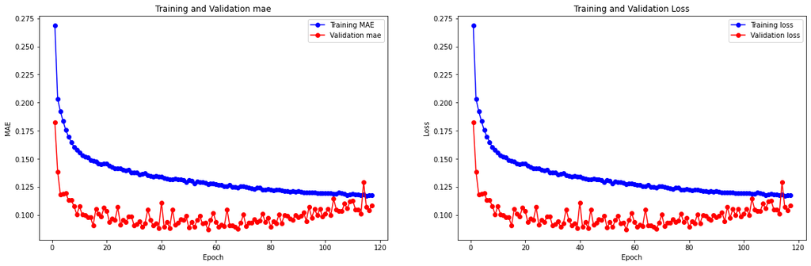

```
3780/3780 ━━━━━━━━━━━━━━━━━━━━ 2s 311us/step - loss: 0.1259 - mae: 0.1259
945/945 ━━━━━━━━━━━━━━━━━━━━ 1s 329us/step - loss: 0.0843 - mae: 0.0843
900/900 ━━━━━━━━━━━━━━━━━━━━ 1s 513us/step - loss: 0.1032 - mae: 0.1032
```

```
Training MAE: 69366.66479348471
```

```
Validation MAE: 49738.14363608778
```

```python
plot(history)
train_MAE = model.evaluate(trainData)[-1] * stdSales
val_MAE = model.evaluate(valData)[-1] * stdSales
test_MAE = model.evaluate(testData)[-1] * stdSales
print(f"Training MAE: {train_MAE}")
print(f"Validation MAE: {val_MAE}")

save_model_results(val_results_path, model_name, val_MAE)
save_model_results(test_results_path, model_name, test_MAE)
```

### **Results discussion**

Now we have extended the **sequence size to 4**, and we have tested on a simple GRU model how it works. In this case, using sequence 4, the results obtained by this model are better than the simple GRU model with sequence 3 (both in training and validation). These results are the better results obtained so far, so the fact of increasing the sequence size helped the model to improve the performance.

## LSTM

### Building the model

```python
model_name = "seq4_complex_LSTM_L2"
```

```python
inputs = Input(shape=(seqLength, nFeatures))

x = LSTM(units=32, activation='relu', return_sequences=True,
              kernel_regularizer=l2(0.00001), recurrent_regularizer=l2(0.00001))(inputs)

x = LSTM(units=64, activation='relu', return_sequences=True,
              kernel_regularizer=l2(0.00001), recurrent_regularizer=l2(0.00001))(x)

x = LSTM(units=128, activation='relu', return_sequences=True,
              kernel_regularizer=l2(0.00001), recurrent_regularizer=l2(0.00001))(x)

x = LSTM(units=64, activation='relu', kernel_regularizer=l2(0.00001), recurrent_regularizer=l2(0.00001))(x)

outputs = Dense(1)(x)

model = Model(inputs=inputs, outputs=outputs)
model.compile(optimizer='adam', loss='mean_absolute_error', metrics=['mae'])
model.summary()
```

```
Model: "functional_31"
```

```
┏━━━━━━━━━━━━━━━━━━━━━━━━━━━━━━━━━┳━━━━━━━━━━━━━━━━━━━━━━━━━━━┳━━━━━━━━━━━━┓
┃ Layer (type)                    ┃ Output Shape              ┃    Param # ┃
┡━━━━━━━━━━━━━━━━━━━━━━━━━━━━━━━━━╇━━━━━━━━━━━━━━━━━━━━━━━━━━━╇━━━━━━━━━━━━┩
│ input_layer_15 (InputLayer)     │ (None, 4, 6)              │          0 │
├─────────────────────────────────┼───────────────────────────┼────────────┤
│ lstm_17 (LSTM)                  │ (None, 4, 32)             │      4,992 │
├─────────────────────────────────┼───────────────────────────┼────────────┤
│ lstm_18 (LSTM)                  │ (None, 4, 64)             │     24,832 │
├─────────────────────────────────┼───────────────────────────┼────────────┤
│ lstm_19 (LSTM)                  │ (None, 4, 128)            │     98,816 │
├─────────────────────────────────┼───────────────────────────┼────────────┤
│ lstm_20 (LSTM)                  │ (None, 64)                │     49,408 │
├─────────────────────────────────┼───────────────────────────┼────────────┤
│ dense_16 (Dense)                │ (None, 1)                 │         65 │
└─────────────────────────────────┴───────────────────────────┴────────────┘
```

```
 Total params: 178,113 (695.75 KB)
```

```
 Trainable params: 178,113 (695.75 KB)
```

```
 Non-trainable params: 0 (0.00 B)
```

### Training

```python
# Initialize the EarlyStopping callback
early_stopping = EarlyStopping(
    monitor='val_loss',
    patience=60,
    restore_best_weights=True
)

# Train the model with the EarlyStopping callback
history = model.fit(
    trainData,
    epochs=500,
    batch_size=batchSize,
    validation_data=valData,
    callbacks=[early_stopping]  # Add the EarlyStopping callback to the callbacks list
)
```

```
3780/3780 ━━━━━━━━━━━━━━━━━━━━ 9s 2ms/step - loss: 0.3725 - mae: 0.3699 - val_loss: 0.1808 - val_mae: 0.1778
3780/3780 ━━━━━━━━━━━━━━━━━━━━ 6s 1ms/step - loss: 0.2395 - mae: 0.2363 - val_loss: 0.1338 - val_mae: 0.1302
3780/3780 ━━━━━━━━━━━━━━━━━━━━ 6s 1ms/step - loss: 0.2258 - mae: 0.2221 - val_loss: 0.1794 - val_mae: 0.1754
3780/3780 ━━━━━━━━━━━━━━━━━━━━ 6s 1ms/step - loss: 0.2114 - mae: 0.2074 - val_loss: 0.1327 - val_mae: 0.1285
3780/3780 ━━━━━━━━━━━━━━━━━━━━ 6s 1ms/step - loss: 0.2043 - mae: 0.2001 - val_loss: 0.1674 - val_mae: 0.1632
3780/3780 ━━━━━━━━━━━━━━━━━━━━ 6s 1ms/step - loss: 0.2038 - mae: 0.1996 - val_loss: 0.1293 - val_mae: 0.1250
3780/3780 ━━━━━━━━━━━━━━━━━━━━ 6s 2ms/step - loss: 0.1951 - mae: 0.1908 - val_loss: 0.1617 - val_mae: 0.1573
3780/3780 ━━━━━━━━━━━━━━━━━━━━ 6s 1ms/step - loss: 0.1837 - mae: 0.1793 - val_loss: 0.1560 - val_mae: 0.1516
3780/3780 ━━━━━━━━━━━━━━━━━━━━ 6s 1ms/step - loss: 0.1766 - mae: 0.1722 - val_loss: 0.1215 - val_mae: 0.1170
3780/3780 ━━━━━━━━━━━━━━━━━━━━ 6s 1ms/step - loss: 0.1797 - mae: 0.1752 - val_loss: 0.1115 - val_mae: 0.1070
3780/3780 ━━━━━━━━━━━━━━━━━━━━ 6s 1ms/step - loss: 0.1728 - mae: 0.1683 - val_loss: 0.1268 - val_mae: 0.1223
3780/3780 ━━━━━━━━━━━━━━━━━━━━ 6s 1ms/step - loss: 0.1709 - mae: 0.1664 - val_loss: 0.1357 - val_mae: 0.1312
3780/3780 ━━━━━━━━━━━━━━━━━━━━ 6s 1ms/step - loss: 0.1698 - mae: 0.1652 - val_loss: 0.1136 - val_mae: 0.1090
3780/3780 ━━━━━━━━━━━━━━━━━━━━ 6s 2ms/step - loss: 0.1623 - mae: 0.1577 - val_loss: 0.1121 - val_mae: 0.1074
3780/3780 ━━━━━━━━━━━━━━━━━━━━ 6s 1ms/step - loss: 0.1591 - mae: 0.1544 - val_loss: 0.1134 - val_mae: 0.1087
3780/3780 ━━━━━━━━━━━━━━━━━━━━ 6s 1ms/step - loss: 0.1602 - mae: 0.1554 - val_loss: 0.1036 - val_mae: 0.0988
3780/3780 ━━━━━━━━━━━━━━━━━━━━ 6s 1ms/step - loss: 0.1575 - mae: 0.1527 - val_loss: 0.1090 - val_mae: 0.1042
3780/3780 ━━━━━━━━━━━━━━━━━━━━ 6s 1ms/step - loss: 0.1543 - mae: 0.1494 - val_loss: 0.1166 - val_mae: 0.1117
3780/3780 ━━━━━━━━━━━━━━━━━━━━ 6s 1ms/step - loss: 0.1536 - mae: 0.1486 - val_loss: 0.1188 - val_mae: 0.1138
3780/3780 ━━━━━━━━━━━━━━━━━━━━ 6s 1ms/step - loss: 0.1492 - mae: 0.1442 - val_loss: 0.1183 - val_mae: 0.1132
3780/3780 ━━━━━━━━━━━━━━━━━━━━ 6s 1ms/step - loss: 0.1480 - mae: 0.1428 - val_loss: 0.1126 - val_mae: 0.1074
3780/3780 ━━━━━━━━━━━━━━━━━━━━ 6s 1ms/step - loss: 0.1514 - mae: 0.1462 - val_loss: 0.1061 - val_mae: 0.1009
3780/3780 ━━━━━━━━━━━━━━━━━━━━ 6s 1ms/step - loss: 0.1470 - mae: 0.1417 - val_loss: 0.1394 - val_mae: 0.1341
3780/3780 ━━━━━━━━━━━━━━━━━━━━ 6s 1ms/step - loss: 0.1477 - mae: 0.1424 - val_loss: 0.1105 - val_mae: 0.1051
3780/3780 ━━━━━━━━━━━━━━━━━━━━ 6s 1ms/step - loss: 0.1435 - mae: 0.1380 - val_loss: 0.1040 - val_mae: 0.0985
3780/3780 ━━━━━━━━━━━━━━━━━━━━ 6s 1ms/step - loss: 0.1419 - mae: 0.1364 - val_loss: 0.1075 - val_mae: 0.1019
3780/3780 ━━━━━━━━━━━━━━━━━━━━ 6s 1ms/step - loss: 0.1486 - mae: 0.1430 - val_loss: 0.1120 - val_mae: 0.1064
3780/3780 ━━━━━━━━━━━━━━━━━━━━ 6s 1ms/step - loss: 0.1469 - mae: 0.1412 - val_loss: 0.1134 - val_mae: 0.1076
3780/3780 ━━━━━━━━━━━━━━━━━━━━ 6s 1ms/step - loss: 0.1411 - mae: 0.1352 - val_loss: 0.1143 - val_mae: 0.1085
3780/3780 ━━━━━━━━━━━━━━━━━━━━ 6s 1ms/step - loss: 0.1411 - mae: 0.1353 - val_loss: 0.1166 - val_mae: 0.1107
3780/3780 ━━━━━━━━━━━━━━━━━━━━ 6s 1ms/step - loss: 0.1380 - mae: 0.1320 - val_loss: 0.1064 - val_mae: 0.1004
3780/3780 ━━━━━━━━━━━━━━━━━━━━ 6s 1ms/step - loss: 0.1364 - mae: 0.1305 - val_loss: 0.1015 - val_mae: 0.0956
3780/3780 ━━━━━━━━━━━━━━━━━━━━ 6s 1ms/step - loss: 0.1344 - mae: 0.1284 - val_loss: 0.1114 - val_mae: 0.1054
3780/3780 ━━━━━━━━━━━━━━━━━━━━ 5s 1ms/step - loss: 0.1333 - mae: 0.1272 - val_loss: 0.1067 - val_mae: 0.1006
3780/3780 ━━━━━━━━━━━━━━━━━━━━ 6s 1ms/step - loss: 0.1342 - mae: 0.1281 - val_loss: 0.1085 - val_mae: 0.1023
3780/3780 ━━━━━━━━━━━━━━━━━━━━ 6s 1ms/step - loss: 0.1341 - mae: 0.1280 - val_loss: 0.1130 - val_mae: 0.1069
3780/3780 ━━━━━━━━━━━━━━━━━━━━ 5s 1ms/step - loss: 0.1343 - mae: 0.1281 - val_loss: 0.1115 - val_mae: 0.1053
3780/3780 ━━━━━━━━━━━━━━━━━━━━ 6s 1ms/step - loss: 0.1325 - mae: 0.1262 - val_loss: 0.1257 - val_mae: 0.1193
3780/3780 ━━━━━━━━━━━━━━━━━━━━ 6s 1ms/step - loss: 0.1334 - mae: 0.1270 - val_loss: 0.1064 - val_mae: 0.1000
3780/3780 ━━━━━━━━━━━━━━━━━━━━ 6s 1ms/step - loss: 0.1335 - mae: 0.1271 - val_loss: 0.1244 - val_mae: 0.1179
```

[output cut: 46 more lines]

```
3780/3780 ━━━━━━━━━━━━━━━━━━━━ 6s 1ms/step - loss: 0.1145 - mae: 0.1063 - val_loss: 0.1168 - val_mae: 0.1085
3780/3780 ━━━━━━━━━━━━━━━━━━━━ 6s 1ms/step - loss: 0.1106 - mae: 0.1024 - val_loss: 0.1274 - val_mae: 0.1191
3780/3780 ━━━━━━━━━━━━━━━━━━━━ 5s 1ms/step - loss: 0.1099 - mae: 0.1016 - val_loss: 0.1204 - val_mae: 0.1122
3780/3780 ━━━━━━━━━━━━━━━━━━━━ 6s 1ms/step - loss: 0.1127 - mae: 0.1044 - val_loss: 0.1214 - val_mae: 0.1132
3780/3780 ━━━━━━━━━━━━━━━━━━━━ 6s 1ms/step - loss: 0.1174 - mae: 0.1092 - val_loss: 0.1204 - val_mae: 0.1121
3780/3780 ━━━━━━━━━━━━━━━━━━━━ 6s 1ms/step - loss: 0.1127 - mae: 0.1044 - val_loss: 0.1241 - val_mae: 0.1158
3780/3780 ━━━━━━━━━━━━━━━━━━━━ 6s 1ms/step - loss: 0.1076 - mae: 0.0992 - val_loss: 0.1392 - val_mae: 0.1309
3780/3780 ━━━━━━━━━━━━━━━━━━━━ 6s 1ms/step - loss: 0.1104 - mae: 0.1021 - val_loss: 0.1180 - val_mae: 0.1096
3780/3780 ━━━━━━━━━━━━━━━━━━━━ 6s 1ms/step - loss: 0.1090 - mae: 0.1006 - val_loss: 0.1114 - val_mae: 0.1030
3780/3780 ━━━━━━━━━━━━━━━━━━━━ 6s 1ms/step - loss: 0.1109 - mae: 0.1025 - val_loss: 0.1051 - val_mae: 0.0966
3780/3780 ━━━━━━━━━━━━━━━━━━━━ 6s 1ms/step - loss: 0.1122 - mae: 0.1038 - val_loss: 0.1197 - val_mae: 0.1113
3780/3780 ━━━━━━━━━━━━━━━━━━━━ 6s 1ms/step - loss: 0.1093 - mae: 0.1009 - val_loss: 0.1230 - val_mae: 0.1145
3780/3780 ━━━━━━━━━━━━━━━━━━━━ 6s 2ms/step - loss: 0.1124 - mae: 0.1039 - val_loss: 0.1094 - val_mae: 0.1009
3780/3780 ━━━━━━━━━━━━━━━━━━━━ 6s 2ms/step - loss: 0.1114 - mae: 0.1029 - val_loss: 0.1159 - val_mae: 0.1074
3780/3780 ━━━━━━━━━━━━━━━━━━━━ 6s 1ms/step - loss: 0.1088 - mae: 0.1002 - val_loss: 0.1123 - val_mae: 0.1037
```

### Evaluation

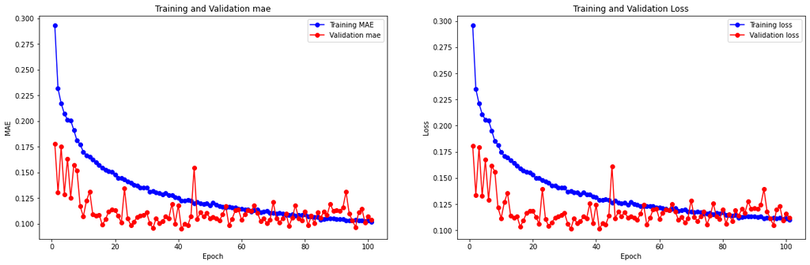

```
3780/3780 ━━━━━━━━━━━━━━━━━━━━ 2s 398us/step - loss: 0.1273 - mae: 0.1209
945/945 ━━━━━━━━━━━━━━━━━━━━ 1s 457us/step - loss: 0.1017 - mae: 0.0952
900/900 ━━━━━━━━━━━━━━━━━━━━ 1s 613us/step - loss: 0.1263 - mae: 0.1199
```

```
Training MAE: 68073.26775525934
```

```
Validation MAE: 54359.11694601536
```

```python
plot(history)
train_MAE = model.evaluate(trainData)[-1] * stdSales
val_MAE = model.evaluate(valData)[-1] * stdSales
test_MAE = model.evaluate(testData)[-1] * stdSales
print(f"Training MAE: {train_MAE}")
print(f"Validation MAE: {val_MAE}")

save_model_results(val_results_path, model_name, val_MAE)
save_model_results(test_results_path, model_name, test_MAE)
```

### **Results discussion**

The same LSTM model that we have tested previously, we have now tested for sequence 4, and it seems to **perform better** than the two LSTM models tested previously with sequence 3 (both in train and validation).

## Bidirectional

### Building the model

```python
model_name = "seq4_bidirectional_SimpleGRU"
```

```python
inputs = keras.Input(shape=(seqLength, nFeatures))
x = layers.Bidirectional(layers.GRU(10, activation='relu',return_sequences=True))(inputs)
x = layers.Bidirectional(layers.GRU(10, activation='relu'))(x)
outputs = layers.Dense(1)(x)
model = keras.Model(inputs, outputs)

model.compile(optimizer="adam", loss="mean_absolute_error", metrics=["mae"])
model.summary()
```

```
Model: "functional_33"
```

```
┏━━━━━━━━━━━━━━━━━━━━━━━━━━━━━━━━━┳━━━━━━━━━━━━━━━━━━━━━━━━━━━┳━━━━━━━━━━━━┓
┃ Layer (type)                    ┃ Output Shape              ┃    Param # ┃
┡━━━━━━━━━━━━━━━━━━━━━━━━━━━━━━━━━╇━━━━━━━━━━━━━━━━━━━━━━━━━━━╇━━━━━━━━━━━━┩
│ input_layer_16 (InputLayer)     │ (None, 4, 6)              │          0 │
├─────────────────────────────────┼───────────────────────────┼────────────┤
│ bidirectional_6 (Bidirectional) │ (None, 4, 20)             │      1,080 │
├─────────────────────────────────┼───────────────────────────┼────────────┤
│ bidirectional_7 (Bidirectional) │ (None, 20)                │      1,920 │
├─────────────────────────────────┼───────────────────────────┼────────────┤
│ dense_17 (Dense)                │ (None, 1)                 │         21 │
└─────────────────────────────────┴───────────────────────────┴────────────┘
```

```
 Total params: 3,021 (11.80 KB)
```

```
 Trainable params: 3,021 (11.80 KB)
```

```
 Non-trainable params: 0 (0.00 B)
```

### Training

```python
# Initialize the EarlyStopping callback
early_stopping = EarlyStopping(
    monitor='val_loss',
    patience=60,
    restore_best_weights=True
)

# Train the model with the EarlyStopping callback
history = model.fit(
    trainData,
    epochs=500,
    batch_size=batchSize,
    validation_data=valData,
    callbacks=[early_stopping]  # Add the EarlyStopping callback to the callbacks list
)
```

```
3780/3780 ━━━━━━━━━━━━━━━━━━━━ 9s 1ms/step - loss: 0.3402 - mae: 0.3402 - val_loss: 0.1551 - val_mae: 0.1551
3780/3780 ━━━━━━━━━━━━━━━━━━━━ 5s 1ms/step - loss: 0.2066 - mae: 0.2066 - val_loss: 0.1470 - val_mae: 0.1470
3780/3780 ━━━━━━━━━━━━━━━━━━━━ 5s 1ms/step - loss: 0.1923 - mae: 0.1923 - val_loss: 0.1280 - val_mae: 0.1280
3780/3780 ━━━━━━━━━━━━━━━━━━━━ 5s 1ms/step - loss: 0.1838 - mae: 0.1838 - val_loss: 0.1408 - val_mae: 0.1408
3780/3780 ━━━━━━━━━━━━━━━━━━━━ 6s 1ms/step - loss: 0.1708 - mae: 0.1708 - val_loss: 0.1184 - val_mae: 0.1184
3780/3780 ━━━━━━━━━━━━━━━━━━━━ 6s 1ms/step - loss: 0.1721 - mae: 0.1721 - val_loss: 0.1188 - val_mae: 0.1188
3780/3780 ━━━━━━━━━━━━━━━━━━━━ 5s 1ms/step - loss: 0.1649 - mae: 0.1649 - val_loss: 0.1102 - val_mae: 0.1102
3780/3780 ━━━━━━━━━━━━━━━━━━━━ 5s 1ms/step - loss: 0.1574 - mae: 0.1574 - val_loss: 0.1130 - val_mae: 0.1130
3780/3780 ━━━━━━━━━━━━━━━━━━━━ 5s 1ms/step - loss: 0.1575 - mae: 0.1575 - val_loss: 0.0998 - val_mae: 0.0998
3780/3780 ━━━━━━━━━━━━━━━━━━━━ 6s 1ms/step - loss: 0.1496 - mae: 0.1496 - val_loss: 0.1093 - val_mae: 0.1093
3780/3780 ━━━━━━━━━━━━━━━━━━━━ 5s 1ms/step - loss: 0.1491 - mae: 0.1491 - val_loss: 0.1057 - val_mae: 0.1057
3780/3780 ━━━━━━━━━━━━━━━━━━━━ 5s 1ms/step - loss: 0.1480 - mae: 0.1480 - val_loss: 0.1196 - val_mae: 0.1196
3780/3780 ━━━━━━━━━━━━━━━━━━━━ 5s 1ms/step - loss: 0.1451 - mae: 0.1451 - val_loss: 0.1107 - val_mae: 0.1107
3780/3780 ━━━━━━━━━━━━━━━━━━━━ 5s 1ms/step - loss: 0.1450 - mae: 0.1450 - val_loss: 0.1003 - val_mae: 0.1003
3780/3780 ━━━━━━━━━━━━━━━━━━━━ 5s 1ms/step - loss: 0.1464 - mae: 0.1464 - val_loss: 0.1200 - val_mae: 0.1200
3780/3780 ━━━━━━━━━━━━━━━━━━━━ 5s 1ms/step - loss: 0.1438 - mae: 0.1438 - val_loss: 0.0964 - val_mae: 0.0964
3780/3780 ━━━━━━━━━━━━━━━━━━━━ 5s 1ms/step - loss: 0.1342 - mae: 0.1342 - val_loss: 0.1020 - val_mae: 0.1020
3780/3780 ━━━━━━━━━━━━━━━━━━━━ 5s 1ms/step - loss: 0.1452 - mae: 0.1452 - val_loss: 0.0979 - val_mae: 0.0979
3780/3780 ━━━━━━━━━━━━━━━━━━━━ 5s 1ms/step - loss: 0.1380 - mae: 0.1380 - val_loss: 0.1073 - val_mae: 0.1073
3780/3780 ━━━━━━━━━━━━━━━━━━━━ 5s 1ms/step - loss: 0.1386 - mae: 0.1386 - val_loss: 0.0992 - val_mae: 0.0992
3780/3780 ━━━━━━━━━━━━━━━━━━━━ 5s 1ms/step - loss: 0.1398 - mae: 0.1398 - val_loss: 0.1024 - val_mae: 0.1024
3780/3780 ━━━━━━━━━━━━━━━━━━━━ 5s 1ms/step - loss: 0.1390 - mae: 0.1390 - val_loss: 0.1057 - val_mae: 0.1057
3780/3780 ━━━━━━━━━━━━━━━━━━━━ 5s 1ms/step - loss: 0.1361 - mae: 0.1361 - val_loss: 0.0978 - val_mae: 0.0978
3780/3780 ━━━━━━━━━━━━━━━━━━━━ 5s 1ms/step - loss: 0.1292 - mae: 0.1292 - val_loss: 0.1008 - val_mae: 0.1008
3780/3780 ━━━━━━━━━━━━━━━━━━━━ 6s 1ms/step - loss: 0.1344 - mae: 0.1344 - val_loss: 0.0912 - val_mae: 0.0912
3780/3780 ━━━━━━━━━━━━━━━━━━━━ 5s 1ms/step - loss: 0.1265 - mae: 0.1265 - val_loss: 0.1093 - val_mae: 0.1093
3780/3780 ━━━━━━━━━━━━━━━━━━━━ 5s 1ms/step - loss: 0.1319 - mae: 0.1319 - val_loss: 0.1125 - val_mae: 0.1125
3780/3780 ━━━━━━━━━━━━━━━━━━━━ 5s 1ms/step - loss: 0.1327 - mae: 0.1327 - val_loss: 0.1116 - val_mae: 0.1116
3780/3780 ━━━━━━━━━━━━━━━━━━━━ 5s 1ms/step - loss: 0.1284 - mae: 0.1284 - val_loss: 0.1262 - val_mae: 0.1262
3780/3780 ━━━━━━━━━━━━━━━━━━━━ 5s 1ms/step - loss: 0.1297 - mae: 0.1297 - val_loss: 0.1161 - val_mae: 0.1161
3780/3780 ━━━━━━━━━━━━━━━━━━━━ 5s 1ms/step - loss: 0.1327 - mae: 0.1327 - val_loss: 0.1152 - val_mae: 0.1152
3780/3780 ━━━━━━━━━━━━━━━━━━━━ 5s 1ms/step - loss: 0.1265 - mae: 0.1265 - val_loss: 0.1063 - val_mae: 0.1063
3780/3780 ━━━━━━━━━━━━━━━━━━━━ 5s 1ms/step - loss: 0.1245 - mae: 0.1245 - val_loss: 0.1188 - val_mae: 0.1188
3780/3780 ━━━━━━━━━━━━━━━━━━━━ 5s 1ms/step - loss: 0.1256 - mae: 0.1256 - val_loss: 0.1064 - val_mae: 0.1064
3780/3780 ━━━━━━━━━━━━━━━━━━━━ 5s 1ms/step - loss: 0.1242 - mae: 0.1242 - val_loss: 0.0994 - val_mae: 0.0994
3780/3780 ━━━━━━━━━━━━━━━━━━━━ 5s 1ms/step - loss: 0.1237 - mae: 0.1237 - val_loss: 0.0995 - val_mae: 0.0995
3780/3780 ━━━━━━━━━━━━━━━━━━━━ 5s 1ms/step - loss: 0.1257 - mae: 0.1257 - val_loss: 0.1250 - val_mae: 0.1250
3780/3780 ━━━━━━━━━━━━━━━━━━━━ 5s 1ms/step - loss: 0.1214 - mae: 0.1214 - val_loss: 0.1195 - val_mae: 0.1195
3780/3780 ━━━━━━━━━━━━━━━━━━━━ 5s 1ms/step - loss: 0.1245 - mae: 0.1245 - val_loss: 0.1186 - val_mae: 0.1186
3780/3780 ━━━━━━━━━━━━━━━━━━━━ 5s 1ms/step - loss: 0.1234 - mae: 0.1234 - val_loss: 0.1106 - val_mae: 0.1106
```

[output cut: 30 more lines]

```
3780/3780 ━━━━━━━━━━━━━━━━━━━━ 5s 1ms/step - loss: 0.1121 - mae: 0.1121 - val_loss: 0.1291 - val_mae: 0.1291
3780/3780 ━━━━━━━━━━━━━━━━━━━━ 5s 1ms/step - loss: 0.1110 - mae: 0.1110 - val_loss: 0.1153 - val_mae: 0.1153
3780/3780 ━━━━━━━━━━━━━━━━━━━━ 5s 1ms/step - loss: 0.1064 - mae: 0.1064 - val_loss: 0.1103 - val_mae: 0.1103
3780/3780 ━━━━━━━━━━━━━━━━━━━━ 5s 1ms/step - loss: 0.1131 - mae: 0.1131 - val_loss: 0.1105 - val_mae: 0.1105
3780/3780 ━━━━━━━━━━━━━━━━━━━━ 6s 2ms/step - loss: 0.1100 - mae: 0.1100 - val_loss: 0.1171 - val_mae: 0.1171
3780/3780 ━━━━━━━━━━━━━━━━━━━━ 5s 1ms/step - loss: 0.1100 - mae: 0.1100 - val_loss: 0.1198 - val_mae: 0.1198
3780/3780 ━━━━━━━━━━━━━━━━━━━━ 6s 1ms/step - loss: 0.1112 - mae: 0.1112 - val_loss: 0.0999 - val_mae: 0.0999
3780/3780 ━━━━━━━━━━━━━━━━━━━━ 5s 1ms/step - loss: 0.1103 - mae: 0.1103 - val_loss: 0.1012 - val_mae: 0.1012
3780/3780 ━━━━━━━━━━━━━━━━━━━━ 5s 1ms/step - loss: 0.1088 - mae: 0.1088 - val_loss: 0.1140 - val_mae: 0.1140
3780/3780 ━━━━━━━━━━━━━━━━━━━━ 5s 1ms/step - loss: 0.1099 - mae: 0.1099 - val_loss: 0.1196 - val_mae: 0.1196
3780/3780 ━━━━━━━━━━━━━━━━━━━━ 5s 1ms/step - loss: 0.1086 - mae: 0.1086 - val_loss: 0.1097 - val_mae: 0.1097
3780/3780 ━━━━━━━━━━━━━━━━━━━━ 5s 1ms/step - loss: 0.1072 - mae: 0.1072 - val_loss: 0.1130 - val_mae: 0.1130
3780/3780 ━━━━━━━━━━━━━━━━━━━━ 5s 1ms/step - loss: 0.1074 - mae: 0.1074 - val_loss: 0.1130 - val_mae: 0.1130
3780/3780 ━━━━━━━━━━━━━━━━━━━━ 5s 1ms/step - loss: 0.1065 - mae: 0.1065 - val_loss: 0.1106 - val_mae: 0.1106
3780/3780 ━━━━━━━━━━━━━━━━━━━━ 5s 1ms/step - loss: 0.1085 - mae: 0.1085 - val_loss: 0.1169 - val_mae: 0.1169
```

### Evaluation

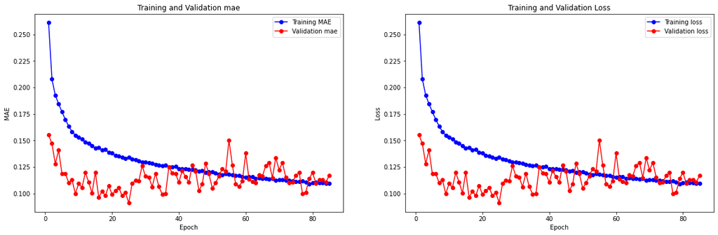

```
3780/3780 ━━━━━━━━━━━━━━━━━━━━ 2s 367us/step - loss: 0.1219 - mae: 0.1219
945/945 ━━━━━━━━━━━━━━━━━━━━ 1s 340us/step - loss: 0.0886 - mae: 0.0886
900/900 ━━━━━━━━━━━━━━━━━━━━ 0s 512us/step - loss: 0.1015 - mae: 0.1015
```

```
Training MAE: 71835.70302168245
```

```
Validation MAE: 52141.57211295588
```

```python
plot(history)
train_MAE = model.evaluate(trainData)[-1] * stdSales
val_MAE = model.evaluate(valData)[-1] * stdSales
test_MAE = model.evaluate(testData)[-1] * stdSales
print(f"Training MAE: {train_MAE}")
print(f"Validation MAE: {val_MAE}")

save_model_results(val_results_path, model_name, val_MAE)
save_model_results(test_results_path, model_name, test_MAE)
```

### **Results discussion**

Finally, we have also tested a model with bidirectional layers using sequence 4. After seeing the results, the MAE in validation seems to be a little better than in the previous bidirectional models, although the results obtained are **quite similar**.

## **Increase sequences to 13**

```python
seqLength = 13

trainData, valData, testData, stdSales, nFeatures = generateTrainTestData("./data/walmart-sales-dataset-of-45stores.csv",
    valPercent, testPercent, seqLength, batchSize)
```

## GRU

### Building the model

```python
model_name = "seq13_complex_GRU"
```

```python
inputs = Input(shape=(seqLength, nFeatures))

x = layers.GRU(units=128, return_sequences=True)(inputs)

x = layers.GRU(units=128, return_sequences=True)(x)

x = layers.GRU(units=64)(x)

x = Dense(64)(x)
x = Dense(32)(x)
x = Dense(16)(x)
outputs = Dense(1)(x)

model = Model(inputs=inputs, outputs=outputs)
model.compile(optimizer='adam', loss='mae', metrics=['mae'])
model.summary()
```

```
Model: "functional_3"
```

```
┏━━━━━━━━━━━━━━━━━━━━━━━━━━━━━━━━━┳━━━━━━━━━━━━━━━━━━━━━━━━━━━┳━━━━━━━━━━━━┓
┃ Layer (type)                    ┃ Output Shape              ┃    Param # ┃
┡━━━━━━━━━━━━━━━━━━━━━━━━━━━━━━━━━╇━━━━━━━━━━━━━━━━━━━━━━━━━━━╇━━━━━━━━━━━━┩
│ input_layer_1 (InputLayer)      │ (None, 13, 6)             │          0 │
├─────────────────────────────────┼───────────────────────────┼────────────┤
│ gru_3 (GRU)                     │ (None, 13, 128)           │     52,224 │
├─────────────────────────────────┼───────────────────────────┼────────────┤
│ gru_4 (GRU)                     │ (None, 13, 128)           │     99,072 │
├─────────────────────────────────┼───────────────────────────┼────────────┤
│ gru_5 (GRU)                     │ (None, 64)                │     37,248 │
├─────────────────────────────────┼───────────────────────────┼────────────┤
│ dense_4 (Dense)                 │ (None, 64)                │      4,160 │
├─────────────────────────────────┼───────────────────────────┼────────────┤
│ dense_5 (Dense)                 │ (None, 32)                │      2,080 │
├─────────────────────────────────┼───────────────────────────┼────────────┤
│ dense_6 (Dense)                 │ (None, 16)                │        528 │
├─────────────────────────────────┼───────────────────────────┼────────────┤
│ dense_7 (Dense)                 │ (None, 1)                 │         17 │
└─────────────────────────────────┴───────────────────────────┴────────────┘
```

```
 Total params: 195,329 (763.00 KB)
```

```
 Trainable params: 195,329 (763.00 KB)
```

```
 Non-trainable params: 0 (0.00 B)
```

### Training

```python
# Initialize the EarlyStopping callback
early_stopping = EarlyStopping(
    monitor='val_loss',
    patience=60,
    restore_best_weights=True
)

# Train the model with the EarlyStopping callback
history = model.fit(
    trainData,
    epochs=500,
    batch_size=batchSize,
    validation_data=valData,
    callbacks=[early_stopping]  # Add the EarlyStopping callback to the callbacks list
)
```

```
3132/3132 ━━━━━━━━━━━━━━━━━━━━ 9s 2ms/step - loss: 0.3211 - mae: 0.3211 - val_loss: 0.1452 - val_mae: 0.1452
3132/3132 ━━━━━━━━━━━━━━━━━━━━ 8s 2ms/step - loss: 0.2159 - mae: 0.2159 - val_loss: 0.1353 - val_mae: 0.1353
3132/3132 ━━━━━━━━━━━━━━━━━━━━ 8s 3ms/step - loss: 0.1859 - mae: 0.1859 - val_loss: 0.1134 - val_mae: 0.1134
3132/3132 ━━━━━━━━━━━━━━━━━━━━ 8s 2ms/step - loss: 0.1748 - mae: 0.1748 - val_loss: 0.1034 - val_mae: 0.1034
3132/3132 ━━━━━━━━━━━━━━━━━━━━ 8s 3ms/step - loss: 0.1610 - mae: 0.1610 - val_loss: 0.1186 - val_mae: 0.1186
3132/3132 ━━━━━━━━━━━━━━━━━━━━ 8s 2ms/step - loss: 0.1518 - mae: 0.1518 - val_loss: 0.1418 - val_mae: 0.1418
3132/3132 ━━━━━━━━━━━━━━━━━━━━ 8s 2ms/step - loss: 0.1416 - mae: 0.1416 - val_loss: 0.0947 - val_mae: 0.0947
3132/3132 ━━━━━━━━━━━━━━━━━━━━ 8s 2ms/step - loss: 0.1426 - mae: 0.1426 - val_loss: 0.1367 - val_mae: 0.1367
3132/3132 ━━━━━━━━━━━━━━━━━━━━ 9s 3ms/step - loss: 0.1344 - mae: 0.1344 - val_loss: 0.0932 - val_mae: 0.0932
3132/3132 ━━━━━━━━━━━━━━━━━━━━ 8s 3ms/step - loss: 0.1309 - mae: 0.1309 - val_loss: 0.0978 - val_mae: 0.0978
3132/3132 ━━━━━━━━━━━━━━━━━━━━ 9s 3ms/step - loss: 0.1257 - mae: 0.1257 - val_loss: 0.1397 - val_mae: 0.1397
3132/3132 ━━━━━━━━━━━━━━━━━━━━ 9s 3ms/step - loss: 0.1244 - mae: 0.1244 - val_loss: 0.0927 - val_mae: 0.0927
3132/3132 ━━━━━━━━━━━━━━━━━━━━ 8s 3ms/step - loss: 0.1166 - mae: 0.1166 - val_loss: 0.0864 - val_mae: 0.0864
3132/3132 ━━━━━━━━━━━━━━━━━━━━ 8s 3ms/step - loss: 0.1227 - mae: 0.1227 - val_loss: 0.0843 - val_mae: 0.0843
3132/3132 ━━━━━━━━━━━━━━━━━━━━ 8s 3ms/step - loss: 0.1148 - mae: 0.1148 - val_loss: 0.0928 - val_mae: 0.0928
3132/3132 ━━━━━━━━━━━━━━━━━━━━ 8s 3ms/step - loss: 0.1103 - mae: 0.1103 - val_loss: 0.0974 - val_mae: 0.0974
3132/3132 ━━━━━━━━━━━━━━━━━━━━ 8s 2ms/step - loss: 0.1095 - mae: 0.1095 - val_loss: 0.0956 - val_mae: 0.0956
3132/3132 ━━━━━━━━━━━━━━━━━━━━ 8s 3ms/step - loss: 0.1056 - mae: 0.1056 - val_loss: 0.1053 - val_mae: 0.1053
3132/3132 ━━━━━━━━━━━━━━━━━━━━ 8s 3ms/step - loss: 0.1046 - mae: 0.1046 - val_loss: 0.0899 - val_mae: 0.0899
3132/3132 ━━━━━━━━━━━━━━━━━━━━ 8s 2ms/step - loss: 0.1032 - mae: 0.1032 - val_loss: 0.1011 - val_mae: 0.1011
3132/3132 ━━━━━━━━━━━━━━━━━━━━ 8s 3ms/step - loss: 0.1008 - mae: 0.1008 - val_loss: 0.0867 - val_mae: 0.0867
3132/3132 ━━━━━━━━━━━━━━━━━━━━ 9s 3ms/step - loss: 0.1025 - mae: 0.1025 - val_loss: 0.0872 - val_mae: 0.0872
3132/3132 ━━━━━━━━━━━━━━━━━━━━ 8s 3ms/step - loss: 0.0984 - mae: 0.0984 - val_loss: 0.0903 - val_mae: 0.0903
3132/3132 ━━━━━━━━━━━━━━━━━━━━ 8s 3ms/step - loss: 0.0953 - mae: 0.0953 - val_loss: 0.0996 - val_mae: 0.0996
3132/3132 ━━━━━━━━━━━━━━━━━━━━ 8s 3ms/step - loss: 0.0975 - mae: 0.0975 - val_loss: 0.0949 - val_mae: 0.0949
3132/3132 ━━━━━━━━━━━━━━━━━━━━ 9s 3ms/step - loss: 0.1000 - mae: 0.1000 - val_loss: 0.0904 - val_mae: 0.0904
3132/3132 ━━━━━━━━━━━━━━━━━━━━ 9s 3ms/step - loss: 0.0888 - mae: 0.0888 - val_loss: 0.0866 - val_mae: 0.0866
3132/3132 ━━━━━━━━━━━━━━━━━━━━ 8s 3ms/step - loss: 0.0881 - mae: 0.0881 - val_loss: 0.0970 - val_mae: 0.0970
3132/3132 ━━━━━━━━━━━━━━━━━━━━ 8s 3ms/step - loss: 0.0907 - mae: 0.0907 - val_loss: 0.0961 - val_mae: 0.0961
3132/3132 ━━━━━━━━━━━━━━━━━━━━ 9s 3ms/step - loss: 0.0908 - mae: 0.0908 - val_loss: 0.1200 - val_mae: 0.1200
3132/3132 ━━━━━━━━━━━━━━━━━━━━ 8s 2ms/step - loss: 0.0876 - mae: 0.0876 - val_loss: 0.0951 - val_mae: 0.0951
3132/3132 ━━━━━━━━━━━━━━━━━━━━ 8s 2ms/step - loss: 0.0851 - mae: 0.0851 - val_loss: 0.0877 - val_mae: 0.0877
3132/3132 ━━━━━━━━━━━━━━━━━━━━ 8s 3ms/step - loss: 0.0851 - mae: 0.0851 - val_loss: 0.0874 - val_mae: 0.0874
3132/3132 ━━━━━━━━━━━━━━━━━━━━ 8s 3ms/step - loss: 0.0847 - mae: 0.0847 - val_loss: 0.0932 - val_mae: 0.0932
3132/3132 ━━━━━━━━━━━━━━━━━━━━ 8s 3ms/step - loss: 0.0830 - mae: 0.0830 - val_loss: 0.1014 - val_mae: 0.1014
3132/3132 ━━━━━━━━━━━━━━━━━━━━ 8s 3ms/step - loss: 0.0833 - mae: 0.0833 - val_loss: 0.0898 - val_mae: 0.0898
3132/3132 ━━━━━━━━━━━━━━━━━━━━ 8s 3ms/step - loss: 0.0801 - mae: 0.0801 - val_loss: 0.0962 - val_mae: 0.0962
3132/3132 ━━━━━━━━━━━━━━━━━━━━ 8s 3ms/step - loss: 0.0804 - mae: 0.0804 - val_loss: 0.0917 - val_mae: 0.0917
3132/3132 ━━━━━━━━━━━━━━━━━━━━ 8s 3ms/step - loss: 0.0765 - mae: 0.0765 - val_loss: 0.0928 - val_mae: 0.0928
3132/3132 ━━━━━━━━━━━━━━━━━━━━ 8s 3ms/step - loss: 0.0755 - mae: 0.0755 - val_loss: 0.1009 - val_mae: 0.1009
```

[output cut: 49 more lines]

```
3132/3132 ━━━━━━━━━━━━━━━━━━━━ 8s 3ms/step - loss: 0.0536 - mae: 0.0536 - val_loss: 0.1065 - val_mae: 0.1065
3132/3132 ━━━━━━━━━━━━━━━━━━━━ 8s 3ms/step - loss: 0.0553 - mae: 0.0553 - val_loss: 0.1012 - val_mae: 0.1012
3132/3132 ━━━━━━━━━━━━━━━━━━━━ 8s 3ms/step - loss: 0.0537 - mae: 0.0537 - val_loss: 0.1030 - val_mae: 0.1030
3132/3132 ━━━━━━━━━━━━━━━━━━━━ 8s 3ms/step - loss: 0.0544 - mae: 0.0544 - val_loss: 0.0948 - val_mae: 0.0948
3132/3132 ━━━━━━━━━━━━━━━━━━━━ 8s 3ms/step - loss: 0.0514 - mae: 0.0514 - val_loss: 0.1050 - val_mae: 0.1050
3132/3132 ━━━━━━━━━━━━━━━━━━━━ 8s 3ms/step - loss: 0.0537 - mae: 0.0537 - val_loss: 0.0957 - val_mae: 0.0957
3132/3132 ━━━━━━━━━━━━━━━━━━━━ 8s 3ms/step - loss: 0.0519 - mae: 0.0519 - val_loss: 0.1110 - val_mae: 0.1110
3132/3132 ━━━━━━━━━━━━━━━━━━━━ 8s 3ms/step - loss: 0.0549 - mae: 0.0549 - val_loss: 0.1000 - val_mae: 0.1000
3132/3132 ━━━━━━━━━━━━━━━━━━━━ 9s 3ms/step - loss: 0.0545 - mae: 0.0545 - val_loss: 0.1008 - val_mae: 0.1008
3132/3132 ━━━━━━━━━━━━━━━━━━━━ 8s 3ms/step - loss: 0.0551 - mae: 0.0551 - val_loss: 0.1025 - val_mae: 0.1025
3132/3132 ━━━━━━━━━━━━━━━━━━━━ 8s 3ms/step - loss: 0.0524 - mae: 0.0524 - val_loss: 0.0913 - val_mae: 0.0913
3132/3132 ━━━━━━━━━━━━━━━━━━━━ 8s 3ms/step - loss: 0.0528 - mae: 0.0528 - val_loss: 0.1014 - val_mae: 0.1014
3132/3132 ━━━━━━━━━━━━━━━━━━━━ 8s 2ms/step - loss: 0.0526 - mae: 0.0526 - val_loss: 0.1157 - val_mae: 0.1157
3132/3132 ━━━━━━━━━━━━━━━━━━━━ 8s 3ms/step - loss: 0.0528 - mae: 0.0528 - val_loss: 0.1036 - val_mae: 0.1036
3132/3132 ━━━━━━━━━━━━━━━━━━━━ 8s 3ms/step - loss: 0.0547 - mae: 0.0547 - val_loss: 0.1082 - val_mae: 0.1082
```

### Evaluation

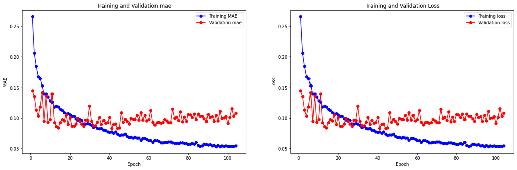

```
3132/3132 ━━━━━━━━━━━━━━━━━━━━ 3s 709us/step - loss: 0.0694 - mae: 0.0694
783/783 ━━━━━━━━━━━━━━━━━━━━ 1s 741us/step - loss: 0.0849 - mae: 0.0849
90/90 ━━━━━━━━━━━━━━━━━━━━ 0s 5ms/step - loss: 0.0941 - mae: 0.0941
```

```
Training MAE: 40534.4363511364
```

```
Validation MAE: 47489.38101953637
```

```python
plot(history)
train_MAE = model.evaluate(trainData)[-1] * stdSales
val_MAE = model.evaluate(valData)[-1] * stdSales
test_MAE = model.evaluate(testData)[-1] * stdSales
print(f"Training MAE: {train_MAE}")
print(f"Validation MAE: {val_MAE}")

save_model_results(val_results_path, model_name, val_MAE)
save_model_results(test_results_path, model_name, test_MAE)
```